# Selection on within-individual variation in flowering time in Lathyrus vernus

##### Plot predictions

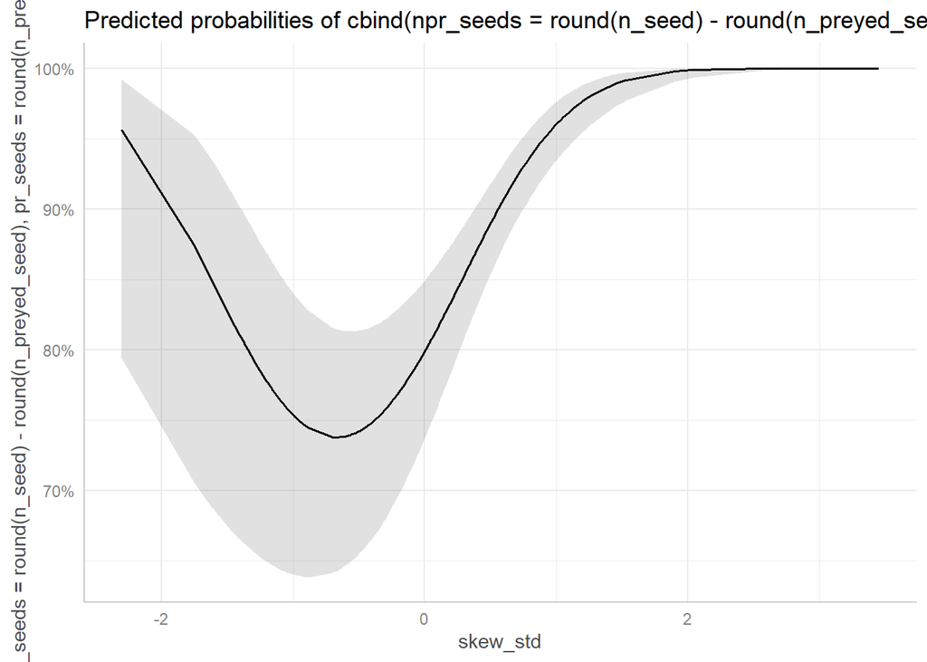

```r
plot(ggpredict(seed_escpred_nonlinear_87,terms=c("skew_std [all]")))
```

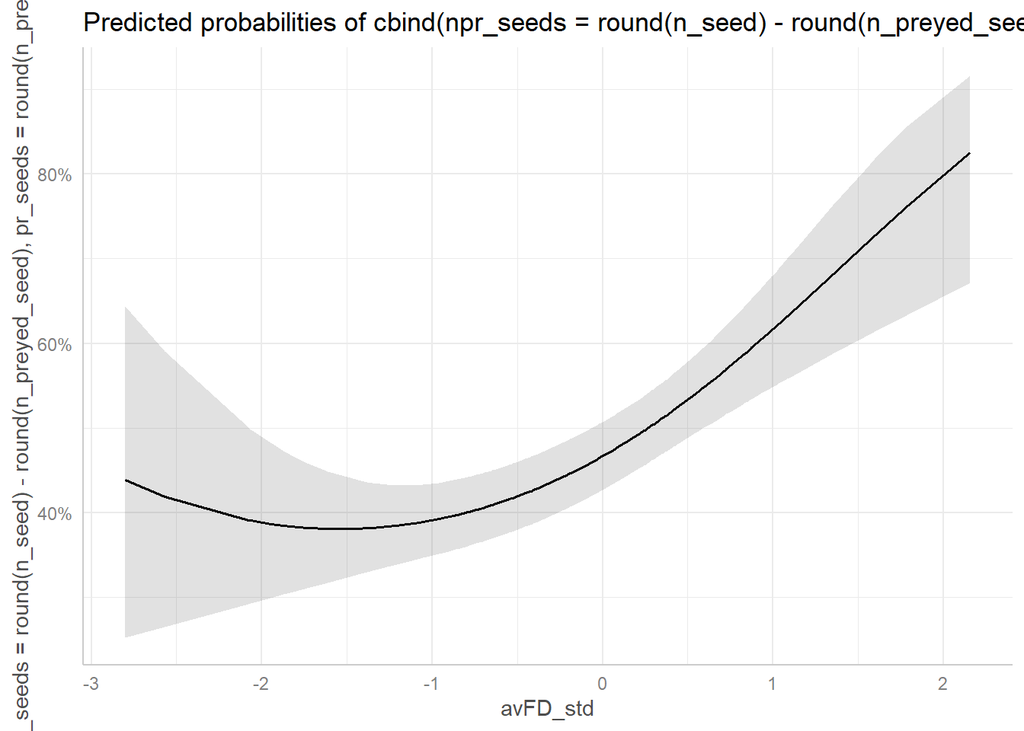

```r
plot(ggpredict(seed_escpred_nonlinear_88,terms=c("avFD_std [all]")))
```

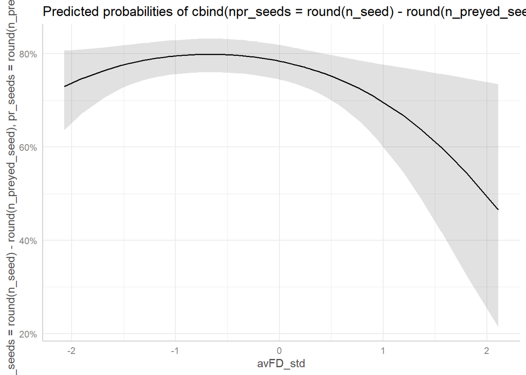

```r
plot(ggpredict(seed_escpred_nonlinear_89,terms=c("avFD_std [all]")))
```

## PHENOTYPIC SELECTION with n_fl

Try with n_fl –> log –> std

```r
data_ids<-data_ids%>%
  mutate(n_fl_log=log(n_fl))%>%
  group_by(year)%>%
  mutate(n_fl_log_std=as.vector(scale(n_fl_log)))
```

Using (within-year) standardized traits.

### Global models

#### Linear effects

Including only linear effects and interactions with year.

```r
sel_nfl_linear<-lm(fitness_rel~avFD_std+var_std+skew_std+kurt_std+n_fl_log_std+
              avFD_std:year+var_std:year+skew_std:year+kurt_std:year,
              # Not including main effect of yr cause fitness rel within yrs
              subset(data_ids,!is.na(avFD_std)&!is.na(var_std)&
                       !is.na(skew_std)&!is.na(kurt_std)))
tab_model(sel_nfl_linear,
          transform=NULL,show.ci=F,show.se=T,show.stat=T,digits=3,
          dv.labels=c("Selection, linear effects"))
```

|  | Selection, linear effects |  |  |  |
| --- | --- | --- | --- | --- |
| Predictors | Estimates | std. Error | Statistic | p |
| (Intercept) | 0.960 | 0.066 | 14.590 | **<0.001** |
| avFD std | -0.086 | 0.109 | -0.790 | 0.430 |
| var std | 0.310 | 0.101 | 3.078 | **0.002** |
| skew std | 0.215 | 0.136 | 1.577 | 0.115 |
| kurt std | -0.021 | 0.133 | -0.157 | 0.875 |
| n fl log std | 0.562 | 0.094 | 5.990 | **<0.001** |
| avFD std × year1988 | 0.085 | 0.166 | 0.511 | 0.609 |
| avFD std × year1989 | -0.132 | 0.206 | -0.641 | 0.522 |
| var std × year1988 | -0.348 | 0.148 | -2.352 | **0.019** |
| var std × year1989 | -0.240 | 0.190 | -1.262 | 0.208 |
| skew std × year1988 | -0.127 | 0.178 | -0.712 | 0.477 |
| skew std × year1989 | 0.127 | 0.205 | 0.621 | 0.535 |
| kurt std × year1988 | 0.096 | 0.170 | 0.565 | 0.572 |
| kurt std × year1989 | 0.167 | 0.196 | 0.851 | 0.395 |
| Observations | 428 |  |  |  |
| R<sup>2</sup> / R<sup>2</sup> adjusted | 0.229 / 0.205 |  |  |  |

```r
Anova(sel_nfl_linear)
```

|  | Sum Sq | Df | F value | Pr(>F) |
| --- | --- | --- | --- | --- |
| avFD_std | 1.902072 | 1 | 1.1261049 | 2.892264e-01 |
| var_std | 6.983500 | 1 | 4.1345192 | 4.265434e-02 |
| skew_std | 10.602742 | 1 | 6.2772599 | 1.261272e-02 |
| kurt_std | 1.096173 | 1 | 0.6489794 | 4.209402e-01 |
| n_fl_log_std | 60.606460 | 1 | 35.8815190 | 4.557583e-09 |
| avFD_std:year | 1.716528 | 2 | 0.5081277 | 6.019956e-01 |
| var_std:year | 9.843681 | 2 | 2.9139323 | 5.537577e-02 |
| skew_std:year | 3.062109 | 2 | 0.9064474 | 4.047570e-01 |
| kurt_std:year | 1.268921 | 2 | 0.3756267 | 6.870925e-01 |
| Residuals | 699.275705 | 414 | NA | NA |

```r
check_collinearity(lm(fitness_rel~avFD_std+var_std+skew_std+kurt_std+n_fl_std,
              subset(data_ids,!is.na(avFD_std)&!is.na(var_std)&
                       !is.na(skew_std)&!is.na(kurt_std))))
```

| Term | VIF | VIF_CI_low | VIF_CI_high | SE_factor | Tolerance | Tolerance_CI_low | Tolerance_CI_high |
| --- | --- | --- | --- | --- | --- | --- | --- |
| avFD_std | 1.105781 | 1.036516 | 1.306431 | 1.051561 | 0.9043385 | 0.7654444 | 0.9647707 |
| var_std | 1.265524 | 1.155436 | 1.453581 | 1.124955 | 0.7901866 | 0.6879563 | 0.8654740 |
| skew_std | 1.161927 | 1.075786 | 1.345976 | 1.077927 | 0.8606394 | 0.7429554 | 0.9295525 |
| kurt_std | 1.146557 | 1.064589 | 1.332548 | 1.070774 | 0.8721764 | 0.7504423 | 0.9393295 |
| n_fl_std | 1.324573 | 1.202486 | 1.520272 | 1.150901 | 0.7549601 | 0.6577769 | 0.8316105 |

According to Anova, no differences among years.

##### Plot predictions

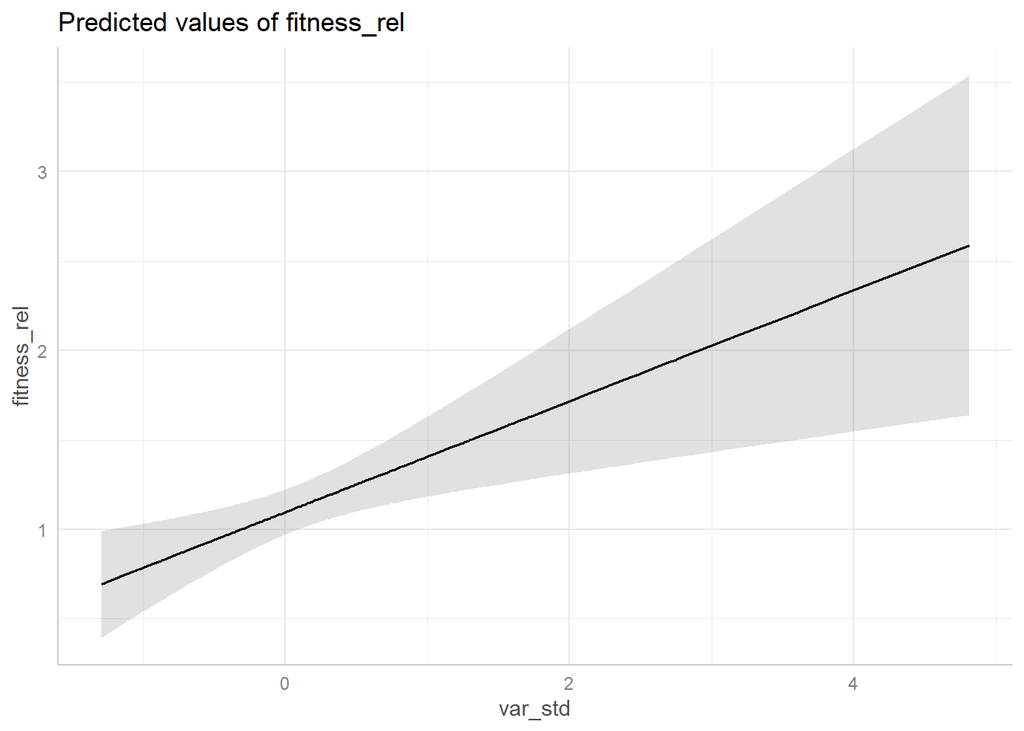

```r
plot(ggpredict(sel_nfl_linear,terms=c("var_std [all]")))
```

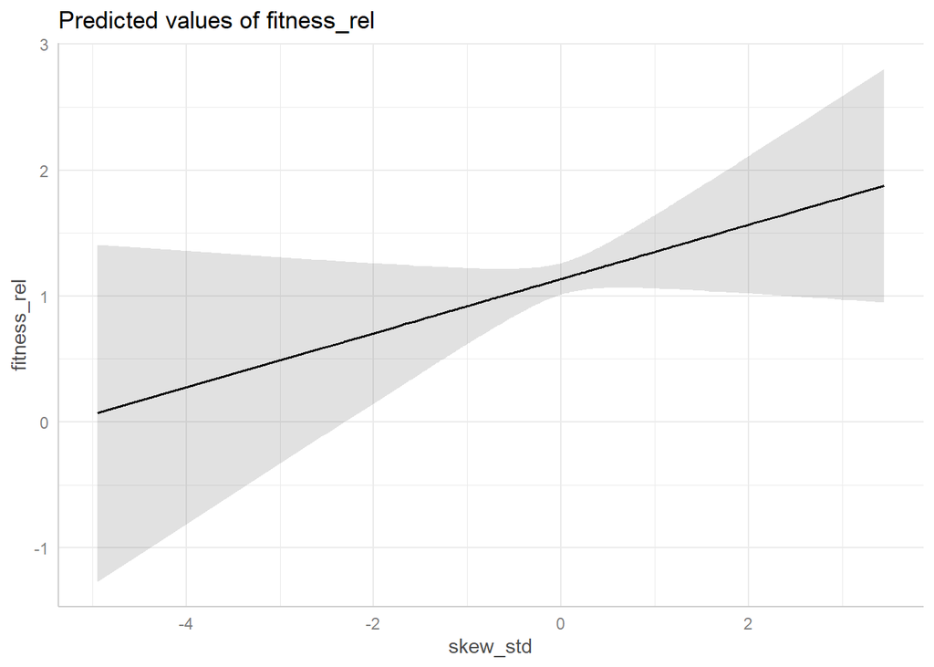

```r
plot(ggpredict(sel_nfl_linear,terms=c("skew_std [all]")))
```

##### BCA intervals

```r
BCIs_sel_nfl_linear
```

[output not shown]

Similar to significances with Anova

#### Non-linear effects

```r
sel_nfl_nonlinear<-lm(fitness_rel~avFD_std+var_std+skew_std+kurt_std+
                        n_fl_log_std+
                        avFD_std:year+var_std:year+skew_std:year+kurt_std:year+
                        I(avFD_std^2)+I(var_std^2)+I(skew_std^2)+I(kurt_std^2)+
                        I(n_fl_log_std^2)+
                        I(avFD_std^2):year+I(var_std^2):year+
                        I(skew_std^2):year+I(kurt_std^2):year,
                      subset(data_ids,!is.na(avFD_std)&!is.na(var_std)&
                               !is.na(skew_std)&!is.na(kurt_std)))
tab_model(sel_nfl_nonlinear,
          transform=NULL,show.ci=F,show.se=T,show.stat=T,digits=3,
          dv.labels=c("Selection, non-linear effects"))
```

|  | Selection, non-linear effects |  |  |  |
| --- | --- | --- | --- | --- |
| Predictors | Estimates | std. Error | Statistic | p |
| (Intercept) | 0.737 | 0.123 | 5.968 | **<0.001** |
| avFD std | -0.047 | 0.129 | -0.362 | 0.718 |
| var std | 0.138 | 0.172 | 0.802 | 0.423 |
| skew std | 0.241 | 0.164 | 1.467 | 0.143 |
| kurt std | -0.179 | 0.246 | -0.727 | 0.468 |
| n fl log std | 0.542 | 0.146 | 3.714 | **<0.001** |
| avFD std^2 | -0.030 | 0.064 | -0.469 | 0.639 |
| var std^2 | 0.080 | 0.060 | 1.331 | 0.184 |
| skew std^2 | 0.080 | 0.123 | 0.647 | 0.518 |
| kurt std^2 | 0.019 | 0.061 | 0.308 | 0.759 |
| n fl log std^2 | 0.143 | 0.083 | 1.731 | 0.084 |
| avFD std × year 1988 | 0.107 | 0.188 | 0.567 | 0.571 |
| avFD std × year 1989 | -0.171 | 0.226 | -0.757 | 0.450 |
| var std × year 1988 | -0.216 | 0.250 | -0.865 | 0.387 |
| var std × year 1989 | -0.018 | 0.286 | -0.062 | 0.950 |
| skew std × year 1988 | -0.164 | 0.205 | -0.798 | 0.426 |
| skew std × year 1989 | 0.083 | 0.244 | 0.338 | 0.735 |
| kurt std × year 1988 | 0.252 | 0.273 | 0.922 | 0.357 |
| kurt std × year 1989 | 0.401 | 0.353 | 1.136 | 0.257 |
| year 1988 × avFD std^2 | 0.147 | 0.113 | 1.308 | 0.192 |
| year 1989 × avFD std^2 | 0.156 | 0.135 | 1.152 | 0.250 |
| year 1988 × var std^2 | -0.047 | 0.102 | -0.459 | 0.647 |
| year 1989 × var std^2 | -0.130 | 0.125 | -1.038 | 0.300 |
| year 1988 × skew std^2 | -0.030 | 0.156 | -0.195 | 0.845 |
| year 1989 × skew std^2 | -0.013 | 0.197 | -0.066 | 0.947 |
| year 1988 × kurt std^2 | -0.042 | 0.078 | -0.543 | 0.587 |
| year 1989 × kurt std^2 | -0.072 | 0.098 | -0.732 | 0.465 |
| Observations | 428 |  |  |  |
| R<sup>2</sup> / R<sup>2</sup> adjusted | 0.251 / 0.202 |  |  |  |

```r
Anova(sel_nfl_nonlinear)
```

|  | Sum Sq | Df | F value | Pr(>F) |
| --- | --- | --- | --- | --- |
| avFD_std | 0.41049511 | 1 | 0.24215616 | 0.6229224230 |
| var_std | 0.47879717 | 1 | 0.28244839 | 0.5953951905 |
| skew_std | 6.22747639 | 1 | 3.67366566 | 0.0559889292 |
| kurt_std | 0.04463343 | 1 | 0.02632981 | 0.8711791888 |
| n_fl_log_std | 23.37675015 | 1 | 13.79023522 | 0.0002333375 |
| I(avFD_std^2) | 0.53509777 | 1 | 0.31566082 | 0.5745409614 |
| I(var_std^2) | 1.73677384 | 1 | 1.02454446 | 0.3120538199 |
| I(skew_std^2) | 0.88917379 | 1 | 0.52453466 | 0.4693360355 |
| I(kurt_std^2) | 0.35968080 | 1 | 0.21218017 | 0.6453136475 |
| I(n_fl_log_std^2) | 5.07738546 | 1 | 2.99521274 | 0.0842802225 |

[output cut: 9 more lines]

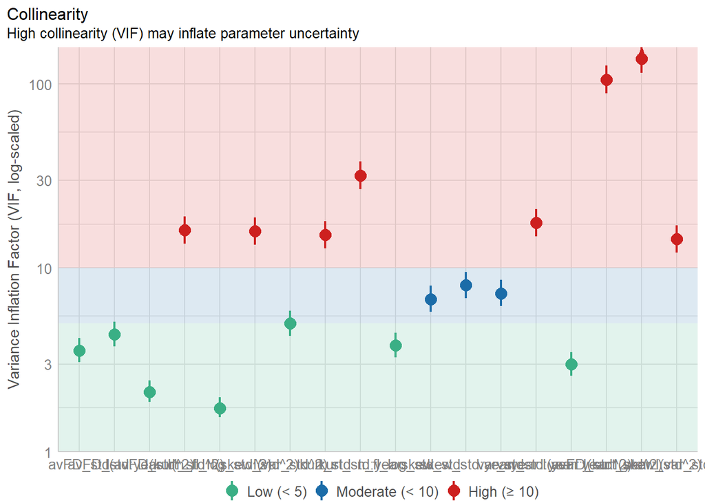

```r
plot(check_collinearity(sel_nfl_nonlinear))
```

##### BCA intervals

Only for non-linear terms

```r
BCIs_sel_nfl_nonlinear
```

```
##                          lower      upper
## avFD_std2          -0.15022626 0.08238815
## var_std2           -0.12058404 0.24538795
## skew_std2          -0.15176263 0.42493807
## kurt_std2          -0.12671056 0.12170209
## n_fl_log_std2      -0.05018926 0.39077525
## avFD_std2_year1988 -0.05532547 0.48179325
## avFD_std2_year1989 -0.02335357 0.39770523
## var_std2_year1988  -0.31385870 0.18089859
## var_std2_year1989  -0.38666990 0.12954407
## skew_std2_year1988 -0.41021921 0.27150814
## skew_std2_year1989 -0.38383877 0.38847111
## kurt_std2_year1988 -0.26777843 0.25708924
## kurt_std2_year1989 -0.29511147 0.25815973
```

### Yearly models

#### Linear effects

```r
sel_nfl_linear_87<-lm(fitness_rel~avFD_std+var_std+skew_std+kurt_std+
                        n_fl_log_std,
                      subset(data_ids,year==1987&
                               !is.na(avFD_std)&!is.na(var_std)&
                               !is.na(skew_std)&!is.na(kurt_std)))
sel_nfl_linear_88<-lm(fitness_rel~avFD_std+var_std+skew_std+kurt_std+
                        n_fl_log_std,
                      subset(data_ids,year==1988&
                               !is.na(avFD_std)&!is.na(var_std)&
                               !is.na(skew_std)&!is.na(kurt_std)))
sel_nfl_linear_89<-lm(fitness_rel~avFD_std+var_std+skew_std+kurt_std+
                        n_fl_log_std,
                      subset(data_ids,year==1989&
                               !is.na(avFD_std)&!is.na(var_std)&
                               !is.na(skew_std)&!is.na(kurt_std)))
tab_model(sel_nfl_linear_87,sel_nfl_linear_88,sel_nfl_linear_89,
          transform=NULL,show.ci=F,show.se=T,show.stat=T,digits=3,
          dv.labels=c("1987","1988","1989"),
          title="Selection, linear effects")
```

Selection, linear effects

|  | 1987 |  |  |  | 1988 |  |  |  | 1989 |  |  |  |
| --- | --- | --- | --- | --- | --- | --- | --- | --- | --- | --- | --- | --- |
| Predictors | Estimates | std. Error | Statistic | p | Estimates | std. Error | Statistic | p | Estimates | std. Error | Statistic | p |
| (Intercept) | 0.958 | 0.099 | 9.628 | **<0.001** | 1.004 | 0.120 | 8.341 | **<0.001** | 0.917 | 0.122 | 7.494 | **<0.001** |
| avFD std | -0.121 | 0.114 | -1.058 | 0.291 | 0.005 | 0.133 | 0.036 | 0.971 | -0.192 | 0.153 | -1.251 | 0.215 |
| var std | 0.373 | 0.111 | 3.347 | **0.001** | -0.058 | 0.136 | -0.426 | 0.671 | -0.036 | 0.158 | -0.229 | 0.819 |
| skew std | 0.197 | 0.140 | 1.406 | 0.161 | 0.092 | 0.120 | 0.762 | 0.447 | 0.344 | 0.131 | 2.622 | **0.010** |
| kurt std | 0.037 | 0.142 | 0.264 | 0.792 | 0.066 | 0.126 | 0.524 | 0.601 | 0.089 | 0.133 | 0.673 | 0.503 |
| n fl log std | 0.400 | 0.150 | 2.670 | **0.008** | 0.591 | 0.159 | 3.727 | **<0.001** | 0.832 | 0.178 | 4.661 | **<0.001** |
| Observations | 198 |  |  |  | 142 |  |  |  | 88 |  |  |  |
| R<sup>2</sup> / R<sup>2</sup> adjusted | 0.246 / 0.226 |  |  |  | 0.132 / 0.100 |  |  |  | 0.387 / 0.350 |  |  |  |

```r
check_collinearity(sel_nfl_linear_87)
```

| Term | VIF | VIF_CI_low | VIF_CI_high | SE_factor | Tolerance | Tolerance_CI_low | Tolerance_CI_high |
| --- | --- | --- | --- | --- | --- | --- | --- |
| avFD_std | 1.321302 | 1.162488 | 1.635340 | 1.149479 | 0.7568291 | 0.6114936 | 0.8602239 |
| var_std | 1.363413 | 1.192839 | 1.684865 | 1.167653 | 0.7334536 | 0.5935193 | 0.8383361 |
| skew_std | 2.186100 | 1.811814 | 2.732949 | 1.478546 | 0.4574357 | 0.3659051 | 0.5519330 |
| kurt_std | 2.240210 | 1.853024 | 2.803140 | 1.496733 | 0.4463867 | 0.3567428 | 0.5396584 |
| n_fl_log_std | 1.733224 | 1.468180 | 2.148316 | 1.316520 | 0.5769593 | 0.4654809 | 0.6811156 |

```r
check_collinearity(sel_nfl_linear_88)
```

| Term | VIF | VIF_CI_low | VIF_CI_high | SE_factor | Tolerance | Tolerance_CI_low | Tolerance_CI_high |
| --- | --- | --- | --- | --- | --- | --- | --- |
| avFD_std | 1.066185 | 1.004687 | 1.934526 | 1.032562 | 0.9379238 | 0.5169226 | 0.9953345 |
| var_std | 1.351542 | 1.166109 | 1.743981 | 1.162559 | 0.7398955 | 0.5734008 | 0.8575527 |
| skew_std | 1.101070 | 1.016043 | 1.636754 | 1.049319 | 0.9082071 | 0.6109652 | 0.9842106 |
| kurt_std | 1.199605 | 1.067463 | 1.590574 | 1.095265 | 0.8336080 | 0.6287038 | 0.9368005 |
| n_fl_log_std | 1.416152 | 1.210547 | 1.822537 | 1.190022 | 0.7061390 | 0.5486858 | 0.8260732 |

```r
check_collinearity(sel_nfl_linear_89)
```

| Term | VIF | VIF_CI_low | VIF_CI_high | SE_factor | Tolerance | Tolerance_CI_low | Tolerance_CI_high |
| --- | --- | --- | --- | --- | --- | --- | --- |
| avFD_std | 1.327606 | 1.125996 | 1.851820 | 1.152218 | 0.7532353 | 0.5400092 | 0.8881026 |
| var_std | 1.711474 | 1.373626 | 2.354820 | 1.308233 | 0.5842916 | 0.4246610 | 0.7280003 |
| skew_std | 1.203875 | 1.055234 | 1.752526 | 1.097212 | 0.8306511 | 0.5706050 | 0.9476571 |
| kurt_std | 1.228628 | 1.068484 | 1.763252 | 1.108435 | 0.8139162 | 0.5671341 | 0.9359053 |
| n_fl_log_std | 1.555981 | 1.271050 | 2.140432 | 1.247390 | 0.6426815 | 0.4671953 | 0.7867510 |

```r
Anova(sel_nfl_linear_87)
```

|  | Sum Sq | Df | F value | Pr(>F) |
| --- | --- | --- | --- | --- |
| avFD_std | 1.9768566 | 1 | 1.11973904 | 0.291304144 |
| var_std | 19.7797721 | 1 | 11.20373782 | 0.000982185 |
| skew_std | 3.4917964 | 1 | 1.97783730 | 0.161234840 |
| kurt_std | 0.1226711 | 1 | 0.06948384 | 0.792372488 |
| n_fl_log_std | 12.5879198 | 1 | 7.13010002 | 0.008229927 |
| Residuals | 338.9686822 | 192 | NA | NA |

```r
Anova(sel_nfl_linear_88)
```

|  | Sum Sq | Df | F value | Pr(>F) |
| --- | --- | --- | --- | --- |
| avFD_std | 2.450145e-03 | 1 | 0.001317967 | 0.971093345 |
| var_std | 3.368200e-01 | 1 | 0.181180115 | 0.671033849 |
| skew_std | 1.080297e+00 | 1 | 0.581106687 | 0.447198928 |
| kurt_std | 5.112024e-01 | 1 | 0.274982832 | 0.600862309 |
| n_fl_log_std | 2.581714e+01 | 1 | 13.887395096 | 0.000283698 |
| Residuals | 2.528286e+02 | 136 | NA | NA |

```r
Anova(sel_nfl_linear_89)
```

|  | Sum Sq | Df | F value | Pr(>F) |
| --- | --- | --- | --- | --- |
| avFD_std | 1.94513144 | 1 | 1.56429826 | 2.145940e-01 |
| var_std | 0.06532458 | 1 | 0.05253482 | 8.192805e-01 |
| skew_std | 8.55024549 | 1 | 6.87621097 | 1.041088e-02 |
| kurt_std | 0.56349191 | 1 | 0.45316702 | 5.027277e-01 |
| n_fl_log_std | 27.01267162 | 1 | 21.72391765 | 1.204419e-05 |
| Residuals | 101.96314995 | 82 | NA | NA |

##### Plot predictions

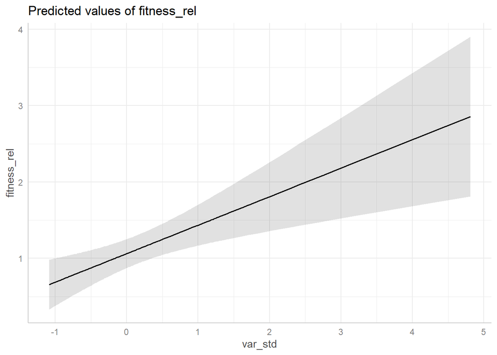

```r
plot(ggpredict(sel_nfl_linear_87,terms=c("var_std [all]")))
```

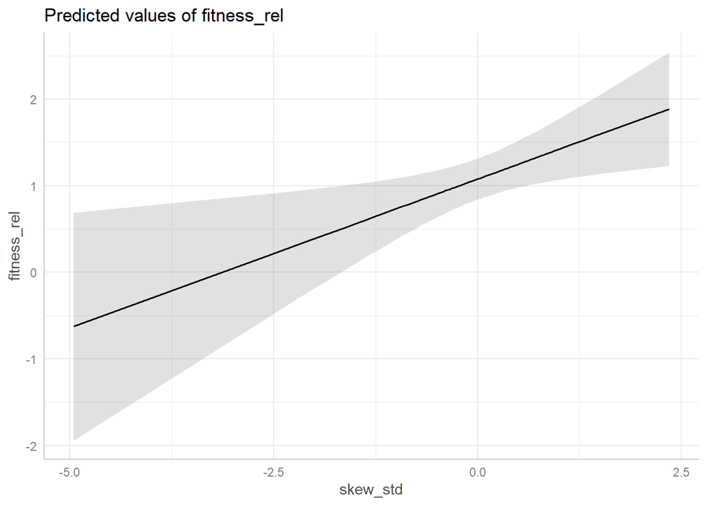

```r
plot(ggpredict(sel_nfl_linear_89,terms=c("skew_std [all]")))
```

##### BCA intervals

###### 1987

```r
BCIs_sel_nfl_linear_87
```

```
##                    lower      upper
## avFD_std     -0.28405841 0.03147433
## var_std       0.09305936 0.72535499
## skew_std      0.02247429 0.38109803
## kurt_std     -0.26218905 0.37462572
## n_fl_log_std  0.12570182 0.77221722
```

###### 1988

```r
BCIs_sel_nfl_linear_88
```

```
##                   lower     upper
## avFD_std     -0.2392192 0.3806973
## var_std      -0.3140914 0.1449419
## skew_std     -0.1309198 0.3462063
## kurt_std     -0.1928324 0.2948467
## n_fl_log_std  0.2175608 1.0471706
```

###### 1989

```r
BCIs_sel_nfl_linear_89
```

```
##                   lower     upper
## avFD_std     -0.4727572 0.1653955
## var_std      -0.3500722 0.3067245
## skew_std      0.1545784 0.5935985
## kurt_std     -0.1393307 0.3418374
## n_fl_log_std  0.5199329 1.3709568
```

#### Non-linear effects

```r
sel_nfl_nonlinear_87<-lm(fitness_rel~avFD_std+var_std+
                           skew_std+kurt_std+n_fl_log_std+
                           I(avFD_std^2)+I(var_std^2)+
                           I(skew_std^2)+I(kurt_std^2)+I(n_fl_log_std^2),
                         subset(data_ids,year==1987&
                                  !is.na(avFD_std)&!is.na(var_std)&
                                  !is.na(skew_std)&!is.na(kurt_std)))
sel_nfl_nonlinear_88<-lm(fitness_rel~avFD_std+var_std+
                           skew_std+kurt_std+n_fl_log_std+
                           I(avFD_std^2)+I(var_std^2)+
                           I(skew_std^2)+I(kurt_std^2)+I(n_fl_log_std^2),
                         subset(data_ids,year==1988&
                                  !is.na(avFD_std)&!is.na(var_std)&
                                  !is.na(skew_std)&!is.na(kurt_std)))
sel_nfl_nonlinear_89<-lm(fitness_rel~avFD_std+var_std+
                           skew_std+kurt_std+n_fl_log_std+
                           I(avFD_std^2)+I(var_std^2)+
                           I(skew_std^2)+I(kurt_std^2)+I(n_fl_log_std^2),
                           subset(data_ids,year==1989&
                                    !is.na(avFD_std)&!is.na(var_std)&
                                    !is.na(skew_std)&!is.na(kurt_std)))
tab_model(sel_nfl_nonlinear_87,sel_nfl_nonlinear_88,sel_nfl_nonlinear_89,
          transform=NULL,show.ci=F,show.se=T,show.stat=T,digits=3,
          dv.labels=c("1987","1988","1989"),
          title="Selection, non-linear effects")
```

Selection, non-linear effects

|  | 1987 |  |  |  | 1988 |  |  |  | 1989 |  |  |  |
| --- | --- | --- | --- | --- | --- | --- | --- | --- | --- | --- | --- | --- |
| Predictors | Estimates | std. Error | Statistic | p | Estimates | std. Error | Statistic | p | Estimates | std. Error | Statistic | p |
| (Intercept) | 0.749 | 0.181 | 4.132 | **<0.001** | 0.779 | 0.229 | 3.398 | **0.001** | 0.577 | 0.236 | 2.448 | **0.017** |
| avFD std | -0.093 | 0.139 | -0.672 | 0.502 | 0.046 | 0.147 | 0.314 | 0.754 | -0.259 | 0.159 | -1.631 | 0.107 |
| var std | 0.190 | 0.186 | 1.025 | 0.307 | -0.025 | 0.239 | -0.107 | 0.915 | 0.072 | 0.229 | 0.316 | 0.753 |
| skew std | 0.242 | 0.172 | 1.405 | 0.162 | 0.074 | 0.135 | 0.549 | 0.584 | 0.307 | 0.184 | 1.668 | 0.099 |
| kurt std | -0.222 | 0.286 | -0.776 | 0.438 | 0.178 | 0.247 | 0.722 | 0.472 | 0.241 | 0.337 | 0.716 | 0.476 |
| n fl log std | 0.587 | 0.214 | 2.749 | **0.007** | 0.369 | 0.284 | 1.302 | 0.195 | 0.596 | 0.266 | 2.237 | **0.028** |
| avFD std^2 | -0.007 | 0.070 | -0.102 | 0.919 | 0.093 | 0.112 | 0.836 | 0.405 | 0.083 | 0.112 | 0.745 | 0.459 |
| var std^2 | 0.083 | 0.062 | 1.342 | 0.181 | 0.018 | 0.095 | 0.186 | 0.853 | -0.055 | 0.095 | -0.580 | 0.564 |
| skew std^2 | 0.102 | 0.141 | 0.723 | 0.470 | 0.001 | 0.146 | 0.006 | 0.995 | 0.056 | 0.184 | 0.303 | 0.763 |
| kurt std^2 | 0.022 | 0.063 | 0.344 | 0.731 | -0.019 | 0.052 | -0.364 | 0.716 | -0.049 | 0.067 | -0.738 | 0.463 |
| n fl log std^2 | -0.015 | 0.119 | -0.125 | 0.901 | 0.257 | 0.155 | 1.661 | 0.099 | 0.479 | 0.172 | 2.789 | **0.007** |
| Observations | 198 |  |  |  | 142 |  |  |  | 88 |  |  |  |
| R<sup>2</sup> / R<sup>2</sup> adjusted | 0.263 / 0.224 |  |  |  | 0.157 / 0.093 |  |  |  | 0.457 / 0.386 |  |  |  |

```r
Anova(sel_nfl_nonlinear_87)
```

|  | Sum Sq | Df | F value | Pr(>F) |
| --- | --- | --- | --- | --- |
| avFD_std | 0.80098843 | 1 | 0.45206322 | 0.50218670 |
| var_std | 1.86192806 | 1 | 1.05083814 | 0.30663836 |
| skew_std | 3.49945332 | 1 | 1.97502744 | 0.16157439 |
| kurt_std | 1.06804885 | 1 | 0.60278724 | 0.43849744 |
| n_fl_log_std | 13.39006935 | 1 | 7.55711020 | 0.00656354 |
| I(avFD_std^2) | 0.01859993 | 1 | 0.01049746 | 0.91850365 |
| I(var_std^2) | 3.19201455 | 1 | 1.80151462 | 0.18115677 |
| I(skew_std^2) | 0.92745977 | 1 | 0.52344133 | 0.47028142 |
| I(kurt_std^2) | 0.20956067 | 1 | 0.11827221 | 0.73130242 |
| I(n_fl_log_std^2) | 0.02764771 | 1 | 0.01560386 | 0.90072470 |

[output cut: 1 more lines]

```r
Anova(sel_nfl_nonlinear_88)
```

|  | Sum Sq | Df | F value | Pr(>F) |
| --- | --- | --- | --- | --- |
| avFD_std | 1.850600e-01 | 1 | 9.875981e-02 | 0.75382295 |
| var_std | 2.130924e-02 | 1 | 1.137197e-02 | 0.91523817 |
| skew_std | 5.652657e-01 | 1 | 3.016618e-01 | 0.58377750 |
| kurt_std | 9.764801e-01 | 1 | 5.211120e-01 | 0.47165429 |
| n_fl_log_std | 3.174986e+00 | 1 | 1.694375e+00 | 0.19530964 |
| I(avFD_std^2) | 1.310561e+00 | 1 | 6.993990e-01 | 0.40450861 |
| I(var_std^2) | 6.489296e-02 | 1 | 3.463102e-02 | 0.85265881 |
| I(skew_std^2) | 6.051730e-05 | 1 | 3.229589e-05 | 0.99547433 |
| I(kurt_std^2) | 2.486721e-01 | 1 | 1.327073e-01 | 0.71622872 |
| I(n_fl_log_std^2) | 5.171524e+00 | 1 | 2.759855e+00 | 0.09904844 |

[output cut: 1 more lines]

```r
Anova(sel_nfl_nonlinear_89)
```

|  | Sum Sq | Df | F value | Pr(>F) |
| --- | --- | --- | --- | --- |
| avFD_std | 3.1219928 | 1 | 2.65866842 | 0.107070965 |
| var_std | 0.1174695 | 1 | 0.10003628 | 0.752641913 |
| skew_std | 3.2651437 | 1 | 2.78057479 | 0.099476306 |
| kurt_std | 0.6012410 | 1 | 0.51201289 | 0.476433039 |
| n_fl_log_std | 5.8744900 | 1 | 5.00267683 | 0.028202060 |
| I(avFD_std^2) | 0.6510058 | 1 | 0.55439220 | 0.458795021 |
| I(var_std^2) | 0.3943466 | 1 | 0.33582299 | 0.563941934 |
| I(skew_std^2) | 0.1076025 | 1 | 0.09163356 | 0.762926857 |
| I(kurt_std^2) | 0.6393995 | 1 | 0.54450841 | 0.462813244 |
| I(n_fl_log_std^2) | 9.1328337 | 1 | 7.77746076 | 0.006662772 |

[output cut: 1 more lines]

##### BCA intervals

###### 1987

Only for non-linear terms

```r
BCIs_sel_nfl_nonlinear_87
```

```
##                    lower     upper
## avFD_std2     -0.1126861 0.1210535
## var_std2      -0.1447508 0.2675999
## skew_std2     -0.1592629 0.4733057
## kurt_std2     -0.1325625 0.1262856
## n_fl_log_std2 -0.2469193 0.3978442
```

###### 1988

Only for non-linear terms

```r
BCIs_sel_nfl_nonlinear_88
```

```
##                     lower     upper
## avFD_std2     -0.06090819 0.4443731
## var_std2      -0.20254711 0.1653577
## skew_std2     -0.29823871 0.2892118
## kurt_std2     -0.25292014 0.3083544
## n_fl_log_std2 -0.13149210 0.6251925
```

###### 1989

Only for non-linear terms

```r
BCIs_sel_nfl_nonlinear_89
```

```
##                    lower     upper
## avFD_std2     -0.1027975 0.2486676
## var_std2      -0.2374614 0.1132177
## skew_std2     -0.4832805 0.4174071
## kurt_std2     -0.2431455 0.1624911
## n_fl_log_std2  0.1772747 0.9384337
```

## SI: PHENOTYPIC SELECTION without n_fl

### Global models

#### Linear effects

##### BCA intervals (TO DO)

#### Non-linear effects

##### BCA intervals (TO DO)

### Yearly models

#### Linear effects

##### BCA intervals (TO DO)

#### Non-linear effects

##### BCA intervals (TO DO)

# SI? Analyses with only mean and variance

## FRUIT INITIATION

### Yearly models

#### Linear effects

##### Same n

```r
fr_init_linear_87_mv2<-glm(cbind(fr=n_fr,nofr=n_fl-n_fr)~avFD_std+var_std,
                          subset(data_ids,year==1987&!is.na(avFD_std)&
                                   !is.na(var_std)&!is.na(skew_std)&
                                   !is.na(kurt_std)),family="binomial")
fr_init_linear_88_mv2<-glm(cbind(fr=n_fr,nofr=n_fl-n_fr)~avFD_std+var_std,
                    subset(data_ids,year==1988&!is.na(avFD_std)&
                                   !is.na(var_std)&!is.na(skew_std)&
                                   !is.na(kurt_std)),family="binomial")
fr_init_linear_89_mv2<-glm(cbind(fr=n_fr,nofr=n_fl-n_fr)~avFD_std+var_std,
                    subset(data_ids,year==1989&!is.na(avFD_std)&
                                   !is.na(var_std)&!is.na(skew_std)&
                                   !is.na(kurt_std)),family="binomial")
tab_model(fr_init_linear_87_mv2,fr_init_linear_88_mv2,fr_init_linear_89_mv2,
          transform=NULL,show.ci=F,show.se=T,show.stat=T,digits=3,
          dv.labels=c("1987","1988","1989"),
          title="Fruit initiation, linear effects, mean and variance")
```

Fruit initiation, linear effects, mean and variance

|  | 1987 |  |  |  | 1988 |  |  |  | 1989 |  |  |  |
| --- | --- | --- | --- | --- | --- | --- | --- | --- | --- | --- | --- | --- |
| Predictors | Log-Odds | std. Error | Statistic | p | Log-Odds | std. Error | Statistic | p | Log-Odds | std. Error | Statistic | p |
| (Intercept) | -1.704 | 0.075 | -22.769 | **<0.001** | -1.902 | 0.079 | -23.996 | **<0.001** | -1.844 | 0.088 | -20.988 | **<0.001** |
| avFD std | -0.152 | 0.078 | -1.941 | 0.052 | -0.373 | 0.090 | -4.137 | **<0.001** | -0.331 | 0.093 | -3.580 | **<0.001** |
| var std | 0.174 | 0.053 | 3.272 | **0.001** | -0.008 | 0.080 | -0.101 | 0.919 | 0.149 | 0.074 | 2.022 | **0.043** |
| Observations | 198 |  |  |  | 142 |  |  |  | 88 |  |  |  |

```r
Anova(fr_init_linear_87_mv2)
```

|  | LR Chisq | Df | Pr(>Chisq) |
| --- | --- | --- | --- |
| avFD_std | 3.893614 | 1 | 0.048470008 |
| var_std | 10.232498 | 1 | 0.001379877 |

```r
Anova(fr_init_linear_88_mv2)
```

|  | LR Chisq | Df | Pr(>Chisq) |
| --- | --- | --- | --- |
| avFD_std | 16.90098481 | 1 | 3.938115e-05 |
| var_std | 0.01029206 | 1 | 9.191934e-01 |

```r
Anova(fr_init_linear_89_mv2)
```

|  | LR Chisq | Df | Pr(>Chisq) |
| --- | --- | --- | --- |
| avFD_std | 12.83181 | 1 | 0.0003407767 |
| var_std | 4.01912 | 1 | 0.0449871804 |

##### Larger n

```r
fr_init_linear_87_mv<-glm(cbind(fr=n_fr,nofr=n_fl-n_fr)~
                         avFD_std+var_std,
                       subset(data_ids,year==1987),family="binomial")
fr_init_linear_88_mv<-glm(cbind(fr=n_fr,nofr=n_fl-n_fr)~
                         avFD_std+var_std,
                    subset(data_ids,year==1988),family="binomial")
fr_init_linear_89_mv<-glm(cbind(fr=n_fr,nofr=n_fl-n_fr)~
                         avFD_std+var_std,
                    subset(data_ids,year==1989),family="binomial")
tab_model(fr_init_linear_87_mv,fr_init_linear_88_mv,fr_init_linear_89_mv,
          transform=NULL,show.ci=F,show.se=T,show.stat=T,digits=3,
          dv.labels=c("1987","1988","1989"),
          title="Fruit initiation, linear effects, mean and variance")
```

Fruit initiation, linear effects, mean and variance

|  | 1987 |  |  |  | 1988 |  |  |  | 1989 |  |  |  |
| --- | --- | --- | --- | --- | --- | --- | --- | --- | --- | --- | --- | --- |
| Predictors | Log-Odds | std. Error | Statistic | p | Log-Odds | std. Error | Statistic | p | Log-Odds | std. Error | Statistic | p |
| (Intercept) | -1.690 | 0.072 | -23.473 | **<0.001** | -1.892 | 0.076 | -24.913 | **<0.001** | -1.840 | 0.087 | -21.146 | **<0.001** |
| avFD std | -0.190 | 0.076 | -2.494 | **0.013** | -0.408 | 0.087 | -4.711 | **<0.001** | -0.329 | 0.092 | -3.580 | **<0.001** |
| var std | 0.153 | 0.052 | 2.948 | **0.003** | -0.031 | 0.077 | -0.405 | 0.686 | 0.147 | 0.074 | 1.990 | **0.047** |
| Observations | 225 |  |  |  | 166 |  |  |  | 92 |  |  |  |

```r
Anova(fr_init_linear_87_mv)
```

|  | LR Chisq | Df | Pr(>Chisq) |
| --- | --- | --- | --- |
| avFD_std | 6.479371 | 1 | 0.010913360 |
| var_std | 8.342575 | 1 | 0.003872667 |

```r
Anova(fr_init_linear_88_mv)
```

|  | LR Chisq | Df | Pr(>Chisq) |
| --- | --- | --- | --- |
| avFD_std | 22.0724939 | 1 | 2.625449e-06 |
| var_std | 0.1644766 | 1 | 6.850681e-01 |

```r
Anova(fr_init_linear_89_mv)
```

|  | LR Chisq | Df | Pr(>Chisq) |
| --- | --- | --- | --- |
| avFD_std | 12.834879 | 1 | 0.0003402174 |
| var_std | 3.893167 | 1 | 0.0484829074 |

#### Non-linear effects

##### Same n

```r
fr_init_nonlinear_87_mv2<-glm(cbind(fr=n_fr,nofr=n_fl-n_fr)~
                            avFD_std+var_std+
                            I(avFD_std^2)+I(var_std^2),
                          subset(data_ids,year==1987&!is.na(avFD_std)&
                                   !is.na(var_std)&!is.na(skew_std)&
                                   !is.na(kurt_std)),family="binomial")
fr_init_nonlinear_88_mv2<-glm(cbind(fr=n_fr,nofr=n_fl-n_fr)~
                            avFD_std+var_std+
                            I(avFD_std^2)+I(var_std^2),
                    subset(data_ids,year==1988&!is.na(avFD_std)&
                                   !is.na(var_std)&!is.na(skew_std)&
                                   !is.na(kurt_std)),family="binomial")
fr_init_nonlinear_89_mv2<-glm(cbind(fr=n_fr,nofr=n_fl-n_fr)~
                            avFD_std+var_std+
                            I(avFD_std^2)+I(var_std^2),
                    subset(data_ids,year==1989&!is.na(avFD_std)&
                                   !is.na(var_std)&!is.na(skew_std)&
                                   !is.na(kurt_std)),family="binomial")
tab_model(fr_init_nonlinear_87_mv2,fr_init_nonlinear_88_mv2,
          fr_init_nonlinear_89_mv2,
          transform=NULL,show.ci=F,show.se=T,show.stat=T,digits=3,
          dv.labels=c("1987","1988","1989"),
          title="Fruit initiation, nonlinear effects, mean and variance")
```

Fruit initiation, nonlinear effects, mean and variance

|  | 1987 |  |  |  | 1988 |  |  |  | 1989 |  |  |  |
| --- | --- | --- | --- | --- | --- | --- | --- | --- | --- | --- | --- | --- |
| Predictors | Log-Odds | std. Error | Statistic | p | Log-Odds | std. Error | Statistic | p | Log-Odds | std. Error | Statistic | p |
| (Intercept) | -1.684 | 0.092 | -18.273 | **<0.001** | -1.994 | 0.093 | -21.358 | **<0.001** | -1.855 | 0.099 | -18.678 | **<0.001** |
| avFD std | -0.166 | 0.080 | -2.064 | **0.039** | -0.283 | 0.104 | -2.733 | **0.006** | -0.284 | 0.127 | -2.241 | **0.025** |
| var std | 0.026 | 0.097 | 0.264 | 0.792 | -0.183 | 0.123 | -1.494 | 0.135 | 0.232 | 0.135 | 1.724 | 0.085 |
| avFD std^2 | -0.033 | 0.065 | -0.512 | 0.608 | 0.112 | 0.080 | 1.397 | 0.162 | 0.044 | 0.089 | 0.500 | 0.617 |
| var std^2 | 0.049 | 0.027 | 1.787 | 0.074 | 0.120 | 0.049 | 2.464 | **0.014** | -0.040 | 0.055 | -0.724 | 0.469 |
| Observations | 198 |  |  |  | 142 |  |  |  | 88 |  |  |  |

```r
Anova(fr_init_nonlinear_87_mv2)
```

|  | LR Chisq | Df | Pr(>Chisq) |
| --- | --- | --- | --- |
| avFD_std | 4.37323310 | 1 | 0.03650766 |
| var_std | 0.06991659 | 1 | 0.79145827 |
| I(avFD_std^2) | 0.27780156 | 1 | 0.59814579 |
| I(var_std^2) | 3.12748836 | 1 | 0.07698226 |

```r
Anova(fr_init_nonlinear_88_mv2)
```

|  | LR Chisq | Df | Pr(>Chisq) |
| --- | --- | --- | --- |
| avFD_std | 8.026804 | 1 | 0.004609009 |
| var_std | 2.188787 | 1 | 0.139018798 |
| I(avFD_std^2) | 1.889087 | 1 | 0.169304904 |
| I(var_std^2) | 5.706210 | 1 | 0.016904997 |

```r
Anova(fr_init_nonlinear_89_mv2)
```

|  | LR Chisq | Df | Pr(>Chisq) |
| --- | --- | --- | --- |
| avFD_std | 5.5280096 | 1 | 0.01871438 |
| var_std | 3.0633326 | 1 | 0.08007728 |
| I(avFD_std^2) | 0.2449766 | 1 | 0.62063464 |
| I(var_std^2) | 0.5316911 | 1 | 0.46589676 |

##### Larger n

```r
fr_init_nonlinear_87_mv<-glm(cbind(fr=n_fr,nofr=n_fl-n_fr)~
                            avFD_std+var_std+
                            I(avFD_std^2)+I(var_std^2),
                          subset(data_ids,year==1987),family="binomial")
fr_init_nonlinear_88_mv<-glm(cbind(fr=n_fr,nofr=n_fl-n_fr)~
                            avFD_std+var_std+
                            I(avFD_std^2)+I(var_std^2),
                    subset(data_ids,year==1988),family="binomial")
fr_init_nonlinear_89_mv<-glm(cbind(fr=n_fr,nofr=n_fl-n_fr)~
                            avFD_std+var_std+
                            I(avFD_std^2)+I(var_std^2),
                    subset(data_ids,year==1989),family="binomial")
tab_model(fr_init_nonlinear_87_mv,fr_init_nonlinear_88_mv,
          fr_init_nonlinear_89_mv,
          transform=NULL,show.ci=F,show.se=T,show.stat=T,digits=3,
          dv.labels=c("1987","1988","1989"),
          title="Fruit initiation, nonlinear effects, mean and variance")
```

Fruit initiation, nonlinear effects, mean and variance

|  | 1987 |  |  |  | 1988 |  |  |  | 1989 |  |  |  |
| --- | --- | --- | --- | --- | --- | --- | --- | --- | --- | --- | --- | --- |
| Predictors | Log-Odds | std. Error | Statistic | p | Log-Odds | std. Error | Statistic | p | Log-Odds | std. Error | Statistic | p |
| (Intercept) | -1.685 | 0.090 | -18.799 | **<0.001** | -1.974 | 0.089 | -22.112 | **<0.001** | -1.852 | 0.099 | -18.719 | **<0.001** |
| avFD std | -0.211 | 0.078 | -2.695 | **0.007** | -0.362 | 0.095 | -3.823 | **<0.001** | -0.284 | 0.122 | -2.327 | **0.020** |
| var std | -0.024 | 0.089 | -0.269 | 0.788 | -0.203 | 0.110 | -1.840 | 0.066 | 0.219 | 0.133 | 1.648 | 0.099 |
| avFD std^2 | -0.037 | 0.066 | -0.566 | 0.572 | 0.062 | 0.071 | 0.873 | 0.383 | 0.044 | 0.085 | 0.512 | 0.609 |
| var std^2 | 0.062 | 0.026 | 2.405 | **0.016** | 0.122 | 0.046 | 2.664 | **0.008** | -0.034 | 0.054 | -0.639 | 0.523 |
| Observations | 225 |  |  |  | 166 |  |  |  | 92 |  |  |  |

```r
Anova(fr_init_nonlinear_87_mv)
```

|  | LR Chisq | Df | Pr(>Chisq) |
| --- | --- | --- | --- |
| avFD_std | 7.56662384 | 1 | 0.005945906 |
| var_std | 0.07216203 | 1 | 0.788214485 |
| I(avFD_std^2) | 0.33984565 | 1 | 0.559918330 |
| I(var_std^2) | 5.62627490 | 1 | 0.017693192 |

```r
Anova(fr_init_nonlinear_88_mv)
```

|  | LR Chisq | Df | Pr(>Chisq) |
| --- | --- | --- | --- |
| avFD_std | 16.5649504 | 1 | 4.701189e-05 |
| var_std | 3.3197825 | 1 | 6.845089e-02 |
| I(avFD_std^2) | 0.7262438 | 1 | 3.941034e-01 |
| I(var_std^2) | 6.6367341 | 1 | 9.989690e-03 |

```r
Anova(fr_init_nonlinear_89_mv)
```

|  | LR Chisq | Df | Pr(>Chisq) |
| --- | --- | --- | --- |
| avFD_std | 6.0102430 | 1 | 0.01422307 |
| var_std | 2.7947658 | 1 | 0.09457258 |
| I(avFD_std^2) | 0.2555450 | 1 | 0.61319747 |
| I(var_std^2) | 0.4139206 | 1 | 0.51998626 |

## SEEDS ESCAPING PREDATION

### Yearly models

#### Linear effects

##### Same n

```r
seed_escpred_linear_87_mv2<-glm(cbind(npr_seeds=round(n_seed)-
                                       round(n_preyed_seed),
                                  pr_seeds=round(n_preyed_seed))~
                              avFD_std+var_std,
                            subset(data_ids,year==1987&!is.na(avFD_std)&
                                   !is.na(var_std)&!is.na(skew_std)&
                                   !is.na(kurt_std)),family="binomial")
seed_escpred_linear_88_mv2<-glm(cbind(npr_seeds=round(n_seed)-
                                       round(n_preyed_seed),
                                  pr_seeds=round(n_preyed_seed))~
                              avFD_std+var_std,
                            subset(data_ids,year==1988&!is.na(avFD_std)&
                                   !is.na(var_std)&!is.na(skew_std)&
                                   !is.na(kurt_std)),family="binomial")
seed_escpred_linear_89_mv2<-glm(cbind(npr_seeds=round(n_seed)-
                                       round(n_preyed_seed),
                                  pr_seeds=round(n_preyed_seed))~
                              avFD_std+var_std,
                            subset(data_ids,year==1989&!is.na(avFD_std)&
                                   !is.na(var_std)&!is.na(skew_std)&
                                   !is.na(kurt_std)),family="binomial")
tab_model(seed_escpred_linear_87_mv2,seed_escpred_linear_88_mv2,
          seed_escpred_linear_89_mv2,
          transform=NULL,show.ci=F,show.se=T,show.stat=T,digits=3,
          dv.labels=c("1987","1988","1989"),
          title="Seeds escaping predation, linear effects, mean and variance")
```

Seeds escaping predation, linear effects, mean and variance

|  | 1987 |  |  |  | 1988 |  |  |  | 1989 |  |  |  |
| --- | --- | --- | --- | --- | --- | --- | --- | --- | --- | --- | --- | --- |
| Predictors | Log-Odds | std. Error | Statistic | p | Log-Odds | std. Error | Statistic | p | Log-Odds | std. Error | Statistic | p |
| (Intercept) | 2.311 | 0.110 | 21.013 | **<0.001** | 0.148 | 0.060 | 2.468 | **0.014** | 1.229 | 0.088 | 14.000 | **<0.001** |
| avFD std | -0.025 | 0.117 | -0.212 | 0.832 | 0.270 | 0.065 | 4.179 | **<0.001** | 0.001 | 0.086 | 0.008 | 0.994 |
| var std | -0.055 | 0.066 | -0.824 | 0.410 | -0.142 | 0.061 | -2.319 | **0.020** | -0.052 | 0.076 | -0.686 | 0.493 |
| Observations | 131 |  |  |  | 103 |  |  |  | 65 |  |  |  |

```r
Anova(seed_escpred_linear_87_mv2)
```

|  | LR Chisq | Df | Pr(>Chisq) |
| --- | --- | --- | --- |
| avFD_std | 0.04477475 | 1 | 0.8324188 |
| var_std | 0.66577756 | 1 | 0.4145276 |

```r
Anova(seed_escpred_linear_88_mv2)
```

|  | LR Chisq | Df | Pr(>Chisq) |
| --- | --- | --- | --- |
| avFD_std | 17.712456 | 1 | 2.569386e-05 |
| var_std | 5.433159 | 1 | 1.975791e-02 |

```r
Anova(seed_escpred_linear_89_mv2)
```

|  | LR Chisq | Df | Pr(>Chisq) |
| --- | --- | --- | --- |
| avFD_std | 6.397073e-05 | 1 | 0.9936185 |
| var_std | 4.680581e-01 | 1 | 0.4938819 |

##### Larger n

```r
seed_escpred_linear_87_mv<-glm(cbind(npr_seeds=round(n_seed)-
                                       round(n_preyed_seed),
                                  pr_seeds=round(n_preyed_seed))~
                              avFD_std+var_std,
                            subset(data_ids,year==1987),family="binomial")
seed_escpred_linear_88_mv<-glm(cbind(npr_seeds=round(n_seed)-
                                       round(n_preyed_seed),
                                  pr_seeds=round(n_preyed_seed))~
                              avFD_std+var_std,
                            subset(data_ids,year==1988),family="binomial")
seed_escpred_linear_89_mv<-glm(cbind(npr_seeds=round(n_seed)-
                                       round(n_preyed_seed),
                                  pr_seeds=round(n_preyed_seed))~
                              avFD_std+var_std,
                            subset(data_ids,year==1989),family="binomial")
tab_model(seed_escpred_linear_87_mv,seed_escpred_linear_88_mv,
          seed_escpred_linear_89_mv,
          transform=NULL,show.ci=F,show.se=T,show.stat=T,digits=3,
          dv.labels=c("1987","1988","1989"),
          title="Seeds escaping predation, linear effects, mean and variance")
```

Seeds escaping predation, linear effects, mean and variance

|  | 1987 |  |  |  | 1988 |  |  |  | 1989 |  |  |  |
| --- | --- | --- | --- | --- | --- | --- | --- | --- | --- | --- | --- | --- |
| Predictors | Log-Odds | std. Error | Statistic | p | Log-Odds | std. Error | Statistic | p | Log-Odds | std. Error | Statistic | p |
| (Intercept) | 2.322 | 0.107 | 21.655 | **<0.001** | 0.146 | 0.058 | 2.525 | **0.012** | 1.238 | 0.087 | 14.156 | **<0.001** |
| avFD std | -0.007 | 0.115 | -0.061 | 0.951 | 0.241 | 0.063 | 3.858 | **<0.001** | 0.007 | 0.086 | 0.081 | 0.936 |
| var std | -0.059 | 0.064 | -0.916 | 0.359 | -0.152 | 0.058 | -2.603 | **0.009** | -0.057 | 0.076 | -0.754 | 0.451 |
| Observations | 139 |  |  |  | 109 |  |  |  | 66 |  |  |  |

```r
Anova(seed_escpred_linear_87_mv)
```

|  | LR Chisq | Df | Pr(>Chisq) |
| --- | --- | --- | --- |
| avFD_std | 0.003726958 | 1 | 0.9513203 |
| var_std | 0.823288419 | 1 | 0.3642205 |

```r
Anova(seed_escpred_linear_88_mv)
```

|  | LR Chisq | Df | Pr(>Chisq) |
| --- | --- | --- | --- |
| avFD_std | 15.038972 | 1 | 0.0001053138 |
| var_std | 6.853592 | 1 | 0.0088463264 |

```r
Anova(seed_escpred_linear_89_mv)
```

|  | LR Chisq | Df | Pr(>Chisq) |
| --- | --- | --- | --- |
| avFD_std | 0.006510086 | 1 | 0.9356924 |
| var_std | 0.565686512 | 1 | 0.4519781 |

#### Non-linear effects

##### Same n

```r
seed_escpred_nonlinear_87_mv2<-glm(cbind(npr_seeds=round(n_seed)-
                                       round(n_preyed_seed),
                                     pr_seeds=round(n_preyed_seed))~
                                 avFD_std+var_std+
                                 I(avFD_std^2)+I(var_std^2),
                               subset(data_ids,year==1987&!is.na(avFD_std)&
                                   !is.na(var_std)&!is.na(skew_std)&
                                   !is.na(kurt_std)),family="binomial")
seed_escpred_nonlinear_88_mv2<-glm(cbind(npr_seeds=round(n_seed)-
                                       round(n_preyed_seed),
                                     pr_seeds=round(n_preyed_seed))~
                                 avFD_std+var_std+
                                 I(avFD_std^2)+I(var_std^2),
                               subset(data_ids,year==1988&!is.na(avFD_std)&
                                   !is.na(var_std)&!is.na(skew_std)&
                                   !is.na(kurt_std)),family="binomial")
seed_escpred_nonlinear_89_mv2<-glm(cbind(npr_seeds=round(n_seed)-
                                       round(n_preyed_seed),
                                     pr_seeds=round(n_preyed_seed))~
                                 avFD_std+var_std+
                                 I(avFD_std^2)+I(var_std^2),
                               subset(data_ids,year==1989&!is.na(avFD_std)&
                                   !is.na(var_std)&!is.na(skew_std)&
                                   !is.na(kurt_std)),family="binomial")
tab_model(seed_escpred_nonlinear_87_mv2,seed_escpred_nonlinear_88_mv2,
          seed_escpred_nonlinear_89_mv2,
          transform=NULL,show.ci=F,show.se=T,show.stat=T,digits=3,
          dv.labels=c("1987","1988","1989"),
          title="Seeds escaping predation, nonlinear effects, mean and variance")
```

Seeds escaping predation, nonlinear effects, mean and variance

|  | 1987 |  |  |  | 1988 |  |  |  | 1989 |  |  |  |
| --- | --- | --- | --- | --- | --- | --- | --- | --- | --- | --- | --- | --- |
| Predictors | Log-Odds | std. Error | Statistic | p | Log-Odds | std. Error | Statistic | p | Log-Odds | std. Error | Statistic | p |
| (Intercept) | 2.199 | 0.151 | 14.580 | **<0.001** | -0.024 | 0.076 | -0.320 | 0.749 | 1.347 | 0.099 | 13.614 | **<0.001** |
| avFD std | -0.058 | 0.127 | -0.459 | 0.646 | 0.420 | 0.080 | 5.253 | **<0.001** | -0.266 | 0.122 | -2.183 | **0.029** |
| var std | -0.299 | 0.143 | -2.085 | **0.037** | -0.237 | 0.098 | -2.424 | **0.015** | -0.152 | 0.138 | -1.104 | 0.270 |
| avFD std^2 | 0.115 | 0.141 | 0.813 | 0.416 | 0.205 | 0.065 | 3.128 | **0.002** | -0.247 | 0.083 | -2.978 | **0.003** |
| var std^2 | 0.096 | 0.045 | 2.117 | **0.034** | 0.090 | 0.041 | 2.193 | **0.028** | 0.046 | 0.060 | 0.756 | 0.450 |
| Observations | 131 |  |  |  | 103 |  |  |  | 65 |  |  |  |

```r
Anova(seed_escpred_nonlinear_87_mv2)
```

|  | LR Chisq | Df | Pr(>Chisq) |
| --- | --- | --- | --- |
| avFD_std | 0.2072796 | 1 | 0.64890807 |
| var_std | 4.5054730 | 1 | 0.03378655 |
| I(avFD_std^2) | 0.6853944 | 1 | 0.40773535 |
| I(var_std^2) | 5.2100517 | 1 | 0.02245667 |

```r
Anova(seed_escpred_nonlinear_88_mv2)
```

|  | LR Chisq | Df | Pr(>Chisq) |
| --- | --- | --- | --- |
| avFD_std | 28.915038 | 1 | 7.562350e-08 |
| var_std | 5.902303 | 1 | 1.512110e-02 |
| I(avFD_std^2) | 10.176443 | 1 | 1.422463e-03 |
| I(var_std^2) | 4.829938 | 1 | 2.796964e-02 |

```r
Anova(seed_escpred_nonlinear_89_mv2)
```

|  | LR Chisq | Df | Pr(>Chisq) |
| --- | --- | --- | --- |
| avFD_std | 4.631862 | 1 | 0.031383493 |
| var_std | 1.241608 | 1 | 0.265161464 |
| I(avFD_std^2) | 8.581606 | 1 | 0.003395758 |
| I(var_std^2) | 0.580244 | 1 | 0.446216701 |

##### Larger n

```r
seed_escpred_nonlinear_87_mv<-glm(cbind(npr_seeds=round(n_seed)-
                                       round(n_preyed_seed),
                                     pr_seeds=round(n_preyed_seed))~
                                 avFD_std+var_std+
                                 I(avFD_std^2)+I(var_std^2),
                               subset(data_ids,year==1987),family="binomial")
seed_escpred_nonlinear_88_mv<-glm(cbind(npr_seeds=round(n_seed)-
                                       round(n_preyed_seed),
                                     pr_seeds=round(n_preyed_seed))~
                                 avFD_std+var_std+
                                 I(avFD_std^2)+I(var_std^2),
                               subset(data_ids,year==1988),family="binomial")
seed_escpred_nonlinear_89_mv<-glm(cbind(npr_seeds=round(n_seed)-
                                       round(n_preyed_seed),
                                     pr_seeds=round(n_preyed_seed))~
                                 avFD_std+var_std+
                                 I(avFD_std^2)+I(var_std^2),
                               subset(data_ids,year==1989),family="binomial")
tab_model(seed_escpred_nonlinear_87_mv,seed_escpred_nonlinear_88_mv,
          seed_escpred_nonlinear_89_mv,
          transform=NULL,show.ci=F,show.se=T,show.stat=T,digits=3,
          dv.labels=c("1987","1988","1989"),
          title="Seeds escaping predation, nonlinear effects, mean and variance")
```

Seeds escaping predation, nonlinear effects, mean and variance

|  | 1987 |  |  |  | 1988 |  |  |  | 1989 |  |  |  |
| --- | --- | --- | --- | --- | --- | --- | --- | --- | --- | --- | --- | --- |
| Predictors | Log-Odds | std. Error | Statistic | p | Log-Odds | std. Error | Statistic | p | Log-Odds | std. Error | Statistic | p |
| (Intercept) | 2.231 | 0.146 | 15.278 | **<0.001** | -0.035 | 0.074 | -0.476 | 0.634 | 1.350 | 0.099 | 13.630 | **<0.001** |
| avFD std | -0.027 | 0.122 | -0.222 | 0.825 | 0.393 | 0.078 | 5.073 | **<0.001** | -0.247 | 0.121 | -2.038 | **0.042** |
| var std | -0.266 | 0.128 | -2.074 | **0.038** | -0.231 | 0.088 | -2.631 | **0.009** | -0.179 | 0.137 | -1.309 | 0.191 |
| avFD std^2 | 0.062 | 0.134 | 0.465 | 0.642 | 0.203 | 0.065 | 3.121 | **0.002** | -0.236 | 0.083 | -2.859 | **0.004** |
| var std^2 | 0.084 | 0.041 | 2.038 | **0.042** | 0.087 | 0.038 | 2.284 | **0.022** | 0.057 | 0.060 | 0.946 | 0.344 |
| Observations | 139 |  |  |  | 109 |  |  |  | 66 |  |  |  |

```r
Anova(seed_escpred_nonlinear_87_mv)
```

|  | LR Chisq | Df | Pr(>Chisq) |
| --- | --- | --- | --- |
| avFD_std | 0.04873381 | 1 | 0.82528138 |
| var_std | 4.44205790 | 1 | 0.03506396 |
| I(avFD_std^2) | 0.22018760 | 1 | 0.63889701 |
| I(var_std^2) | 4.76247302 | 1 | 0.02908673 |

```r
Anova(seed_escpred_nonlinear_88_mv)
```

|  | LR Chisq | Df | Pr(>Chisq) |
| --- | --- | --- | --- |
| avFD_std | 26.813808 | 1 | 2.240309e-07 |
| var_std | 6.960400 | 1 | 8.333338e-03 |
| I(avFD_std^2) | 10.142237 | 1 | 1.449102e-03 |
| I(var_std^2) | 5.237957 | 1 | 2.209921e-02 |

```r
Anova(seed_escpred_nonlinear_89_mv)
```

|  | LR Chisq | Df | Pr(>Chisq) |
| --- | --- | --- | --- |
| avFD_std | 4.0383615 | 1 | 0.044476985 |
| var_std | 1.7533784 | 1 | 0.185452583 |
| I(avFD_std^2) | 7.9120963 | 1 | 0.004910534 |
| I(var_std^2) | 0.9123762 | 1 | 0.339484718 |

## PHENOTYPIC SELECTION with n_fl

### Yearly models

#### Linear effects

##### Same n

```r
sel_nfl_linear_87_mv2<-lm(fitness_rel~avFD_std+var_std+
                        n_fl_log_std,
                      subset(data_ids,year==1987&!is.na(avFD_std)&
                                   !is.na(var_std)&!is.na(skew_std)&
                                   !is.na(kurt_std)))
sel_nfl_linear_88_mv2<-lm(fitness_rel~avFD_std+var_std+
                        n_fl_log_std,
                      subset(data_ids,year==1988&!is.na(avFD_std)&
                                   !is.na(var_std)&!is.na(skew_std)&
                                   !is.na(kurt_std)))
sel_nfl_linear_89_mv2<-lm(fitness_rel~avFD_std+var_std+
                        n_fl_log_std,
                      subset(data_ids,year==1989&!is.na(avFD_std)&
                                   !is.na(var_std)&!is.na(skew_std)&
                                   !is.na(kurt_std)))
tab_model(sel_nfl_linear_87_mv2,sel_nfl_linear_88_mv2,sel_nfl_linear_89_mv2,
          transform=NULL,show.ci=F,show.se=T,show.stat=T,digits=3,
          dv.labels=c("1987","1988","1989"),
          title="Selection, linear effects, mean and variance")
```

Selection, linear effects, mean and variance

|  | 1987 |  |  |  | 1988 |  |  |  | 1989 |  |  |  |
| --- | --- | --- | --- | --- | --- | --- | --- | --- | --- | --- | --- | --- |
| Predictors | Estimates | std. Error | Statistic | p | Estimates | std. Error | Statistic | p | Estimates | std. Error | Statistic | p |
| (Intercept) | 0.935 | 0.099 | 9.443 | **<0.001** | 0.996 | 0.119 | 8.340 | **<0.001** | 0.917 | 0.125 | 7.311 | **<0.001** |
| avFD std | -0.203 | 0.107 | -1.903 | 0.059 | 0.002 | 0.129 | 0.012 | 0.990 | -0.145 | 0.154 | -0.944 | 0.348 |
| var std | 0.386 | 0.109 | 3.558 | **<0.001** | -0.047 | 0.130 | -0.361 | 0.719 | 0.085 | 0.152 | 0.560 | 0.577 |
| n fl log std | 0.466 | 0.137 | 3.402 | **0.001** | 0.615 | 0.147 | 4.195 | **<0.001** | 0.830 | 0.175 | 4.732 | **<0.001** |
| Observations | 198 |  |  |  | 142 |  |  |  | 88 |  |  |  |
| R<sup>2</sup> / R<sup>2</sup> adjusted | 0.230 / 0.218 |  |  |  | 0.127 / 0.108 |  |  |  | 0.336 / 0.312 |  |  |  |

```r
Anova(sel_nfl_linear_87_mv2)
```

|  | Sum Sq | Df | F value | Pr(>F) |
| --- | --- | --- | --- | --- |
| avFD_std | 6.46336 | 1 | 3.620658 | 0.0585472508 |
| var_std | 22.60417 | 1 | 12.662449 | 0.0004690271 |
| n_fl_log_std | 20.65957 | 1 | 11.573119 | 0.0008125833 |
| Residuals | 346.31601 | 194 | NA | NA |

```r
Anova(sel_nfl_linear_88_mv2)
```

|  | Sum Sq | Df | F value | Pr(>F) |
| --- | --- | --- | --- | --- |
| avFD_std | 2.694576e-04 | 1 | 1.462145e-04 | 9.903697e-01 |
| var_std | 2.399015e-01 | 1 | 1.301766e-01 | 7.188007e-01 |
| n_fl_log_std | 3.243036e+01 | 1 | 1.759753e+01 | 4.856476e-05 |
| Residuals | 2.543192e+02 | 138 | NA | NA |

```r
Anova(sel_nfl_linear_89_mv2)
```

|  | Sum Sq | Df | F value | Pr(>F) |
| --- | --- | --- | --- | --- |
| avFD_std | 1.1726782 | 1 | 0.8913214 | 3.478271e-01 |
| var_std | 0.4119896 | 1 | 0.3131423 | 5.772475e-01 |
| n_fl_log_std | 29.4650765 | 1 | 22.3956177 | 8.883140e-06 |
| Residuals | 110.5156578 | 84 | NA | NA |

###### BCA intervals

1987

```r
BCIs_sel_nfl_linear_87_mv2
```

```
##                    lower       upper
## avFD_std     -0.39585657 -0.04865744
## var_std       0.09570185  0.75280329
## n_fl_log_std  0.21800281  0.79646487
```

1988

```r
BCIs_sel_nfl_linear_88_mv2
```

```
##                   lower     upper
## avFD_std     -0.2291303 0.3517599
## var_std      -0.2912746 0.1486893
## n_fl_log_std  0.2704955 1.0038507
```

1989

```r
BCIs_sel_nfl_linear_89_mv2
```

```
##                   lower     upper
## avFD_std     -0.4193496 0.2375152
## var_std      -0.1970300 0.4255054
## n_fl_log_std  0.5192354 1.3448338
```

##### Larger n

```r
sel_nfl_linear_87_mv<-lm(fitness_rel~avFD_std+var_std+
                        n_fl_log_std,
                      subset(data_ids,year==1987&
                               !is.na(avFD_std)&!is.na(var_std)))
sel_nfl_linear_88_mv<-lm(fitness_rel~avFD_std+var_std+
                        n_fl_log_std,
                      subset(data_ids,year==1988&
                               !is.na(avFD_std)&!is.na(var_std)))
sel_nfl_linear_89_mv<-lm(fitness_rel~avFD_std+var_std+
                        n_fl_log_std,
                      subset(data_ids,year==1989&
                               !is.na(avFD_std)&!is.na(var_std)))
tab_model(sel_nfl_linear_87_mv,sel_nfl_linear_88_mv,sel_nfl_linear_89_mv,
          transform=NULL,show.ci=F,show.se=T,show.stat=T,digits=3,
          dv.labels=c("1987","1988","1989"),
          title="Selection, linear effects, mean and variance")
```

Selection, linear effects, mean and variance

|  | 1987 |  |  |  | 1988 |  |  |  | 1989 |  |  |  |
| --- | --- | --- | --- | --- | --- | --- | --- | --- | --- | --- | --- | --- |
| Predictors | Estimates | std. Error | Statistic | p | Estimates | std. Error | Statistic | p | Estimates | std. Error | Statistic | p |
| (Intercept) | 0.992 | 0.086 | 11.560 | **<0.001** | 0.995 | 0.099 | 10.098 | **<0.001** | 0.964 | 0.119 | 8.096 | **<0.001** |
| avFD std | -0.236 | 0.095 | -2.500 | **0.013** | -0.044 | 0.102 | -0.429 | 0.669 | -0.102 | 0.147 | -0.694 | 0.489 |
| var std | 0.359 | 0.102 | 3.525 | **0.001** | -0.047 | 0.117 | -0.398 | 0.691 | 0.096 | 0.150 | 0.641 | 0.523 |
| n fl log std | 0.394 | 0.115 | 3.420 | **0.001** | 0.603 | 0.122 | 4.964 | **<0.001** | 0.758 | 0.165 | 4.591 | **<0.001** |
| Observations | 225 |  |  |  | 166 |  |  |  | 92 |  |  |  |
| R<sup>2</sup> / R<sup>2</sup> adjusted | 0.240 / 0.230 |  |  |  | 0.169 / 0.154 |  |  |  | 0.336 / 0.313 |  |  |  |

```r
Anova(sel_nfl_linear_87_mv)
```

|  | Sum Sq | Df | F value | Pr(>F) |
| --- | --- | --- | --- | --- |
| avFD_std | 10.26970 | 1 | 6.249087 | 0.0131525602 |
| var_std | 20.42380 | 1 | 12.427836 | 0.0005141117 |
| n_fl_log_std | 19.22344 | 1 | 11.697421 | 0.0007453100 |
| Residuals | 363.18951 | 221 | NA | NA |

```r
Anova(sel_nfl_linear_88_mv)
```

|  | Sum Sq | Df | F value | Pr(>F) |
| --- | --- | --- | --- | --- |
| avFD_std | 0.2957491 | 1 | 0.1840302 | 6.685023e-01 |
| var_std | 0.2546875 | 1 | 0.1584795 | 6.910844e-01 |
| n_fl_log_std | 39.5932283 | 1 | 24.6369231 | 1.738504e-06 |
| Residuals | 260.3451318 | 162 | NA | NA |

```r
Anova(sel_nfl_linear_89_mv)
```

|  | Sum Sq | Df | F value | Pr(>F) |
| --- | --- | --- | --- | --- |
| avFD_std | 0.6198002 | 1 | 0.4822588 | 4.892303e-01 |
| var_std | 0.5288471 | 1 | 0.4114894 | 5.228818e-01 |
| n_fl_log_std | 27.0877106 | 1 | 21.0766098 | 1.459554e-05 |
| Residuals | 113.0978158 | 88 | NA | NA |

###### BCA intervals

1987

```r
BCIs_sel_nfl_linear_87_mv
```

```
##                    lower      upper
## avFD_std     -0.41004492 -0.0916896
## var_std       0.07433129  0.6939363
## n_fl_log_std  0.17205750  0.6486177
```

1988

```r
BCIs_sel_nfl_linear_88_mv
```

```
##                   lower     upper
## avFD_std     -0.2138609 0.2039400
## var_std      -0.2850942 0.1447254
## n_fl_log_std  0.3074104 0.9377361
```

1989

```r
BCIs_sel_nfl_linear_89_mv
```

```
##                   lower     upper
## avFD_std     -0.3724635 0.2738524
## var_std      -0.1847131 0.4311733
## n_fl_log_std  0.4577875 1.2513004
```

#### Non-linear effects

##### Same n

```r
sel_nfl_nonlinear_87_mv2<-lm(fitness_rel~avFD_std+var_std+
                           n_fl_log_std+
                           I(avFD_std^2)+I(var_std^2)+I(n_fl_log_std^2),
                         subset(data_ids,year==1987&!is.na(avFD_std)&
                                   !is.na(var_std)&!is.na(skew_std)&
                                   !is.na(kurt_std)))
sel_nfl_nonlinear_88_mv2<-lm(fitness_rel~avFD_std+var_std+
                           n_fl_log_std+
                           I(avFD_std^2)+I(var_std^2)+I(n_fl_log_std^2),
                         subset(data_ids,year==1988&!is.na(avFD_std)&
                                   !is.na(var_std)&!is.na(skew_std)&
                                   !is.na(kurt_std)))
sel_nfl_nonlinear_89_mv2<-lm(fitness_rel~avFD_std+var_std+
                           n_fl_log_std+
                           I(avFD_std^2)+I(var_std^2)+I(n_fl_log_std^2),
                           subset(data_ids,year==1989&!is.na(avFD_std)&
                                   !is.na(var_std)&!is.na(skew_std)&
                                   !is.na(kurt_std)))
tab_model(sel_nfl_nonlinear_87_mv2,sel_nfl_nonlinear_88_mv2,
          sel_nfl_nonlinear_89_mv2,
          transform=NULL,show.ci=F,show.se=T,show.stat=T,digits=3,
          dv.labels=c("1987","1988","1989"),
          title="Selection, non-linear effects, mean and variance")
```

Selection, non-linear effects, mean and variance

|  | 1987 |  |  |  | 1988 |  |  |  | 1989 |  |  |  |
| --- | --- | --- | --- | --- | --- | --- | --- | --- | --- | --- | --- | --- |
| Predictors | Estimates | std. Error | Statistic | p | Estimates | std. Error | Statistic | p | Estimates | std. Error | Statistic | p |
| (Intercept) | 0.807 | 0.136 | 5.919 | **<0.001** | 0.748 | 0.190 | 3.938 | **<0.001** | 0.616 | 0.197 | 3.131 | **0.002** |
| avFD std | -0.221 | 0.123 | -1.805 | 0.073 | 0.072 | 0.141 | 0.509 | 0.612 | -0.235 | 0.156 | -1.500 | 0.138 |
| var std | 0.145 | 0.177 | 0.816 | 0.416 | -0.036 | 0.221 | -0.164 | 0.870 | 0.201 | 0.214 | 0.938 | 0.351 |
| n fl log std | 0.553 | 0.174 | 3.175 | **0.002** | 0.498 | 0.213 | 2.334 | **0.021** | 0.631 | 0.199 | 3.170 | **0.002** |
| avFD std^2 | 0.038 | 0.066 | 0.577 | 0.564 | 0.125 | 0.106 | 1.177 | 0.241 | 0.069 | 0.113 | 0.612 | 0.543 |
| var std^2 | 0.112 | 0.059 | 1.895 | 0.060 | 0.020 | 0.091 | 0.216 | 0.829 | -0.078 | 0.094 | -0.824 | 0.413 |
| n fl log std^2 | -0.013 | 0.116 | -0.108 | 0.914 | 0.203 | 0.141 | 1.443 | 0.151 | 0.466 | 0.164 | 2.841 | **0.006** |
| Observations | 198 |  |  |  | 142 |  |  |  | 88 |  |  |  |
| R<sup>2</sup> / R<sup>2</sup> adjusted | 0.247 / 0.223 |  |  |  | 0.149 / 0.111 |  |  |  | 0.404 / 0.360 |  |  |  |

```r
Anova(sel_nfl_nonlinear_87_mv2)
```

|  | Sum Sq | Df | F value | Pr(>F) |
| --- | --- | --- | --- | --- |
| avFD_std | 5.77568215 | 1 | 3.25776724 | 0.072660887 |
| var_std | 1.17976239 | 1 | 0.66544369 | 0.415660790 |
| n_fl_log_std | 17.87496488 | 1 | 10.08235451 | 0.001745425 |
| I(avFD_std^2) | 0.59124959 | 1 | 0.33349369 | 0.564289199 |
| I(var_std^2) | 6.36352364 | 1 | 3.58933859 | 0.059662313 |
| I(n_fl_log_std^2) | 0.02064337 | 1 | 0.01164387 | 0.914182925 |
| Residuals | 338.62311514 | 191 | NA | NA |

```r
Anova(sel_nfl_nonlinear_88_mv2)
```

|  | Sum Sq | Df | F value | Pr(>F) |
| --- | --- | --- | --- | --- |
| avFD_std | 0.47607522 | 1 | 0.25919821 | 0.61150266 |
| var_std | 0.04918347 | 1 | 0.02677784 | 0.87025977 |
| n_fl_log_std | 10.00987056 | 1 | 5.44985418 | 0.02104528 |
| I(avFD_std^2) | 2.54509695 | 1 | 1.38567299 | 0.24120841 |
| I(var_std^2) | 0.08563261 | 1 | 0.04662251 | 0.82937410 |
| I(n_fl_log_std^2) | 3.82323741 | 1 | 2.08155403 | 0.15140453 |
| Residuals | 247.95755656 | 135 | NA | NA |

```r
Anova(sel_nfl_nonlinear_89_mv2)
```

|  | Sum Sq | Df | F value | Pr(>F) |
| --- | --- | --- | --- | --- |
| avFD_std | 2.7547221 | 1 | 2.2499858 | 0.137503469 |
| var_std | 1.0766567 | 1 | 0.8793854 | 0.351157852 |
| n_fl_log_std | 12.3060996 | 1 | 10.0513040 | 0.002149646 |
| I(avFD_std^2) | 0.4579271 | 1 | 0.3740230 | 0.542532225 |
| I(var_std^2) | 0.8306993 | 1 | 0.6784937 | 0.412524662 |
| I(n_fl_log_std^2) | 9.8814048 | 1 | 8.0708760 | 0.005687704 |
| Residuals | 99.1706216 | 81 | NA | NA |

###### BCA intervals

1987

Only for non-linear terms

```r
BCIs_sel_nfl_nonlinear_87_mv2
```

```
##                     lower     upper
## avFD_std2     -0.05639555 0.2233865
## var_std2      -0.09791355 0.2978081
## n_fl_log_std2 -0.23059627 0.3960275
```

1988

Only for non-linear terms

```r
BCIs_sel_nfl_nonlinear_88_mv2
```

```
##                     lower     upper
## avFD_std2     -0.02413713 0.4871083
## var_std2      -0.18492506 0.1562969
## n_fl_log_std2 -0.17536192 0.5671269
```

1989

Only for non-linear terms

```r
BCIs_sel_nfl_nonlinear_89_mv2
```

```
##                     lower      upper
## avFD_std2     -0.09731616 0.23642925
## var_std2      -0.25577296 0.07708515
## n_fl_log_std2  0.17263318 0.90569346
```

##### Larger n

```r
sel_nfl_nonlinear_87_mv<-lm(fitness_rel~avFD_std+var_std+
                           n_fl_log_std+
                           I(avFD_std^2)+I(var_std^2)+I(n_fl_log_std^2),
                         subset(data_ids,year==1987&
                                  !is.na(avFD_std)&!is.na(var_std)))
sel_nfl_nonlinear_88_mv<-lm(fitness_rel~avFD_std+var_std+
                           n_fl_log_std+
                           I(avFD_std^2)+I(var_std^2)+I(n_fl_log_std^2),
                         subset(data_ids,year==1988&
                                  !is.na(avFD_std)&!is.na(var_std)))
sel_nfl_nonlinear_89_mv<-lm(fitness_rel~avFD_std+var_std+
                           n_fl_log_std+
                           I(avFD_std^2)+I(var_std^2)+I(n_fl_log_std^2),
                           subset(data_ids,year==1989&
                                    !is.na(avFD_std)&!is.na(var_std)))
tab_model(sel_nfl_nonlinear_87_mv,sel_nfl_nonlinear_88_mv,
          sel_nfl_nonlinear_89_mv,
          transform=NULL,show.ci=F,show.se=T,show.stat=T,digits=3,
          dv.labels=c("1987","1988","1989"),
          title="Selection, non-linear effects, mean and variance")
```

Selection, non-linear effects, mean and variance

|  | 1987 |  |  |  | 1988 |  |  |  | 1989 |  |  |  |
| --- | --- | --- | --- | --- | --- | --- | --- | --- | --- | --- | --- | --- |
| Predictors | Estimates | std. Error | Statistic | p | Estimates | std. Error | Statistic | p | Estimates | std. Error | Statistic | p |
| (Intercept) | 0.795 | 0.129 | 6.188 | **<0.001** | 0.829 | 0.165 | 5.027 | **<0.001** | 0.636 | 0.186 | 3.423 | **0.001** |
| avFD std | -0.250 | 0.106 | -2.368 | **0.019** | -0.058 | 0.103 | -0.565 | 0.573 | -0.242 | 0.148 | -1.634 | 0.106 |
| var std | 0.106 | 0.155 | 0.684 | 0.495 | -0.042 | 0.184 | -0.227 | 0.821 | 0.190 | 0.207 | 0.918 | 0.361 |
| n fl log std | 0.488 | 0.130 | 3.749 | **<0.001** | 0.576 | 0.159 | 3.622 | **<0.001** | 0.660 | 0.183 | 3.606 | **0.001** |
| avFD std^2 | 0.045 | 0.059 | 0.765 | 0.445 | 0.039 | 0.067 | 0.584 | 0.560 | 0.055 | 0.098 | 0.557 | 0.579 |
| var std^2 | 0.124 | 0.053 | 2.349 | **0.020** | 0.011 | 0.078 | 0.144 | 0.885 | -0.073 | 0.091 | -0.805 | 0.423 |
| n fl log std^2 | 0.028 | 0.085 | 0.332 | 0.740 | 0.128 | 0.101 | 1.257 | 0.211 | 0.433 | 0.139 | 3.113 | **0.003** |
| Observations | 225 |  |  |  | 166 |  |  |  | 92 |  |  |  |
| R<sup>2</sup> / R<sup>2</sup> adjusted | 0.264 / 0.244 |  |  |  | 0.180 / 0.149 |  |  |  | 0.415 / 0.374 |  |  |  |

```r
Anova(sel_nfl_nonlinear_87_mv)
```

|  | Sum Sq | Df | F value | Pr(>F) |
| --- | --- | --- | --- | --- |
| avFD_std | 9.0446443 | 1 | 5.6079446 | 0.018753362 |
| var_std | 0.7539880 | 1 | 0.4674947 | 0.494868116 |
| n_fl_log_std | 22.6665988 | 1 | 14.0539558 | 0.000227578 |
| I(avFD_std^2) | 0.9441921 | 1 | 0.5854268 | 0.445020550 |
| I(var_std^2) | 8.8988709 | 1 | 5.5175609 | 0.019720874 |
| I(n_fl_log_std^2) | 0.1775568 | 1 | 0.1100904 | 0.740359980 |
| Residuals | 351.5962756 | 218 | NA | NA |

```r
Anova(sel_nfl_nonlinear_88_mv)
```

|  | Sum Sq | Df | F value | Pr(>F) |
| --- | --- | --- | --- | --- |
| avFD_std | 0.51540950 | 1 | 0.31900906 | 0.5729997670 |
| var_std | 0.08320315 | 1 | 0.05149800 | 0.8207683493 |
| n_fl_log_std | 21.19762375 | 1 | 13.12011884 | 0.0003925059 |
| I(avFD_std^2) | 0.55181208 | 1 | 0.34154018 | 0.5597698397 |
| I(var_std^2) | 0.03371552 | 1 | 0.02086798 | 0.8853221285 |
| I(n_fl_log_std^2) | 2.55202868 | 1 | 1.57956005 | 0.2106672604 |
| Residuals | 256.88960716 | 159 | NA | NA |

```r
Anova(sel_nfl_nonlinear_89_mv)
```

|  | Sum Sq | Df | F value | Pr(>F) |
| --- | --- | --- | --- | --- |
| avFD_std | 3.1266393 | 1 | 2.6690471 | 0.1060160662 |
| var_std | 0.9864525 | 1 | 0.8420825 | 0.3613983401 |
| n_fl_log_std | 15.2287716 | 1 | 12.9999996 | 0.0005244175 |
| I(avFD_std^2) | 0.3633990 | 1 | 0.3102146 | 0.5790121645 |
| I(var_std^2) | 0.7584320 | 1 | 0.6474334 | 0.4232766731 |
| I(n_fl_log_std^2) | 11.3536503 | 1 | 9.6920127 | 0.0025216470 |
| Residuals | 99.5727409 | 85 | NA | NA |

###### BCA intervals

1987

Only for non-linear terms

```r
BCIs_sel_nfl_nonlinear_87_mv
```

```
##                     lower     upper
## avFD_std2     -0.03438445 0.2062629
## var_std2      -0.06782082 0.2826677
## n_fl_log_std2 -0.14934948 0.3359547
```

1988

Only for non-linear terms

```r
BCIs_sel_nfl_nonlinear_88_mv
```

```
##                     lower     upper
## avFD_std2     -0.03242355 0.1787472
## var_std2      -0.15201997 0.1301198
## n_fl_log_std2 -0.14753723 0.4088824
```

1989

Only for non-linear terms

```r
BCIs_sel_nfl_nonlinear_89_mv
```

```
##                     lower      upper
## avFD_std2     -0.08938888 0.19986628
## var_std2      -0.24596447 0.07361752
## n_fl_log_std2  0.18740951 0.80687563
```

# SI: Mutlivariate GLMMs (TO DO)

Using subplot as a random effect.

# Univariate GLMs

## FRUIT INITIATIOM

### Global models

#### Linear

```r
fr_init_linear_mean<-glm(cbind(fr=n_fr,nofr=n_fl-n_fr)~avFD_std+year+
                           avFD_std:year,
                         data_ids,family="binomial")
fr_init_linear_var<-glm(cbind(fr=n_fr,nofr=n_fl-n_fr)~var_std+year+
                           var_std:year,
                         data_ids,family="binomial")
fr_init_linear_skew<-glm(cbind(fr=n_fr,nofr=n_fl-n_fr)~skew_std+year+
                           skew_std:year,
                         data_ids,family="binomial")
fr_init_linear_kurt<-glm(cbind(fr=n_fr,nofr=n_fl-n_fr)~kurt_std+year+
                           kurt_std:year,
                         data_ids,family="binomial")
```

```r
tab_model(fr_init_linear_mean,
          transform=NULL,show.ci=F,show.se=T,show.stat=T,digits=3,
          dv.labels=c("Fruit initiation, linear effects, mean"))
```

|  | Fruit initiation, linear effects, mean |  |  |  |
| --- | --- | --- | --- | --- |
| Predictors | Log-Odds | std. Error | Statistic | p |
| (Intercept) | -1.621 | 0.065 | -24.752 | **<0.001** |
| avFD std | -0.184 | 0.074 | -2.489 | **0.013** |
| year 1988 | -0.284 | 0.096 | -2.971 | **0.003** |
| year 1989 | -0.178 | 0.106 | -1.684 | 0.092 |
| avFD std × year 1988 | -0.214 | 0.113 | -1.898 | 0.058 |
| avFD std × year 1989 | -0.211 | 0.113 | -1.872 | 0.061 |
| Observations | 495 |  |  |  |

```r
Anova(fr_init_linear_mean) # Use type II (now) or III?
```

|  | LR Chisq | Df | Pr(>Chisq) |
| --- | --- | --- | --- |
| avFD_std | 45.382234 | 1 | 1.620981e-11 |
| year | 5.803151 | 2 | 5.493659e-02 |
| avFD_std:year | 4.902723 | 2 | 8.617616e-02 |

```r
tab_model(fr_init_linear_var,
          transform=NULL,show.ci=F,show.se=T,show.stat=T,digits=3,
          dv.labels=c("Fruit initiation, linear effects, variance"))
```

|  | Fruit initiation, linear effects, variance |  |  |  |
| --- | --- | --- | --- | --- |
| Predictors | Log-Odds | std. Error | Statistic | p |
| (Intercept) | -1.629 | 0.066 | -24.663 | **<0.001** |
| var std | 0.146 | 0.051 | 2.841 | **0.004** |
| year 1988 | -0.226 | 0.099 | -2.285 | **0.022** |
| year 1989 | -0.128 | 0.105 | -1.226 | 0.220 |
| var std × year 1988 | -0.094 | 0.091 | -1.031 | 0.303 |
| var std × year 1989 | 0.098 | 0.086 | 1.143 | 0.253 |
| Observations | 483 |  |  |  |

```r
Anova(fr_init_linear_var) # Use type II (now) or III?
```

|  | LR Chisq | Df | Pr(>Chisq) |
| --- | --- | --- | --- |
| var_std | 16.932633 | 1 | 3.873003e-05 |
| year | 9.462840 | 2 | 8.813944e-03 |
| var_std:year | 3.583256 | 2 | 1.666886e-01 |

```r
tab_model(fr_init_linear_skew,
          transform=NULL,show.ci=F,show.se=T,show.stat=T,digits=3,
          dv.labels=c("Fruit initiation, linear effects, skewness"))
```

|  | Fruit initiation, linear effects, skewness |  |  |  |
| --- | --- | --- | --- | --- |
| Predictors | Log-Odds | std. Error | Statistic | p |
| (Intercept) | -1.628 | 0.066 | -24.773 | **<0.001** |
| skew std | 0.205 | 0.063 | 3.272 | **0.001** |
| year 1988 | -0.213 | 0.094 | -2.266 | **0.023** |
| year 1989 | -0.061 | 0.100 | -0.607 | 0.544 |
| skew std × year 1988 | -0.070 | 0.100 | -0.700 | 0.484 |
| skew std × year 1989 | 0.131 | 0.116 | 1.129 | 0.259 |
| Observations | 428 |  |  |  |

```r
Anova(fr_init_linear_skew) # Use type II (now) or III?
```

|  | LR Chisq | Df | Pr(>Chisq) |
| --- | --- | --- | --- |
| skew_std | 24.058994 | 1 | 9.342886e-07 |
| year | 6.275938 | 2 | 4.337079e-02 |
| skew_std:year | 2.641002 | 2 | 2.670015e-01 |

```r
tab_model(fr_init_linear_kurt,
          transform=NULL,show.ci=F,show.se=T,show.stat=T,digits=3,
          dv.labels=c("Fruit initiation, linear effects, kurtosis"))
```

|  | Fruit initiation, linear effects, kurtosis |  |  |  |
| --- | --- | --- | --- | --- |
| Predictors | Log-Odds | std. Error | Statistic | p |
| (Intercept) | -1.584 | 0.064 | -24.725 | **<0.001** |
| kurt std | 0.052 | 0.055 | 0.954 | 0.340 |
| year 1988 | -0.256 | 0.094 | -2.730 | **0.006** |
| year 1989 | -0.070 | 0.097 | -0.720 | 0.471 |
| kurt std × year 1988 | -0.032 | 0.092 | -0.351 | 0.726 |
| kurt std × year 1989 | 0.022 | 0.095 | 0.233 | 0.816 |
| Observations | 428 |  |  |  |

```r
Anova(fr_init_linear_kurt) # Use type II (now) or III?
```

|  | LR Chisq | Df | Pr(>Chisq) |
| --- | --- | --- | --- |
| kurt_std | 1.5610540 | 1 | 0.21151095 |
| year | 8.7998689 | 2 | 0.01227814 |
| kurt_std:year | 0.2647759 | 2 | 0.87600108 |

#### Non-linear

```r
fr_init_nonlinear_mean<-glm(cbind(fr=n_fr,nofr=n_fl-n_fr)~avFD_std+
                              I(avFD_std^2)+year+
                           avFD_std:year+I(avFD_std^2):year,
                         data_ids,family="binomial")
fr_init_nonlinear_var<-glm(cbind(fr=n_fr,nofr=n_fl-n_fr)~var_std+
                             I(var_std^2)+year+
                           var_std:year+I(var_std^2):year,
                         data_ids,family="binomial")
fr_init_nonlinear_skew<-glm(cbind(fr=n_fr,nofr=n_fl-n_fr)~skew_std+
                              I(skew_std^2)+year+
                           skew_std:year+I(skew_std^2):year,
                         data_ids,family="binomial")
fr_init_nonlinear_kurt<-glm(cbind(fr=n_fr,nofr=n_fl-n_fr)~kurt_std+
                              I(kurt_std^2)+year+
                           kurt_std:year+I(kurt_std^2):year,
                         data_ids,family="binomial")
```

```r
tab_model(fr_init_nonlinear_mean,
          transform=NULL,show.ci=F,show.se=T,show.stat=T,digits=3,
          dv.labels=c("Fruit initiation, non-linear effects, mean"))
```

|  | Fruit initiation, non-linear effects, mean |  |  |  |
| --- | --- | --- | --- | --- |
| Predictors | Log-Odds | std. Error | Statistic | p |
| (Intercept) | -1.569 | 0.080 | -19.515 | **<0.001** |
| avFD std | -0.184 | 0.077 | -2.377 | **0.017** |
| avFD std^2 | -0.069 | 0.065 | -1.062 | 0.288 |
| year 1988 | -0.390 | 0.113 | -3.462 | **0.001** |
| year 1989 | -0.241 | 0.123 | -1.956 | 0.050 |
| avFD std × year 1988 | -0.157 | 0.118 | -1.337 | 0.181 |
| avFD std × year 1989 | -0.192 | 0.137 | -1.404 | 0.160 |
| avFD std^2 × year 1988 | 0.166 | 0.091 | 1.823 | 0.068 |
| avFD std^2 × year 1989 | 0.090 | 0.105 | 0.856 | 0.392 |
| Observations | 495 |  |  |  |

```r
Anova(fr_init_nonlinear_mean) # Use type II (now) or III?
```

|  | LR Chisq | Df | Pr(>Chisq) |
| --- | --- | --- | --- |
| avFD_std | 33.00452412 | 1 | 9.194467e-09 |
| I(avFD_std^2) | 0.03014071 | 1 | 8.621713e-01 |
| year | 5.71218709 | 2 | 5.749292e-02 |
| avFD_std:year | 2.75942733 | 2 | 2.516506e-01 |
| I(avFD_std^2):year | 3.40816746 | 2 | 1.819390e-01 |

```r
tab_model(fr_init_nonlinear_var,
          transform=NULL,show.ci=F,show.se=T,show.stat=T,digits=3,
          dv.labels=c("Fruit initiation, non-linear effects, variance"))
```

|  | Fruit initiation, non-linear effects, variance |  |  |  |
| --- | --- | --- | --- | --- |
| Predictors | Log-Odds | std. Error | Statistic | p |
| (Intercept) | -1.645 | 0.066 | -24.907 | **<0.001** |
| var std | 0.003 | 0.087 | 0.029 | 0.977 |
| var std^2 | 0.052 | 0.025 | 2.026 | **0.043** |
| year 1988 | -0.253 | 0.099 | -2.551 | **0.011** |
| year 1989 | -0.100 | 0.106 | -0.938 | 0.348 |
| var std × year 1988 | -0.158 | 0.134 | -1.181 | 0.238 |
| var std × year 1989 | 0.323 | 0.153 | 2.103 | **0.035** |
| var std^2 × year 1988 | 0.078 | 0.051 | 1.530 | 0.126 |
| var std^2 × year 1989 | -0.093 | 0.059 | -1.570 | 0.116 |
| Observations | 483 |  |  |  |

```r
Anova(fr_init_nonlinear_var) # Use type II (now) or III?
```

|  | LR Chisq | Df | Pr(>Chisq) |
| --- | --- | --- | --- |
| var_std | 0.2009429 | 1 | 0.65396082 |
| I(var_std^2) | 6.5376756 | 1 | 0.01056133 |
| year | 7.4141810 | 2 | 0.02454884 |
| var_std:year | 9.1116445 | 2 | 0.01050586 |
| I(var_std^2):year | 6.1303778 | 2 | 0.04664503 |

```r
tab_model(fr_init_nonlinear_skew,
          transform=NULL,show.ci=F,show.se=T,show.stat=T,digits=3,
          dv.labels=c("Fruit initiation, non-linear effects, skewness"))
```

|  | Fruit initiation, non-linear effects, skewness |  |  |  |
| --- | --- | --- | --- | --- |
| Predictors | Log-Odds | std. Error | Statistic | p |
| (Intercept) | -1.598 | 0.071 | -22.427 | **<0.001** |
| skew std | 0.258 | 0.082 | 3.153 | **0.002** |
| skew std^2 | -0.045 | 0.043 | -1.045 | 0.296 |
| year 1988 | -0.287 | 0.103 | -2.774 | **0.006** |
| year 1989 | -0.108 | 0.108 | -1.002 | 0.316 |
| skew std × year 1988 | -0.096 | 0.112 | -0.852 | 0.394 |
| skew std × year 1989 | 0.086 | 0.125 | 0.684 | 0.494 |
| skew std^2 × year 1988 | 0.098 | 0.057 | 1.742 | 0.081 |
| skew std^2 × year 1989 | 0.072 | 0.061 | 1.185 | 0.236 |
| Observations | 428 |  |  |  |

```r
Anova(fr_init_nonlinear_skew) # Use type II (now) or III?
```

|  | LR Chisq | Df | Pr(>Chisq) |
| --- | --- | --- | --- |
| skew_std | 25.9356261 | 1 | 3.529940e-07 |
| I(skew_std^2) | 0.2363463 | 1 | 6.268576e-01 |
| year | 6.1824778 | 2 | 4.544562e-02 |
| skew_std:year | 2.2666780 | 2 | 3.219565e-01 |
| I(skew_std^2):year | 3.1138868 | 2 | 2.107794e-01 |

```r
tab_model(fr_init_nonlinear_kurt,
          transform=NULL,show.ci=F,show.se=T,show.stat=T,digits=3,
          dv.labels=c("Fruit initiation, non-linear effects, kurtosis"))
```

|  | Fruit initiation, non-linear effects, kurtosis |  |  |  |
| --- | --- | --- | --- | --- |
| Predictors | Log-Odds | std. Error | Statistic | p |
| (Intercept) | -1.593 | 0.066 | -24.294 | **<0.001** |
| kurt std | -0.003 | 0.106 | -0.033 | 0.974 |
| kurt std^2 | 0.018 | 0.030 | 0.612 | 0.541 |
| year 1988 | -0.248 | 0.095 | -2.621 | **0.009** |
| year 1989 | -0.057 | 0.099 | -0.577 | 0.564 |
| kurt std × year 1988 | 0.003 | 0.151 | 0.022 | 0.982 |
| kurt std × year 1989 | 0.319 | 0.175 | 1.827 | 0.068 |
| kurt std^2 × year 1988 | -0.012 | 0.037 | -0.338 | 0.736 |
| kurt std^2 × year 1989 | -0.081 | 0.044 | -1.856 | 0.064 |
| Observations | 428 |  |  |  |

```r
Anova(fr_init_nonlinear_kurt) # Use type II (now) or III?
```

|  | LR Chisq | Df | Pr(>Chisq) |
| --- | --- | --- | --- |
| kurt_std | 1.1574343 | 1 | 0.28199827 |
| I(kurt_std^2) | 0.5353592 | 1 | 0.46436239 |
| year | 8.8817483 | 2 | 0.01178563 |
| kurt_std:year | 4.0565064 | 2 | 0.13156514 |
| I(kurt_std^2):year | 4.5666225 | 2 | 0.10194608 |

### Yearly models

#### Linear

```r
# Mean
fr_init_linear_mean_87<-glm(cbind(fr=n_fr,nofr=n_fl-n_fr)~avFD_std,
                      subset(data_ids,year==1987),family="binomial")
fr_init_linear_mean_88<-glm(cbind(fr=n_fr,nofr=n_fl-n_fr)~avFD_std,
                      subset(data_ids,year==1988),family="binomial")
fr_init_linear_mean_89<-glm(cbind(fr=n_fr,nofr=n_fl-n_fr)~avFD_std,
                      subset(data_ids,year==1989),family="binomial")
# Variance
fr_init_linear_var_87<-glm(cbind(fr=n_fr,nofr=n_fl-n_fr)~var_std,
                      subset(data_ids,year==1987),family="binomial")
fr_init_linear_var_88<-glm(cbind(fr=n_fr,nofr=n_fl-n_fr)~var_std,
                      subset(data_ids,year==1988),family="binomial")
fr_init_linear_var_89<-glm(cbind(fr=n_fr,nofr=n_fl-n_fr)~var_std,
                      subset(data_ids,year==1989),family="binomial")
# Skewness
fr_init_linear_skew_87<-glm(cbind(fr=n_fr,nofr=n_fl-n_fr)~skew_std,
                      subset(data_ids,year==1987),family="binomial")
fr_init_linear_skew_88<-glm(cbind(fr=n_fr,nofr=n_fl-n_fr)~skew_std,
                      subset(data_ids,year==1988),family="binomial")
fr_init_linear_skew_89<-glm(cbind(fr=n_fr,nofr=n_fl-n_fr)~skew_std,
                      subset(data_ids,year==1989),family="binomial")
# Kurtosis
fr_init_linear_kurt_87<-glm(cbind(fr=n_fr,nofr=n_fl-n_fr)~kurt_std,
                      subset(data_ids,year==1987),family="binomial")
fr_init_linear_kurt_88<-glm(cbind(fr=n_fr,nofr=n_fl-n_fr)~kurt_std,
                      subset(data_ids,year==1988),family="binomial")
fr_init_linear_kurt_89<-glm(cbind(fr=n_fr,nofr=n_fl-n_fr)~kurt_std,
                      subset(data_ids,year==1989),family="binomial")
```

```r
sdiff_fr_init_linear<-rbind(
  tidy(fr_init_linear_mean_87)[2,]%>%mutate(year=as.factor("1987")),
  tidy(fr_init_linear_mean_88)[2,]%>%mutate(year=as.factor("1988")),
  tidy(fr_init_linear_mean_89)[2,]%>%mutate(year=as.factor("1989")),
  tidy(fr_init_linear_var_87)[2,]%>%mutate(year=as.factor("1987")),
  tidy(fr_init_linear_var_88)[2,]%>%mutate(year=as.factor("1988")),
  tidy(fr_init_linear_var_89)[2,]%>%mutate(year=as.factor("1989")),
  tidy(fr_init_linear_skew_87)[2,]%>%mutate(year=as.factor("1987")),
  tidy(fr_init_linear_skew_88)[2,]%>%mutate(year=as.factor("1988")),
  tidy(fr_init_linear_skew_89)[2,]%>%mutate(year=as.factor("1989")),
  tidy(fr_init_linear_kurt_87)[2,]%>%mutate(year=as.factor("1987")),
  tidy(fr_init_linear_kurt_88)[2,]%>%mutate(year=as.factor("1988")),
  tidy(fr_init_linear_kurt_89)[2,]%>%mutate(year=as.factor("1989"))
  )%>%
  mutate(signif=as.factor(ifelse(p.value>0.05,0,1)),
         sdiff=format(round(estimate,3),nsmall=3),
         star=ifelse(signif==1,"*","  "),
         print=paste(sdiff,star),predictor=term,type=as.factor("linear"))
```

#### Non-linear

```r
# Mean
fr_init_nonlinear_mean_87<-glm(cbind(fr=n_fr,nofr=n_fl-n_fr)~avFD_std+
                                 I(avFD_std^2),
                      subset(data_ids,year==1987),family="binomial")
fr_init_nonlinear_mean_88<-glm(cbind(fr=n_fr,nofr=n_fl-n_fr)~avFD_std+
                                 I(avFD_std^2),
                      subset(data_ids,year==1988),family="binomial")
fr_init_nonlinear_mean_89<-glm(cbind(fr=n_fr,nofr=n_fl-n_fr)~avFD_std+
                                 I(avFD_std^2),
                      subset(data_ids,year==1989),family="binomial")
# Variance
fr_init_nonlinear_var_87<-glm(cbind(fr=n_fr,nofr=n_fl-n_fr)~var_std+
                                 I(var_std^2),
                      subset(data_ids,year==1987),family="binomial")
fr_init_nonlinear_var_88<-glm(cbind(fr=n_fr,nofr=n_fl-n_fr)~var_std+
                                 I(var_std^2),
                      subset(data_ids,year==1988),family="binomial")
fr_init_nonlinear_var_89<-glm(cbind(fr=n_fr,nofr=n_fl-n_fr)~var_std+
                                 I(var_std^2),
                      subset(data_ids,year==1989),family="binomial")
# Skewness
fr_init_nonlinear_skew_87<-glm(cbind(fr=n_fr,nofr=n_fl-n_fr)~skew_std+
                                 I(skew_std^2),
                      subset(data_ids,year==1987),family="binomial")
fr_init_nonlinear_skew_88<-glm(cbind(fr=n_fr,nofr=n_fl-n_fr)~skew_std+
                                 I(skew_std^2),
                      subset(data_ids,year==1988),family="binomial")
fr_init_nonlinear_skew_89<-glm(cbind(fr=n_fr,nofr=n_fl-n_fr)~skew_std+
                                 I(skew_std^2),
                      subset(data_ids,year==1989),family="binomial")
# Kurtosis
fr_init_nonlinear_kurt_87<-glm(cbind(fr=n_fr,nofr=n_fl-n_fr)~kurt_std+
                                 I(kurt_std^2),
                      subset(data_ids,year==1987),family="binomial")
fr_init_nonlinear_kurt_88<-glm(cbind(fr=n_fr,nofr=n_fl-n_fr)~kurt_std+
                                 I(kurt_std^2),
                      subset(data_ids,year==1988),family="binomial")
fr_init_nonlinear_kurt_89<-glm(cbind(fr=n_fr,nofr=n_fl-n_fr)~kurt_std+
                                 I(kurt_std^2),
                      subset(data_ids,year==1989),family="binomial")
```

```r
sdiff_fr_init_nonlinear<-rbind(
  tidy(fr_init_nonlinear_mean_87)[3,]%>%mutate(year=as.factor("1987")),
  tidy(fr_init_nonlinear_mean_88)[3,]%>%mutate(year=as.factor("1988")),
  tidy(fr_init_nonlinear_mean_89)[3,]%>%mutate(year=as.factor("1989")),
  tidy(fr_init_nonlinear_var_87)[3,]%>%mutate(year=as.factor("1987")),
  tidy(fr_init_nonlinear_var_88)[3,]%>%mutate(year=as.factor("1988")),
  tidy(fr_init_nonlinear_var_89)[3,]%>%mutate(year=as.factor("1989")),
  tidy(fr_init_nonlinear_skew_87)[3,]%>%mutate(year=as.factor("1987")),
  tidy(fr_init_nonlinear_skew_88)[3,]%>%mutate(year=as.factor("1988")),
  tidy(fr_init_nonlinear_skew_89)[3,]%>%mutate(year=as.factor("1989")),
  tidy(fr_init_nonlinear_kurt_87)[3,]%>%mutate(year=as.factor("1987")),
  tidy(fr_init_nonlinear_kurt_88)[3,]%>%mutate(year=as.factor("1988")),
  tidy(fr_init_nonlinear_kurt_89)[3,]%>%mutate(year=as.factor("1989"))
  )%>%
  mutate(signif=as.factor(ifelse(p.value>0.05,0,1)),
         sdiff=format(round(estimate,3),nsmall=3),
         star=ifelse(signif==1,"*","  "),
         print=paste(sdiff,star),
         predictor=str_extract(term, "(?<=I\\().*?(?=\\^2\\))"),
         type=as.factor("nonlinear"))
```

## SEEDS ESCAPING PREDATION

### Global models

#### Linear

```r
seeds_escpred_linear_mean<-glm(cbind(npr_seeds=round(n_seed)-
                                          round(n_preyed_seed),                                        pr_seeds=round(n_preyed_seed))~avFD_std+year+
                           avFD_std:year,
                         data_ids,family="binomial")
seeds_escpred_linear_var<-glm(cbind(npr_seeds=round(n_seed)-
                                          round(n_preyed_seed),                                        pr_seeds=round(n_preyed_seed))~var_std+year+
                           var_std:year,
                         data_ids,family="binomial")
seeds_escpred_linear_skew<-glm(cbind(npr_seeds=round(n_seed)-
                                          round(n_preyed_seed),                                        pr_seeds=round(n_preyed_seed))~skew_std+year+
                           skew_std:year,
                         data_ids,family="binomial")
seeds_escpred_linear_kurt<-glm(cbind(npr_seeds=round(n_seed)-
                                          round(n_preyed_seed),                                        pr_seeds=round(n_preyed_seed))~kurt_std+year+
                           kurt_std:year,
                         data_ids,family="binomial")
```

```r
tab_model(seeds_escpred_linear_mean,
          transform=NULL,show.ci=F,show.se=T,show.stat=T,digits=3,
          dv.labels=c("Seeds escaping predation, linear effects, mean"))
```

|  | Seeds escaping predation, linear effects, mean |  |  |  |
| --- | --- | --- | --- | --- |
| Predictors | Log-Odds | std. Error | Statistic | p |
| (Intercept) | 2.281 | 0.096 | 23.883 | **<0.001** |
| avFD std | -0.023 | 0.112 | -0.202 | 0.840 |
| year 1988 | -2.183 | 0.110 | -19.828 | **<0.001** |
| year 1989 | -1.066 | 0.126 | -8.471 | **<0.001** |
| avFD std × year 1988 | 0.282 | 0.128 | 2.209 | **0.027** |
| avFD std × year 1989 | 0.046 | 0.139 | 0.331 | 0.740 |
| Observations | 314 |  |  |  |

```r
Anova(seeds_escpred_linear_mean) # Use type II (now) or III?
```

|  | LR Chisq | Df | Pr(>Chisq) |
| --- | --- | --- | --- |
| avFD_std | 9.971714 | 1 | 1.589635e-03 |
| year | 646.506555 | 2 | 4.100957e-141 |
| avFD_std:year | 7.758484 | 2 | 2.066649e-02 |

```r
tab_model(seeds_escpred_linear_var,
          transform=NULL,show.ci=F,show.se=T,show.stat=T,digits=3,
          dv.labels=c("Seeds escaping predation, linear effects, variance"))
```

|  | Seeds escaping predation, linear effects, variance |  |  |  |
| --- | --- | --- | --- | --- |
| Predictors | Log-Odds | std. Error | Statistic | p |
| (Intercept) | 2.325 | 0.096 | 24.279 | **<0.001** |
| var std | -0.060 | 0.063 | -0.939 | 0.348 |
| year 1988 | -2.223 | 0.111 | -20.001 | **<0.001** |
| year 1989 | -1.090 | 0.126 | -8.659 | **<0.001** |
| var std × year 1988 | -0.116 | 0.086 | -1.356 | 0.175 |
| var std × year 1989 | 0.001 | 0.097 | 0.009 | 0.993 |
| Observations | 314 |  |  |  |

```r
Anova(seeds_escpred_linear_var) # Use type II (now) or III?
```

|  | LR Chisq | Df | Pr(>Chisq) |
| --- | --- | --- | --- |
| var_std | 8.480024 | 1 | 3.590675e-03 |
| year | 645.262275 | 2 | 7.639719e-141 |
| var_std:year | 2.443531 | 2 | 2.947093e-01 |

```r
tab_model(seeds_escpred_linear_skew,
          transform=NULL,show.ci=F,show.se=T,show.stat=T,digits=3,
          dv.labels=c("Seeds escaping predation, linear effects, skewness"))
```

|  | Seeds escaping predation, linear effects, skewness |  |  |  |
| --- | --- | --- | --- | --- |
| Predictors | Log-Odds | std. Error | Statistic | p |
| (Intercept) | 2.202 | 0.090 | 24.375 | **<0.001** |
| skew std | 0.280 | 0.095 | 2.938 | **0.003** |
| year 1988 | -2.169 | 0.105 | -20.624 | **<0.001** |
| year 1989 | -1.091 | 0.116 | -9.371 | **<0.001** |
| skew std × year 1988 | -0.190 | 0.111 | -1.705 | 0.088 |
| skew std × year 1989 | 0.212 | 0.135 | 1.565 | 0.118 |
| Observations | 299 |  |  |  |

```r
Anova(seeds_escpred_linear_skew) # Use type II (now) or III?
```

|  | LR Chisq | Df | Pr(>Chisq) |
| --- | --- | --- | --- |
| skew_std | 25.90267 | 1 | 3.590731e-07 |
| year | 566.32552 | 2 | 1.056757e-123 |
| skew_std:year | 13.90597 | 2 | 9.557799e-04 |

```r
tab_model(seeds_escpred_linear_mean,
          transform=NULL,show.ci=F,show.se=T,show.stat=T,digits=3,
          dv.labels=c("Seeds escaping predation, linear effects, kurtosis"))
```

[output not shown]

```r
Anova(seeds_escpred_linear_kurt) # Use type II (now) or III?
```

|  | LR Chisq | Df | Pr(>Chisq) |
| --- | --- | --- | --- |
| kurt_std | 0.8522836 | 1 | 3.559071e-01 |
| year | 608.5998195 | 2 | 6.985996e-133 |
| kurt_std:year | 3.7479891 | 2 | 1.535092e-01 |

#### Non-linear

```r
seeds_escpred_nonlinear_mean<-glm(cbind(npr_seeds=round(n_seed)-
                                          round(n_preyed_seed),                                        pr_seeds=round(n_preyed_seed))~avFD_std+I(avFD_std^2)+
                                    year+
                           avFD_std:year+I(avFD_std^2):year,
                         data_ids,family="binomial")
seeds_escpred_nonlinear_var<-glm(cbind(npr_seeds=round(n_seed)-
                                          round(n_preyed_seed),                                        pr_seeds=round(n_preyed_seed))~var_std+I(var_std^2)+
                                   year+
                           var_std:year+I(var_std^2):year,
                         data_ids,family="binomial")
seeds_escpred_nonlinear_skew<-glm(cbind(npr_seeds=round(n_seed)-
                                          round(n_preyed_seed),                                        pr_seeds=round(n_preyed_seed))~skew_std+I(skew_std^2)+
                                    year+
                           skew_std:year+I(skew_std^2):year,
                         data_ids,family="binomial")
seeds_escpred_nonlinear_kurt<-glm(cbind(npr_seeds=round(n_seed)-
                                          round(n_preyed_seed),                                        pr_seeds=round(n_preyed_seed))~kurt_std+I(kurt_std^2)+
                                    year+
                           kurt_std:year+I(kurt_std^2):year,
                         data_ids,family="binomial")
```

```r
tab_model(seeds_escpred_nonlinear_mean,
          transform=NULL,show.ci=F,show.se=T,show.stat=T,digits=3,
          dv.labels=c("Seeds escaping predation, non-linear effects, mean"))
```

|  | Seeds escaping predation, non-linear effects, mean |  |  |  |
| --- | --- | --- | --- | --- |
| Predictors | Log-Odds | std. Error | Statistic | p |
| (Intercept) | 2.197 | 0.121 | 18.134 | **<0.001** |
| avFD std | 0.011 | 0.122 | 0.092 | 0.927 |
| avFD std^2 | 0.137 | 0.127 | 1.080 | 0.280 |
| year 1988 | -2.260 | 0.138 | -16.316 | **<0.001** |
| year 1989 | -0.873 | 0.152 | -5.733 | **<0.001** |
| avFD std × year 1988 | 0.417 | 0.144 | 2.904 | **0.004** |
| avFD std × year 1989 | -0.218 | 0.169 | -1.295 | 0.195 |
| avFD std^2 × year 1988 | 0.120 | 0.141 | 0.851 | 0.395 |
| avFD std^2 × year 1989 | -0.354 | 0.150 | -2.356 | **0.018** |
| Observations | 314 |  |  |  |

```r
Anova(seeds_escpred_nonlinear_mean) # Use type II (now) or III?
```

|  | LR Chisq | Df | Pr(>Chisq) |
| --- | --- | --- | --- |
| avFD_std | 13.712030 | 1 | 2.130852e-04 |
| I(avFD_std^2) | 4.971705 | 1 | 2.576524e-02 |
| year | 651.864246 | 2 | 2.814995e-142 |
| avFD_std:year | 23.093481 | 2 | 9.667503e-06 |
| I(avFD_std^2):year | 21.360096 | 2 | 2.299927e-05 |

```r
tab_model(seeds_escpred_nonlinear_var,
          transform=NULL,show.ci=F,show.se=T,show.stat=T,digits=3,
          dv.labels=c("Seeds escaping predation, non-linear effects, variance"))
```

|  | Seeds escaping predation, non-linear effects, variance |  |  |  |
| --- | --- | --- | --- | --- |
| Predictors | Log-Odds | std. Error | Statistic | p |
| (Intercept) | 2.293 | 0.099 | 23.128 | **<0.001** |
| var std | -0.284 | 0.121 | -2.339 | **0.019** |
| var std^2 | 0.085 | 0.041 | 2.103 | **0.035** |
| year 1988 | -2.232 | 0.115 | -19.359 | **<0.001** |
| year 1989 | -1.066 | 0.129 | -8.242 | **<0.001** |
| var std × year 1988 | -0.042 | 0.147 | -0.288 | 0.773 |
| var std × year 1989 | 0.164 | 0.179 | 0.916 | 0.360 |
| var std^2 × year 1988 | 0.010 | 0.055 | 0.189 | 0.850 |
| var std^2 × year 1989 | -0.053 | 0.071 | -0.741 | 0.459 |
| Observations | 314 |  |  |  |

```r
Anova(seeds_escpred_nonlinear_var) # Use type II (now) or III?
```

|  | LR Chisq | Df | Pr(>Chisq) |
| --- | --- | --- | --- |
| var_std | 20.6929370 | 1 | 5.391451e-06 |
| I(var_std^2) | 11.2075780 | 1 | 8.146397e-04 |
| year | 618.7450411 | 2 | 4.377453e-135 |
| var_std:year | 1.7472771 | 2 | 4.174299e-01 |
| I(var_std^2):year | 0.8421607 | 2 | 6.563374e-01 |

```r
tab_model(seeds_escpred_nonlinear_skew,
          transform=NULL,show.ci=F,show.se=T,show.stat=T,digits=3,
          dv.labels=c("Seeds escaping predation, non-linear effects, skewness"))
```

|  | Seeds escaping predation, non-linear effects, skewness |  |  |  |
| --- | --- | --- | --- | --- |
| Predictors | Log-Odds | std. Error | Statistic | p |
| (Intercept) | 2.072 | 0.105 | 19.810 | **<0.001** |
| skew std | 0.159 | 0.120 | 1.323 | 0.186 |
| skew std^2 | 0.197 | 0.090 | 2.183 | **0.029** |
| year 1988 | -2.104 | 0.121 | -17.392 | **<0.001** |
| year 1989 | -0.969 | 0.132 | -7.368 | **<0.001** |
| skew std × year 1988 | -0.009 | 0.136 | -0.063 | 0.950 |
| skew std × year 1989 | 0.341 | 0.158 | 2.162 | **0.031** |
| skew std^2 × year 1988 | -0.125 | 0.096 | -1.308 | 0.191 |
| skew std^2 × year 1989 | -0.186 | 0.101 | -1.843 | 0.065 |
| Observations | 299 |  |  |  |

```r
Anova(seeds_escpred_nonlinear_skew) # Use type II (now) or III?
```

|  | LR Chisq | Df | Pr(>Chisq) |
| --- | --- | --- | --- |
| skew_std | 24.234423 | 1 | 8.529413e-07 |
| I(skew_std^2) | 7.522456 | 1 | 6.093454e-03 |
| year | 565.072019 | 2 | 1.977744e-123 |
| skew_std:year | 9.253711 | 2 | 9.785481e-03 |
| I(skew_std^2):year | 4.066258 | 2 | 1.309252e-01 |

```r
tab_model(seeds_escpred_nonlinear_mean,
          transform=NULL,show.ci=F,show.se=T,show.stat=T,digits=3,
          dv.labels=c("Seeds escaping predation, non-linear effects, kurtosis"))
```

[output not shown]

```r
Anova(seeds_escpred_nonlinear_kurt) # Use type II (now) or III?
```

|  | LR Chisq | Df | Pr(>Chisq) |
| --- | --- | --- | --- |
| kurt_std | 0.04728974 | 1 | 8.278483e-01 |
| I(kurt_std^2) | 0.10056839 | 1 | 7.511486e-01 |
| year | 607.76559679 | 2 | 1.060175e-132 |
| kurt_std:year | 20.22862569 | 2 | 4.049578e-05 |
| I(kurt_std^2):year | 24.54394735 | 2 | 4.681118e-06 |

### Yearly models

#### Linear

```r
# Mean
seeds_escpred_linear_mean_87<-glm(cbind(npr_seeds=round(n_seed)-
                                          round(n_preyed_seed),
                                        pr_seeds=round(n_preyed_seed))~
                                    avFD_std,
                      subset(data_ids,year==1987&!is.na(prop_seed_preyed)),
                      family="binomial")
seeds_escpred_linear_mean_88<-glm(cbind(npr_seeds=round(n_seed)-
                                          round(n_preyed_seed),
                                        pr_seeds=round(n_preyed_seed))~
                                    avFD_std,
                      subset(data_ids,year==1988&!is.na(prop_seed_preyed)),
                      family="binomial")
seeds_escpred_linear_mean_89<-glm(cbind(npr_seeds=round(n_seed)-
                                          round(n_preyed_seed),
                                        pr_seeds=round(n_preyed_seed))
                                  ~avFD_std,
                      subset(data_ids,year==1989&!is.na(prop_seed_preyed)),
                      family="binomial")
# Variance
seeds_escpred_linear_var_87<-glm(cbind(npr_seeds=round(n_seed)-
                                         round(n_preyed_seed),
                                       pr_seeds=round(n_preyed_seed))~
                                   var_std,
                      subset(data_ids,year==1987&!is.na(prop_seed_preyed)),
                      family="binomial")
seeds_escpred_linear_var_88<-glm(cbind(npr_seeds=round(n_seed)-
                                         round(n_preyed_seed),
                                       pr_seeds=round(n_preyed_seed))~
                                   var_std,
                      subset(data_ids,year==1988&!is.na(prop_seed_preyed)),
                      family="binomial")
seeds_escpred_linear_var_89<-glm(cbind(npr_seeds=round(n_seed)-
                                         round(n_preyed_seed),
                                       pr_seeds=round(n_preyed_seed))~
                                   var_std,
                      subset(data_ids,year==1989&!is.na(prop_seed_preyed)),
                      family="binomial")
# Skewness
seeds_escpred_linear_skew_87<-glm(cbind(npr_seeds=round(n_seed)-
                                          round(n_preyed_seed),
                                        pr_seeds=round(n_preyed_seed))~
                                    skew_std,
                      subset(data_ids,year==1987&!is.na(prop_seed_preyed)),
                      family="binomial")
seeds_escpred_linear_skew_88<-glm(cbind(npr_seeds=round(n_seed)-
                                          round(n_preyed_seed),
                                        pr_seeds=round(n_preyed_seed))~
                                    skew_std,
                      subset(data_ids,year==1988&!is.na(prop_seed_preyed)),
                      family="binomial")
seeds_escpred_linear_skew_89<-glm(cbind(npr_seeds=round(n_seed)-
                                          round(n_preyed_seed),
                                        pr_seeds=round(n_preyed_seed))~
                                    skew_std,
                      subset(data_ids,year==1989&!is.na(prop_seed_preyed)),
                      family="binomial")
# Kurtosis
seeds_escpred_linear_kurt_87<-glm(cbind(npr_seeds=round(n_seed)-
                                          round(n_preyed_seed),
                                        pr_seeds=round(n_preyed_seed))~
                                    kurt_std,
                      subset(data_ids,year==1987&!is.na(prop_seed_preyed)),
                      family="binomial")
seeds_escpred_linear_kurt_88<-glm(cbind(npr_seeds=round(n_seed)-
                                          round(n_preyed_seed),
                                        pr_seeds=round(n_preyed_seed))~
                                    kurt_std,
                      subset(data_ids,year==1988&!is.na(prop_seed_preyed)),
                      family="binomial")
seeds_escpred_linear_kurt_89<-glm(cbind(npr_seeds=round(n_seed)-
                                          round(n_preyed_seed),
                                        pr_seeds=round(n_preyed_seed))~
                                    kurt_std,
                      subset(data_ids,year==1989&!is.na(prop_seed_preyed)),
                      family="binomial")
```

```r
sdiff_seeds_escpred_linear<-rbind(
  tidy(seeds_escpred_linear_mean_87)[2,]%>%mutate(year=as.factor("1987")),
  tidy(seeds_escpred_linear_mean_88)[2,]%>%mutate(year=as.factor("1988")),
  tidy(seeds_escpred_linear_mean_89)[2,]%>%mutate(year=as.factor("1989")),
  tidy(seeds_escpred_linear_var_87)[2,]%>%mutate(year=as.factor("1987")),
  tidy(seeds_escpred_linear_var_88)[2,]%>%mutate(year=as.factor("1988")),
  tidy(seeds_escpred_linear_var_89)[2,]%>%mutate(year=as.factor("1989")),
  tidy(seeds_escpred_linear_skew_87)[2,]%>%mutate(year=as.factor("1987")),
  tidy(seeds_escpred_linear_skew_88)[2,]%>%mutate(year=as.factor("1988")),
  tidy(seeds_escpred_linear_skew_89)[2,]%>%mutate(year=as.factor("1989")),
  tidy(seeds_escpred_linear_kurt_87)[2,]%>%mutate(year=as.factor("1987")),
  tidy(seeds_escpred_linear_kurt_88)[2,]%>%mutate(year=as.factor("1988")),
  tidy(seeds_escpred_linear_kurt_89)[2,]%>%mutate(year=as.factor("1989"))
  )%>%
  mutate(signif=as.factor(ifelse(p.value>0.05,0,1)),
         sdiff=format(round(estimate,3),nsmall=3),
         star=ifelse(signif==1,"*","  "),
         print=paste(sdiff,star),predictor=term,type=as.factor("linear"))
```

#### Non-linear

```r
# Mean
seeds_escpred_nonlinear_mean_87<-glm(cbind(npr_seeds=round(n_seed)-
                                             round(n_preyed_seed),
                                           pr_seeds=round(n_preyed_seed))~
                                       avFD_std+I(avFD_std^2),
                      subset(data_ids,year==1987&!is.na(prop_seed_preyed)),
                      family="binomial")
seeds_escpred_nonlinear_mean_88<-glm(cbind(npr_seeds=round(n_seed)-
                                             round(n_preyed_seed),
                                           pr_seeds=round(n_preyed_seed))~
                                       avFD_std+I(avFD_std^2),
                      subset(data_ids,year==1988&!is.na(prop_seed_preyed)),
                      family="binomial")
seeds_escpred_nonlinear_mean_89<-glm(cbind(npr_seeds=round(n_seed)-
                                             round(n_preyed_seed),
                                           pr_seeds=round(n_preyed_seed))~
                                       avFD_std+I(avFD_std^2),
                      subset(data_ids,year==1989&!is.na(prop_seed_preyed)),
                      family="binomial")
# Variance
seeds_escpred_nonlinear_var_87<-glm(cbind(npr_seeds=round(n_seed)-
                                            round(n_preyed_seed),
                                          pr_seeds=round(n_preyed_seed))~
                                      var_std+I(var_std^2),
                      subset(data_ids,year==1987&!is.na(prop_seed_preyed)),
                      family="binomial")
seeds_escpred_nonlinear_var_88<-glm(cbind(npr_seeds=round(n_seed)-
                                            round(n_preyed_seed),
                                          pr_seeds=round(n_preyed_seed))~
                                      var_std+I(var_std^2),
                      subset(data_ids,year==1988&!is.na(prop_seed_preyed)),
                      family="binomial")
seeds_escpred_nonlinear_var_89<-glm(cbind(npr_seeds=round(n_seed)-
                                            round(n_preyed_seed),
                                          pr_seeds=round(n_preyed_seed))~
                                      var_std+I(var_std^2),
                      subset(data_ids,year==1989&!is.na(prop_seed_preyed)),
                      family="binomial")
# Skewness
seeds_escpred_nonlinear_skew_87<-glm(cbind(npr_seeds=round(n_seed)-
                                             round(n_preyed_seed),
                                           pr_seeds=round(n_preyed_seed))~
                                       skew_std+I(skew_std^2),
                      subset(data_ids,year==1987&!is.na(prop_seed_preyed)),
                      family="binomial")
seeds_escpred_nonlinear_skew_88<-glm(cbind(npr_seeds=round(n_seed)-
                                             round(n_preyed_seed),
                                           pr_seeds=round(n_preyed_seed))~
                                       skew_std+I(skew_std^2),
                      subset(data_ids,year==1988&!is.na(prop_seed_preyed)),
                      family="binomial")
seeds_escpred_nonlinear_skew_89<-glm(cbind(npr_seeds=round(n_seed)-
                                             round(n_preyed_seed),
                                           pr_seeds=round(n_preyed_seed))~
                                       skew_std+I(skew_std^2),
                      subset(data_ids,year==1989&!is.na(prop_seed_preyed)),
                      family="binomial")
# Kurtosis
seeds_escpred_nonlinear_kurt_87<-glm(cbind(npr_seeds=round(n_seed)-
                                             round(n_preyed_seed),
                                           pr_seeds=round(n_preyed_seed))~
                                       kurt_std+I(kurt_std^2),
                      subset(data_ids,year==1987&!is.na(prop_seed_preyed)),
                      family="binomial")
seeds_escpred_nonlinear_kurt_88<-glm(cbind(npr_seeds=round(n_seed)-
                                             round(n_preyed_seed),
                                           pr_seeds=round(n_preyed_seed))~
                                       kurt_std+I(kurt_std^2),
                      subset(data_ids,year==1988&!is.na(prop_seed_preyed)),
                      family="binomial")
seeds_escpred_nonlinear_kurt_89<-glm(cbind(npr_seeds=round(n_seed)-
                                             round(n_preyed_seed),
                                           pr_seeds=round(n_preyed_seed))~
                                       kurt_std+I(kurt_std^2),
                      subset(data_ids,year==1989&!is.na(prop_seed_preyed)),
                      family="binomial")
```

```r
sdiff_seeds_escpred_nonlinear<-rbind(
  tidy(seeds_escpred_nonlinear_mean_87)[3,]%>%mutate(year=as.factor("1987")),
  tidy(seeds_escpred_nonlinear_mean_88)[3,]%>%mutate(year=as.factor("1988")),
  tidy(seeds_escpred_nonlinear_mean_89)[3,]%>%mutate(year=as.factor("1989")),
  tidy(seeds_escpred_nonlinear_var_87)[3,]%>%mutate(year=as.factor("1987")),
  tidy(seeds_escpred_nonlinear_var_88)[3,]%>%mutate(year=as.factor("1988")),
  tidy(seeds_escpred_nonlinear_var_89)[3,]%>%mutate(year=as.factor("1989")),
  tidy(seeds_escpred_nonlinear_skew_87)[3,]%>%mutate(year=as.factor("1987")),
  tidy(seeds_escpred_nonlinear_skew_88)[3,]%>%mutate(year=as.factor("1988")),
  tidy(seeds_escpred_nonlinear_skew_89)[3,]%>%mutate(year=as.factor("1989")),
  tidy(seeds_escpred_nonlinear_kurt_87)[3,]%>%mutate(year=as.factor("1987")),
  tidy(seeds_escpred_nonlinear_kurt_88)[3,]%>%mutate(year=as.factor("1988")),
  tidy(seeds_escpred_nonlinear_kurt_89)[3,]%>%mutate(year=as.factor("1989"))
  )%>%
  mutate(signif=as.factor(ifelse(p.value>0.05,0,1)),
         sdiff=format(round(estimate,3),nsmall=3),
         star=ifelse(signif==1,"*","  "),
         print=paste(sdiff,star),
         predictor=str_extract(term, "(?<=I\\().*?(?=\\^2\\))"),
         type=as.factor("nonlinear"))
```

## PHENOTYPIC SELECTION

### Global models

#### Linear

```r
sel_linear_mean<-lm(fitness_rel~avFD_std+year+
                           avFD_std:year,
                         subset(data_ids,!is.na(avFD_std)))
sel_linear_var<-lm(fitness_rel~var_std+year+
                           var_std:year,
                         subset(data_ids,!is.na(var_std)))
sel_linear_skew<-lm(fitness_rel~skew_std+year+
                           skew_std:year,
                         subset(data_ids,!is.na(skew_std)))
sel_linear_kurt<-lm(fitness_rel~kurt_std+year+
                           kurt_std:year,
                         subset(data_ids,!is.na(kurt_std)))
```

```r
tab_model(sel_linear_mean,
          transform=NULL,show.ci=F,show.se=T,show.stat=T,digits=3,
          dv.labels=c("Selection, linear effects, mean"))
```

|  | Selection, linear effects, mean |  |  |  |
| --- | --- | --- | --- | --- |
| Predictors | Estimates | std. Error | Statistic | p |
| (Intercept) | 1.000 | 0.090 | 11.094 | **<0.001** |
| avFD std | -0.375 | 0.090 | -4.148 | **<0.001** |
| year 1988 | 0.000 | 0.139 | 0.000 | 1.000 |
| year 1989 | 0.000 | 0.167 | 0.000 | 1.000 |
| avFD std × year 1988 | 0.256 | 0.139 | 1.838 | 0.067 |
| avFD std × year 1989 | -0.102 | 0.168 | -0.607 | 0.544 |
| Observations | 495 |  |  |  |
| R<sup>2</sup> / R<sup>2</sup> adjusted | 0.058 / 0.048 |  |  |  |

```r
Anova(sel_linear_mean) # Use type II (now) or III?
```

|  | Sum Sq | Df | F value | Pr(>F) |
| --- | --- | --- | --- | --- |
| avFD_std | 46.344393 | 1 | 24.690156 | 9.325687e-07 |
| year | 0.000000 | 2 | 0.000000 | 1.000000e+00 |
| avFD_std:year | 9.684707 | 2 | 2.579783 | 7.682173e-02 |
| Residuals | 917.872220 | 489 | NA | NA |

```r
tab_model(sel_linear_var,
          transform=NULL,show.ci=F,show.se=T,show.stat=T,digits=3,
          dv.labels=c("Selection, linear effects, variance"))
```

|  | Selection, linear effects, variance |  |  |  |
| --- | --- | --- | --- | --- |
| Predictors | Estimates | std. Error | Statistic | p |
| (Intercept) | 1.027 | 0.089 | 11.514 | **<0.001** |
| var std | 0.563 | 0.089 | 6.305 | **<0.001** |
| year 1988 | -0.009 | 0.137 | -0.063 | 0.950 |
| year 1989 | 0.006 | 0.166 | 0.036 | 0.971 |
| var std × year 1988 | -0.292 | 0.137 | -2.125 | **0.034** |
| var std × year 1989 | -0.040 | 0.166 | -0.240 | 0.810 |
| Observations | 483 |  |  |  |
| R<sup>2</sup> / R<sup>2</sup> adjusted | 0.113 / 0.103 |  |  |  |

```r
Anova(sel_linear_var) # Use type II (now) or III?
```

|  | Sum Sq | Df | F value | Pr(>F) |
| --- | --- | --- | --- | --- |
| var_std | 99.65591787 | 1 | 55.70560271 | 4.024602e-13 |
| year | 0.01390631 | 2 | 0.00388667 | 9.961209e-01 |
| var_std:year | 8.59239386 | 2 | 2.40148548 | 9.167775e-02 |
| Residuals | 853.34096593 | 477 | NA | NA |

```r
tab_model(sel_linear_skew,
          transform=NULL,show.ci=F,show.se=T,show.stat=T,digits=3,
          dv.labels=c("Selection, linear effects, skewness"))
```

|  | Selection, linear effects, skewness |  |  |  |
| --- | --- | --- | --- | --- |
| Predictors | Estimates | std. Error | Statistic | p |
| (Intercept) | 1.110 | 0.101 | 10.983 | **<0.001** |
| skew std | 0.461 | 0.101 | 4.549 | **<0.001** |
| year 1988 | 0.036 | 0.156 | 0.231 | 0.818 |
| year 1989 | -0.034 | 0.182 | -0.189 | 0.850 |
| skew std × year 1988 | -0.367 | 0.157 | -2.337 | **0.020** |
| skew std × year 1989 | -0.116 | 0.183 | -0.635 | 0.526 |
| Observations | 428 |  |  |  |
| R<sup>2</sup> / R<sup>2</sup> adjusted | 0.059 / 0.048 |  |  |  |

```r
Anova(sel_linear_skew) # Use type II (now) or III?
```

|  | Sum Sq | Df | F value | Pr(>F) |
| --- | --- | --- | --- | --- |
| skew_std | 42.3203882 | 1 | 20.91862752 | 6.307323e-06 |
| year | 0.2790818 | 2 | 0.06897394 | 9.333615e-01 |
| skew_std:year | 11.1377740 | 2 | 2.75265604 | 6.490339e-02 |
| Residuals | 853.7464428 | 422 | NA | NA |

```r
tab_model(sel_linear_kurt,
          transform=NULL,show.ci=F,show.se=T,show.stat=T,digits=3,
          dv.labels=c("Selection, linear effects, kurtosis"))
```

|  | Selection, linear effects, kurtosis |  |  |  |
| --- | --- | --- | --- | --- |
| Predictors | Estimates | std. Error | Statistic | p |
| (Intercept) | 1.110 | 0.102 | 10.915 | **<0.001** |
| kurt std | 0.397 | 0.102 | 3.894 | **<0.001** |
| year 1988 | 0.036 | 0.157 | 0.229 | 0.819 |
| year 1989 | -0.034 | 0.183 | -0.188 | 0.851 |
| kurt std × year 1988 | -0.179 | 0.158 | -1.132 | 0.258 |
| kurt std × year 1989 | -0.158 | 0.184 | -0.859 | 0.391 |
| Observations | 428 |  |  |  |
| R<sup>2</sup> / R<sup>2</sup> adjusted | 0.047 / 0.036 |  |  |  |

```r
Anova(sel_linear_kurt) # Use type II (now) or III?
```

|  | Sum Sq | Df | F value | Pr(>F) |
| --- | --- | --- | --- | --- |
| kurt_std | 39.6253147 | 1 | 19.34353996 | 1.384046e-05 |
| year | 0.2790818 | 2 | 0.06811844 | 9.341601e-01 |
| kurt_std:year | 3.1106950 | 2 | 0.75926024 | 4.686508e-01 |
| Residuals | 864.4685953 | 422 | NA | NA |

#### Non-linear

```r
sel_nonlinear_mean<-lm(fitness_rel~avFD_std+year+I(avFD_std^2)+
                           avFD_std:year+I(avFD_std^2):year,
                         subset(data_ids,!is.na(avFD_std)))
sel_nonlinear_var<-lm(fitness_rel~var_std+year+I(var_std^2)+
                           var_std:year+I(var_std^2):year,
                         subset(data_ids,!is.na(var_std)))
sel_nonlinear_skew<-lm(fitness_rel~skew_std+year+I(skew_std^2)+
                           skew_std:year+I(skew_std^2):year,
                         subset(data_ids,!is.na(skew_std)))
sel_nonlinear_kurt<-lm(fitness_rel~kurt_std+year+I(kurt_std^2)+
                           kurt_std:year+I(kurt_std^2):year,
                         subset(data_ids,!is.na(kurt_std)))
```

```r
tab_model(sel_nonlinear_mean,
          transform=NULL,show.ci=F,show.se=T,show.stat=T,digits=3,
          dv.labels=c("Selection, non-linear effects, mean"))
```

|  | Selection, non-linear effects, mean |  |  |  |
| --- | --- | --- | --- | --- |
| Predictors | Estimates | std. Error | Statistic | p |
| (Intercept) | 0.969 | 0.107 | 9.019 | **<0.001** |
| avFD std | -0.402 | 0.104 | -3.869 | **<0.001** |
| year 1988 | 0.102 | 0.165 | 0.616 | 0.538 |
| year 1989 | -0.000 | 0.203 | -0.000 | 1.000 |
| avFD std^2 | 0.031 | 0.058 | 0.539 | 0.590 |
| avFD std × year 1988 | 0.285 | 0.148 | 1.921 | 0.055 |
| avFD std × year 1989 | -0.083 | 0.178 | -0.467 | 0.641 |
| year 1988 × avFD std^2 | -0.102 | 0.090 | -1.140 | 0.255 |
| year 1989 × avFD std^2 | 0.000 | 0.115 | 0.003 | 0.998 |
| Observations | 495 |  |  |  |
| R<sup>2</sup> / R<sup>2</sup> adjusted | 0.060 / 0.045 |  |  |  |

```r
Anova(sel_nonlinear_mean) # Use type II (now) or III?
```

|  | Sum Sq | Df | F value | Pr(>F) |
| --- | --- | --- | --- | --- |
| avFD_std | 4.133071e+01 | 1 | 2.195036e+01 | 3.637243e-06 |
| year | 8.745220e-07 | 2 | 2.322253e-07 | 9.999998e-01 |
| I(avFD_std^2) | 2.480983e-02 | 1 | 1.317627e-02 | 9.086606e-01 |
| avFD_std:year | 1.051334e+01 | 2 | 2.791768e+00 | 6.229630e-02 |
| year:I(avFD_std^2) | 2.749662e+00 | 2 | 7.301602e-01 | 4.823596e-01 |
| Residuals | 9.150977e+02 | 486 | NA | NA |

```r
tab_model(sel_nonlinear_var,
          transform=NULL,show.ci=F,show.se=T,show.stat=T,digits=3,
          dv.labels=c("Selection, non-linear effects, variance"))
```

|  | Selection, non-linear effects, variance |  |  |  |
| --- | --- | --- | --- | --- |
| Predictors | Estimates | std. Error | Statistic | p |
| (Intercept) | 0.987 | 0.101 | 9.735 | **<0.001** |
| var std | 0.495 | 0.123 | 4.022 | **<0.001** |
| year 1988 | 0.194 | 0.159 | 1.218 | 0.224 |
| year 1989 | 0.250 | 0.197 | 1.268 | 0.205 |
| var std^2 | 0.040 | 0.050 | 0.805 | 0.421 |
| var std × year 1988 | -0.015 | 0.182 | -0.084 | 0.933 |
| var std × year 1989 | 0.273 | 0.219 | 1.249 | 0.212 |
| year 1988 × var std^2 | -0.204 | 0.084 | -2.424 | **0.016** |
| year 1989 × var std^2 | -0.246 | 0.110 | -2.244 | **0.025** |
| Observations | 483 |  |  |  |
| R<sup>2</sup> / R<sup>2</sup> adjusted | 0.133 / 0.118 |  |  |  |

```r
Anova(sel_nonlinear_var) # Use type II (now) or III?
```

|  | Sum Sq | Df | F value | Pr(>F) |
| --- | --- | --- | --- | --- |
| var_std | 79.15411706 | 1 | 44.980954947 | 5.679742e-11 |
| year | 0.01364576 | 2 | 0.003877242 | 9.961303e-01 |
| I(var_std^2) | 4.07331581 | 1 | 2.314745483 | 1.288191e-01 |
| var_std:year | 3.38395178 | 2 | 0.961500097 | 3.830633e-01 |
| year:I(var_std^2) | 15.15793571 | 2 | 4.306904356 | 1.400644e-02 |
| Residuals | 834.10971441 | 474 | NA | NA |

```r
tab_model(sel_nonlinear_skew,
          transform=NULL,show.ci=F,show.se=T,show.stat=T,digits=3,
          dv.labels=c("Selection, non-linear effects, skewness"))
```

|  | Selection, non-linear effects, skewness |  |  |  |
| --- | --- | --- | --- | --- |
| Predictors | Estimates | std. Error | Statistic | p |
| (Intercept) | 1.126 | 0.120 | 9.366 | **<0.001** |
| skew std | 0.469 | 0.107 | 4.381 | **<0.001** |
| year 1988 | 0.013 | 0.181 | 0.072 | 0.942 |
| year 1989 | -0.070 | 0.205 | -0.343 | 0.732 |
| skew std^2 | -0.016 | 0.065 | -0.245 | 0.807 |
| skew std × year 1988 | -0.370 | 0.166 | -2.225 | **0.027** |
| skew std × year 1989 | -0.093 | 0.212 | -0.440 | 0.660 |
| year 1988 × skew std^2 | 0.023 | 0.091 | 0.254 | 0.800 |
| year 1989 × skew std^2 | 0.036 | 0.092 | 0.390 | 0.697 |
| Observations | 428 |  |  |  |
| R<sup>2</sup> / R<sup>2</sup> adjusted | 0.060 / 0.042 |  |  |  |

```r
Anova(sel_nonlinear_skew) # Use type II (now) or III?
```

|  | Sum Sq | Df | F value | Pr(>F) |
| --- | --- | --- | --- | --- |
| skew_std | 38.60149682 | 1 | 18.952298532 | 1.686477e-05 |
| year | 0.27852992 | 2 | 0.068375357 | 9.339203e-01 |
| I(skew_std^2) | 0.02017432 | 1 | 0.009905049 | 9.207697e-01 |
| skew_std:year | 10.26595958 | 2 | 2.520155263 | 8.166598e-02 |
| year:I(skew_std^2) | 0.31911363 | 2 | 0.078338112 | 9.246653e-01 |
| Residuals | 853.40715482 | 419 | NA | NA |

```r
tab_model(sel_nonlinear_kurt,
          transform=NULL,show.ci=F,show.se=T,show.stat=T,digits=3,
          dv.labels=c("Selection, non-linear effects, kurtosis"))
```

|  | Selection, non-linear effects, kurtosis |  |  |  |
| --- | --- | --- | --- | --- |
| Predictors | Estimates | std. Error | Statistic | p |
| (Intercept) | 1.175 | 0.112 | 10.483 | **<0.001** |
| kurt std | 0.570 | 0.167 | 3.420 | **0.001** |
| year 1988 | 0.037 | 0.167 | 0.219 | 0.827 |
| year 1989 | 0.049 | 0.194 | 0.254 | 0.800 |
| kurt std^2 | -0.065 | 0.050 | -1.301 | 0.194 |
| kurt std × year 1988 | -0.139 | 0.235 | -0.590 | 0.556 |
| kurt std × year 1989 | 0.250 | 0.293 | 0.852 | 0.395 |
| year 1988 × kurt std^2 | -0.001 | 0.062 | -0.010 | 0.992 |
| year 1989 × kurt std^2 | -0.085 | 0.070 | -1.215 | 0.225 |
| Observations | 428 |  |  |  |
| R<sup>2</sup> / R<sup>2</sup> adjusted | 0.080 / 0.062 |  |  |  |

```r
Anova(sel_nonlinear_kurt) # Use type II (now) or III?
```

|  | Sum Sq | Df | F value | Pr(>F) |
| --- | --- | --- | --- | --- |
| kurt_std | 56.2335747 | 1 | 28.20642734 | 1.773744e-07 |
| year | 0.2814497 | 2 | 0.07058676 | 9.318580e-01 |
| I(kurt_std^2) | 24.7079468 | 1 | 12.39335947 | 4.781317e-04 |
| kurt_std:year | 3.5158431 | 2 | 0.88176302 | 4.148192e-01 |
| year:I(kurt_std^2) | 4.4238116 | 2 | 1.10947882 | 3.306975e-01 |
| Residuals | 835.3368369 | 419 | NA | NA |

### Yearly models

#### Linear

```r
# Mean
sel_linear_mean_87<-lm(fitness_rel~avFD_std,
                      subset(data_ids,year==1987&!is.na(avFD_std)))
sel_linear_mean_88<-lm(fitness_rel~avFD_std,
                      subset(data_ids,year==1989&!is.na(avFD_std)))
sel_linear_mean_89<-lm(fitness_rel~avFD_std,
                      subset(data_ids,year==1989&!is.na(avFD_std)))
# Variance
sel_linear_var_87<-lm(fitness_rel~var_std,
                      subset(data_ids,year==1987&!is.na(var_std)))
sel_linear_var_88<-lm(fitness_rel~var_std,
                      subset(data_ids,year==1989&!is.na(var_std)))
sel_linear_var_89<-lm(fitness_rel~var_std,
                      subset(data_ids,year==1989&!is.na(var_std)))
# Skewness
sel_linear_skew_87<-lm(fitness_rel~skew_std,
                      subset(data_ids,year==1987&!is.na(skew_std)))
sel_linear_skew_88<-lm(fitness_rel~skew_std,
                      subset(data_ids,year==1989&!is.na(skew_std)))
sel_linear_skew_89<-lm(fitness_rel~skew_std,
                      subset(data_ids,year==1989&!is.na(skew_std)))
# Kurtosis
sel_linear_kurt_87<-lm(fitness_rel~kurt_std,
                      subset(data_ids,year==1987&!is.na(kurt_std)))
sel_linear_kurt_88<-lm(fitness_rel~kurt_std,
                      subset(data_ids,year==1989&!is.na(kurt_std)))
sel_linear_kurt_89<-lm(fitness_rel~kurt_std,
                      subset(data_ids,year==1989&!is.na(kurt_std)))
```

```r
sdiff_sel_linear<-rbind(
  tidy(sel_linear_mean_87)[2,]%>%mutate(year=as.factor("1987")),
  tidy(sel_linear_mean_88)[2,]%>%mutate(year=as.factor("1988")),
  tidy(sel_linear_mean_89)[2,]%>%mutate(year=as.factor("1989")),
  tidy(sel_linear_var_87)[2,]%>%mutate(year=as.factor("1987")),
  tidy(sel_linear_var_88)[2,]%>%mutate(year=as.factor("1988")),
  tidy(sel_linear_var_89)[2,]%>%mutate(year=as.factor("1989")),
  tidy(sel_linear_skew_87)[2,]%>%mutate(year=as.factor("1987")),
  tidy(sel_linear_skew_88)[2,]%>%mutate(year=as.factor("1988")),
  tidy(sel_linear_skew_89)[2,]%>%mutate(year=as.factor("1989")),
  tidy(sel_linear_kurt_87)[2,]%>%mutate(year=as.factor("1987")),
  tidy(sel_linear_kurt_88)[2,]%>%mutate(year=as.factor("1988")),
  tidy(sel_linear_kurt_89)[2,]%>%mutate(year=as.factor("1989"))
  )%>%
  mutate(signif=as.factor(ifelse(p.value>0.05,0,1)),
         sdiff=format(round(estimate,3),nsmall=3),
         star=ifelse(signif==1,"*","  "),
         print=paste(sdiff,star),predictor=term,type=as.factor("linear"))
```

#### Non-linear

```r
# Mean
sel_nonlinear_mean_87<-lm(fitness_rel~avFD_std+I(avFD_std^2),
                      subset(data_ids,year==1987&!is.na(avFD_std)))
sel_nonlinear_mean_88<-lm(fitness_rel~avFD_std+I(avFD_std^2),
                      subset(data_ids,year==1989&!is.na(avFD_std)))
sel_nonlinear_mean_89<-lm(fitness_rel~avFD_std+I(avFD_std^2),
                      subset(data_ids,year==1989&!is.na(avFD_std)))
# Variance
sel_nonlinear_var_87<-lm(fitness_rel~var_std+I(var_std^2),
                      subset(data_ids,year==1987&!is.na(var_std)))
sel_nonlinear_var_88<-lm(fitness_rel~var_std+I(var_std^2),
                      subset(data_ids,year==1989&!is.na(var_std)))
sel_nonlinear_var_89<-lm(fitness_rel~var_std+I(var_std^2),
                      subset(data_ids,year==1989&!is.na(var_std)))
# Skewness
sel_nonlinear_skew_87<-lm(fitness_rel~skew_std+I(skew_std^2),
                      subset(data_ids,year==1987&!is.na(skew_std)))
sel_nonlinear_skew_88<-lm(fitness_rel~skew_std+I(skew_std^2),
                      subset(data_ids,year==1989&!is.na(skew_std)))
sel_nonlinear_skew_89<-lm(fitness_rel~skew_std+I(skew_std^2),
                      subset(data_ids,year==1989&!is.na(skew_std)))
# Kurtosis
sel_nonlinear_kurt_87<-lm(fitness_rel~kurt_std+I(kurt_std^2),
                      subset(data_ids,year==1987&!is.na(kurt_std)))
sel_nonlinear_kurt_88<-lm(fitness_rel~kurt_std+I(kurt_std^2),
                      subset(data_ids,year==1989&!is.na(kurt_std)))
sel_nonlinear_kurt_89<-lm(fitness_rel~kurt_std+I(kurt_std^2),
                      subset(data_ids,year==1989&!is.na(kurt_std)))
```

```r
sdiff_sel_nonlinear<-rbind(
  tidy(sel_nonlinear_mean_87)[3,]%>%mutate(year=as.factor("1987")),
  tidy(sel_nonlinear_mean_88)[3,]%>%mutate(year=as.factor("1988")),
  tidy(sel_nonlinear_mean_89)[3,]%>%mutate(year=as.factor("1989")),
  tidy(sel_nonlinear_var_87)[3,]%>%mutate(year=as.factor("1987")),
  tidy(sel_nonlinear_var_88)[3,]%>%mutate(year=as.factor("1988")),
  tidy(sel_nonlinear_var_89)[3,]%>%mutate(year=as.factor("1989")),
  tidy(sel_nonlinear_skew_87)[3,]%>%mutate(year=as.factor("1987")),
  tidy(sel_nonlinear_skew_88)[3,]%>%mutate(year=as.factor("1988")),
  tidy(sel_nonlinear_skew_89)[3,]%>%mutate(year=as.factor("1989")),
  tidy(sel_nonlinear_kurt_87)[3,]%>%mutate(year=as.factor("1987")),
  tidy(sel_nonlinear_kurt_88)[3,]%>%mutate(year=as.factor("1988")),
  tidy(sel_nonlinear_kurt_89)[3,]%>%mutate(year=as.factor("1989"))
  )%>%
  mutate(signif=as.factor(ifelse(p.value>0.05,0,1)),
         sdiff=format(round(estimate,3),nsmall=3),
         star=ifelse(signif==1,"*","  "),
         print=paste(sdiff,star),
         predictor=str_extract(term, "(?<=I\\().*?(?=\\^2\\))"),
         type=as.factor("nonlinear"))
```

## PHENOTYPIC SELECTION with n_fl

### Global models

#### Linear

```r
sel_nfl_linear_mean<-lm(fitness_rel~avFD_std+year+n_fl_log_std+
                           avFD_std:year,
                         subset(data_ids,!is.na(avFD_std)))
sel_nfl_linear_var<-lm(fitness_rel~var_std+year+n_fl_log_std+
                           var_std:year,
                         subset(data_ids,!is.na(var_std)))
sel_nfl_linear_skew<-lm(fitness_rel~skew_std+year+n_fl_log_std+
                           skew_std:year,
                         subset(data_ids,!is.na(skew_std)))
sel_nfl_linear_kurt<-lm(fitness_rel~kurt_std+year+n_fl_log_std+
                           kurt_std:year,
                         subset(data_ids,!is.na(kurt_std)))
```

```r
tab_model(sel_nfl_linear_mean,
          transform=NULL,show.ci=F,show.se=T,show.stat=T,digits=3,
          dv.labels=c("Selection with nfl, linear effects, mean"))
```

|  | Selection with nfl, linear effects, mean |  |  |  |
| --- | --- | --- | --- | --- |
| Predictors | Estimates | std. Error | Statistic | p |
| (Intercept) | 1.000 | 0.082 | 12.126 | **<0.001** |
| avFD std | -0.159 | 0.086 | -1.859 | 0.064 |
| year 1988 | 0.000 | 0.127 | 0.000 | 1.000 |
| year 1989 | 0.000 | 0.153 | 0.000 | 1.000 |
| n fl log std | 0.592 | 0.060 | 9.813 | **<0.001** |
| avFD std × year 1988 | 0.119 | 0.128 | 0.933 | 0.351 |
| avFD std × year 1989 | -0.004 | 0.154 | -0.024 | 0.981 |
| Observations | 495 |  |  |  |
| R<sup>2</sup> / R<sup>2</sup> adjusted | 0.213 / 0.203 |  |  |  |

```r
Anova(sel_nfl_linear_mean) # Use type II (now) or III?
```

|  | Sum Sq | Df | F value | Pr(>F) |
| --- | --- | --- | --- | --- |
| avFD_std | 5.975242 | 1 | 3.8036855 | 5.171203e-02 |
| year | 0.000000 | 2 | 0.0000000 | 1.000000e+00 |
| n_fl_log_std | 151.268873 | 1 | 96.2938793 | 7.261608e-21 |
| avFD_std:year | 1.572769 | 2 | 0.5005923 | 6.064825e-01 |
| Residuals | 766.603347 | 488 | NA | NA |

```r
tab_model(sel_nfl_linear_var,
          transform=NULL,show.ci=F,show.se=T,show.stat=T,digits=3,
          dv.labels=c("Selection with nfl, linear effects, variance"))
```

|  | Selection with nfl, linear effects, variance |  |  |  |
| --- | --- | --- | --- | --- |
| Predictors | Estimates | std. Error | Statistic | p |
| (Intercept) | 0.988 | 0.084 | 11.782 | **<0.001** |
| var std | 0.278 | 0.091 | 3.047 | **0.002** |
| year 1988 | 0.007 | 0.129 | 0.052 | 0.958 |
| year 1989 | -0.004 | 0.155 | -0.027 | 0.979 |
| n fl log std | 0.584 | 0.073 | 8.043 | **<0.001** |
| var std × year 1988 | -0.306 | 0.129 | -2.377 | **0.018** |
| var std × year 1989 | -0.049 | 0.156 | -0.312 | 0.755 |
| Observations | 483 |  |  |  |
| R<sup>2</sup> / R<sup>2</sup> adjusted | 0.219 / 0.209 |  |  |  |

```r
Anova(sel_nfl_linear_var) # Use type II (now) or III?
```

|  | Sum Sq | Df | F value | Pr(>F) |
| --- | --- | --- | --- | --- |
| var_std | 9.245537e+00 | 1 | 5.858166374 | 1.587827e-02 |
| year | 7.855549e-03 | 2 | 0.002488721 | 9.975144e-01 |
| n_fl_log_std | 1.021033e+02 | 1 | 64.694768100 | 7.003943e-15 |
| var_std:year | 9.400160e+00 | 2 | 2.978069526 | 5.184010e-02 |
| Residuals | 7.512377e+02 | 476 | NA | NA |

```r
tab_model(sel_nfl_linear_skew,
          transform=NULL,show.ci=F,show.se=T,show.stat=T,digits=3,
          dv.labels=c("Selection with nfl, linear effects, skewness"))
```

|  | Selection with nfl, linear effects, skewness |  |  |  |
| --- | --- | --- | --- | --- |
| Predictors | Estimates | std. Error | Statistic | p |
| (Intercept) | 0.946 | 0.095 | 9.952 | **<0.001** |
| skew std | 0.261 | 0.096 | 2.710 | **0.007** |
| year 1988 | 0.026 | 0.144 | 0.183 | 0.855 |
| year 1989 | 0.019 | 0.168 | 0.115 | 0.909 |
| n fl log std | 0.678 | 0.078 | 8.723 | **<0.001** |
| skew std × year 1988 | -0.195 | 0.146 | -1.340 | 0.181 |
| skew std × year 1989 | 0.051 | 0.170 | 0.303 | 0.762 |
| Observations | 428 |  |  |  |
| R<sup>2</sup> / R<sup>2</sup> adjusted | 0.203 / 0.192 |  |  |  |

```r
Anova(sel_nfl_linear_skew) # Use type II (now) or III?
```

|  | Sum Sq | Df | F value | Pr(>F) |
| --- | --- | --- | --- | --- |
| skew_std | 17.17056666 | 1 | 9.99758211 | 1.680854e-03 |
| year | 0.06273724 | 2 | 0.01826441 | 9.819021e-01 |
| n_fl_log_std | 130.69075908 | 1 | 76.09484416 | 6.345910e-17 |
| skew_std:year | 4.33622147 | 2 | 1.26238496 | 2.840472e-01 |
| Residuals | 723.05568369 | 421 | NA | NA |

```r
tab_model(sel_nfl_linear_kurt,
          transform=NULL,show.ci=F,show.se=T,show.stat=T,digits=3,
          dv.labels=c("Selection with nfl, linear effects, kurtosis"))
```

|  | Selection with nfl, linear effects, kurtosis |  |  |  |
| --- | --- | --- | --- | --- |
| Predictors | Estimates | std. Error | Statistic | p |
| (Intercept) | 0.942 | 0.096 | 9.774 | **<0.001** |
| kurt std | 0.132 | 0.100 | 1.324 | 0.186 |
| year 1988 | 0.026 | 0.146 | 0.179 | 0.858 |
| year 1989 | 0.020 | 0.170 | 0.120 | 0.905 |
| n fl log std | 0.693 | 0.083 | 8.372 | **<0.001** |
| kurt std × year 1988 | -0.101 | 0.147 | -0.691 | 0.490 |
| kurt std × year 1989 | -0.062 | 0.171 | -0.364 | 0.716 |
| Observations | 428 |  |  |  |
| R<sup>2</sup> / R<sup>2</sup> adjusted | 0.183 / 0.172 |  |  |  |

```r
Anova(sel_nfl_linear_kurt) # Use type II (now) or III?
```

|  | Sum Sq | Df | F value | Pr(>F) |
| --- | --- | --- | --- | --- |
| kurt_std | 2.59574103 | 1 | 1.47457455 | 2.253060e-01 |
| year | 0.06318107 | 2 | 0.01794578 | 9.822150e-01 |
| n_fl_log_std | 123.36874474 | 1 | 70.08265013 | 8.505294e-16 |
| kurt_std:year | 0.86688026 | 2 | 0.24622633 | 7.818578e-01 |
| Residuals | 741.09985053 | 421 | NA | NA |

#### Non-linear

```r
sel_nfl_nonlinear_mean<-lm(fitness_rel~avFD_std+year+I(avFD_std^2)+
                             n_fl_log_std+
                           avFD_std:year+I(avFD_std^2):year,
                         subset(data_ids,!is.na(avFD_std)))
sel_nfl_nonlinear_var<-lm(fitness_rel~var_std+year+I(var_std^2)+
                            n_fl_log_std+
                           var_std:year+I(var_std^2):year,
                         subset(data_ids,!is.na(var_std)))
sel_nfl_nonlinear_skew<-lm(fitness_rel~skew_std+year+I(skew_std^2)+
                             n_fl_log_std+
                           skew_std:year+I(skew_std^2):year,
                         subset(data_ids,!is.na(skew_std)))
sel_nfl_nonlinear_kurt<-lm(fitness_rel~kurt_std+year+I(kurt_std^2)+
                             n_fl_log_std+
                           kurt_std:year+I(kurt_std^2):year,
                         subset(data_ids,!is.na(kurt_std)))
```

```r
tab_model(sel_nfl_nonlinear_mean,
          transform=NULL,show.ci=F,show.se=T,show.stat=T,digits=3,
          dv.labels=c("Selection, non-linear effects, mean"))
```

|  | Selection, non-linear effects, mean |  |  |  |
| --- | --- | --- | --- | --- |
| Predictors | Estimates | std. Error | Statistic | p |
| (Intercept) | 0.967 | 0.098 | 9.854 | **<0.001** |
| avFD std | -0.182 | 0.098 | -1.862 | 0.063 |
| year 1988 | -0.017 | 0.151 | -0.110 | 0.912 |
| year 1989 | -0.086 | 0.185 | -0.462 | 0.644 |
| avFD std^2 | 0.033 | 0.053 | 0.620 | 0.536 |
| n fl log std | 0.609 | 0.062 | 9.857 | **<0.001** |
| avFD std × year 1988 | 0.143 | 0.136 | 1.049 | 0.295 |
| avFD std × year 1989 | -0.004 | 0.163 | -0.028 | 0.978 |
| year 1988 × avFD std^2 | 0.017 | 0.083 | 0.203 | 0.839 |
| year 1989 × avFD std^2 | 0.087 | 0.106 | 0.821 | 0.412 |
| Observations | 495 |  |  |  |
| R<sup>2</sup> / R<sup>2</sup> adjusted | 0.217 / 0.203 |  |  |  |

```r
Anova(sel_nfl_nonlinear_mean) # Use type II (now) or III?
```

|  | Sum Sq | Df | F value | Pr(>F) |
| --- | --- | --- | --- | --- |
| avFD_std | 6.119500e+00 | 1 | 3.893049e+00 | 4.905370e-02 |
| year | 4.908712e-06 | 2 | 1.561390e-06 | 9.999984e-01 |
| I(avFD_std^2) | 3.161602e+00 | 1 | 2.011320e+00 | 1.567717e-01 |
| n_fl_log_std | 1.527242e+02 | 1 | 9.715872e+01 | 5.165505e-21 |
| avFD_std:year | 2.107783e+00 | 2 | 6.704552e-01 | 5.119491e-01 |
| year:I(avFD_std^2) | 1.068195e+00 | 2 | 3.397773e-01 | 7.120982e-01 |
| Residuals | 7.623736e+02 | 485 | NA | NA |

```r
tab_model(sel_nfl_nonlinear_var,
          transform=NULL,show.ci=F,show.se=T,show.stat=T,digits=3,
          dv.labels=c("Selection, non-linear effects, variance"))
```

|  | Selection, non-linear effects, variance |  |  |  |
| --- | --- | --- | --- | --- |
| Predictors | Estimates | std. Error | Statistic | p |
| (Intercept) | 0.837 | 0.097 | 8.616 | **<0.001** |
| var std | -0.005 | 0.132 | -0.039 | 0.969 |
| year 1988 | 0.132 | 0.150 | 0.878 | 0.380 |
| year 1989 | 0.194 | 0.185 | 1.046 | 0.296 |
| var std^2 | 0.148 | 0.049 | 3.035 | **0.003** |
| n fl log std | 0.644 | 0.081 | 7.938 | **<0.001** |
| var std × year 1988 | -0.084 | 0.172 | -0.493 | 0.622 |
| var std × year 1989 | 0.266 | 0.206 | 1.291 | 0.197 |
| year 1988 × var std^2 | -0.124 | 0.080 | -1.556 | 0.120 |
| year 1989 × var std^2 | -0.200 | 0.103 | -1.937 | 0.053 |
| Observations | 483 |  |  |  |
| R<sup>2</sup> / R<sup>2</sup> adjusted | 0.235 / 0.220 |  |  |  |

```r
Anova(sel_nfl_nonlinear_var) # Use type II (now) or III?
```

|  | Sum Sq | Df | F value | Pr(>F) |
| --- | --- | --- | --- | --- |
| var_std | 0.06574062 | 1 | 0.042246056 | 8.372399e-01 |
| year | 0.01373814 | 2 | 0.004414181 | 9.955956e-01 |
| I(var_std^2) | 7.56988998 | 1 | 4.864541675 | 2.789430e-02 |
| n_fl_log_std | 98.05723553 | 1 | 63.013268395 | 1.503779e-14 |
| var_std:year | 4.34809029 | 2 | 1.397078852 | 2.483370e-01 |
| year:I(var_std^2) | 7.61534185 | 2 | 2.446874917 | 8.765877e-02 |
| Residuals | 736.05247888 | 473 | NA | NA |

```r
tab_model(sel_nfl_nonlinear_skew,
          transform=NULL,show.ci=F,show.se=T,show.stat=T,digits=3,
          dv.labels=c("Selection, non-linear effects, skewness"))
```

|  | Selection, non-linear effects, skewness |  |  |  |
| --- | --- | --- | --- | --- |
| Predictors | Estimates | std. Error | Statistic | p |
| (Intercept) | 0.923 | 0.113 | 8.166 | **<0.001** |
| skew std | 0.248 | 0.102 | 2.436 | **0.015** |
| year 1988 | 0.011 | 0.167 | 0.068 | 0.946 |
| year 1989 | 0.004 | 0.189 | 0.021 | 0.983 |
| skew std^2 | 0.021 | 0.060 | 0.349 | 0.727 |
| n fl log std | 0.685 | 0.078 | 8.739 | **<0.001** |
| skew std × year 1988 | -0.159 | 0.155 | -1.028 | 0.304 |
| skew std × year 1989 | 0.121 | 0.197 | 0.612 | 0.541 |
| year 1988 × skew std^2 | 0.015 | 0.084 | 0.180 | 0.857 |
| year 1989 × skew std^2 | 0.016 | 0.085 | 0.189 | 0.850 |
| Observations | 428 |  |  |  |
| R<sup>2</sup> / R<sup>2</sup> adjusted | 0.205 / 0.188 |  |  |  |

```r
Anova(sel_nfl_nonlinear_skew) # Use type II (now) or III?
```

|  | Sum Sq | Df | F value | Pr(>F) |
| --- | --- | --- | --- | --- |
| skew_std | 15.79069931 | 1 | 9.14753785 | 2.644126e-03 |
| year | 0.06327782 | 2 | 0.01832839 | 9.818393e-01 |
| I(skew_std^2) | 1.41550617 | 1 | 0.82000144 | 3.657014e-01 |
| n_fl_log_std | 131.84552588 | 1 | 76.37799407 | 5.736350e-17 |
| skew_std:year | 3.61885943 | 2 | 1.04820100 | 3.514875e-01 |
| year:I(skew_std^2) | 0.07854859 | 2 | 0.02275156 | 9.775065e-01 |
| Residuals | 721.56162894 | 418 | NA | NA |

```r
tab_model(sel_nfl_nonlinear_kurt,
          transform=NULL,show.ci=F,show.se=T,show.stat=T,digits=3,
          dv.labels=c("Selection, non-linear effects, kurtosis"))
```

|  | Selection, non-linear effects, kurtosis |  |  |  |
| --- | --- | --- | --- | --- |
| Predictors | Estimates | std. Error | Statistic | p |
| (Intercept) | 0.903 | 0.111 | 8.121 | **<0.001** |
| kurt std | 0.026 | 0.172 | 0.152 | 0.879 |
| year 1988 | 0.075 | 0.157 | 0.478 | 0.633 |
| year 1989 | 0.135 | 0.182 | 0.743 | 0.458 |
| kurt std^2 | 0.042 | 0.049 | 0.844 | 0.399 |
| n fl log std | 0.682 | 0.090 | 7.558 | **<0.001** |
| kurt std × year 1988 | 0.031 | 0.222 | 0.140 | 0.889 |
| kurt std × year 1989 | 0.337 | 0.276 | 1.223 | 0.222 |
| year 1988 × kurt std^2 | -0.049 | 0.058 | -0.838 | 0.402 |
| year 1989 × kurt std^2 | -0.117 | 0.066 | -1.776 | 0.076 |
| Observations | 428 |  |  |  |
| R<sup>2</sup> / R<sup>2</sup> adjusted | 0.190 / 0.173 |  |  |  |

```r
Anova(sel_nfl_linear_kurt) # Use type II (now) or III?
```

|  | Sum Sq | Df | F value | Pr(>F) |
| --- | --- | --- | --- | --- |
| kurt_std | 2.59574103 | 1 | 1.47457455 | 2.253060e-01 |
| year | 0.06318107 | 2 | 0.01794578 | 9.822150e-01 |
| n_fl_log_std | 123.36874474 | 1 | 70.08265013 | 8.505294e-16 |
| kurt_std:year | 0.86688026 | 2 | 0.24622633 | 7.818578e-01 |
| Residuals | 741.09985053 | 421 | NA | NA |

### Yearly models

#### Linear

```r
# Mean
sel_nfl_linear_mean_87<-lm(fitness_rel~avFD_std+n_fl_log_std,
                      subset(data_ids,year==1987&!is.na(avFD_std)))
sel_nfl_linear_mean_88<-lm(fitness_rel~avFD_std+n_fl_log_std,
                      subset(data_ids,year==1989&!is.na(avFD_std)))
sel_nfl_linear_mean_89<-lm(fitness_rel~avFD_std+n_fl_log_std,
                      subset(data_ids,year==1989&!is.na(avFD_std)))
# Variance
sel_nfl_linear_var_87<-lm(fitness_rel~var_std+n_fl_log_std,
                      subset(data_ids,year==1987&!is.na(var_std)))
sel_nfl_linear_var_88<-lm(fitness_rel~var_std+n_fl_log_std,
                      subset(data_ids,year==1989&!is.na(var_std)))
sel_nfl_linear_var_89<-lm(fitness_rel~var_std+n_fl_log_std,
                      subset(data_ids,year==1989&!is.na(var_std)))
# Skewness
sel_nfl_linear_skew_87<-lm(fitness_rel~skew_std+n_fl_log_std,
                      subset(data_ids,year==1987&!is.na(skew_std)))
sel_nfl_linear_skew_88<-lm(fitness_rel~skew_std+n_fl_log_std,
                      subset(data_ids,year==1989&!is.na(skew_std)))
sel_nfl_linear_skew_89<-lm(fitness_rel~skew_std+n_fl_log_std,
                      subset(data_ids,year==1989&!is.na(skew_std)))
# Kurtosis
sel_nfl_linear_kurt_87<-lm(fitness_rel~kurt_std+n_fl_log_std,
                      subset(data_ids,year==1987&!is.na(kurt_std)))
sel_nfl_linear_kurt_88<-lm(fitness_rel~kurt_std+n_fl_log_std,
                      subset(data_ids,year==1989&!is.na(kurt_std)))
sel_nfl_linear_kurt_89<-lm(fitness_rel~kurt_std+n_fl_log_std,
                      subset(data_ids,year==1989&!is.na(kurt_std)))
```

```r
sgrad_sel_nfl_linear<-rbind(
  tidy(sel_nfl_linear_mean_87)[2,]%>%mutate(year=as.factor("1987")),
  tidy(sel_nfl_linear_mean_88)[2,]%>%mutate(year=as.factor("1988")),
  tidy(sel_nfl_linear_mean_89)[2,]%>%mutate(year=as.factor("1989")),
  tidy(sel_nfl_linear_var_87)[2,]%>%mutate(year=as.factor("1987")),
  tidy(sel_nfl_linear_var_88)[2,]%>%mutate(year=as.factor("1988")),
  tidy(sel_nfl_linear_var_89)[2,]%>%mutate(year=as.factor("1989")),
  tidy(sel_nfl_linear_skew_87)[2,]%>%mutate(year=as.factor("1987")),
  tidy(sel_nfl_linear_skew_88)[2,]%>%mutate(year=as.factor("1988")),
  tidy(sel_nfl_linear_skew_89)[2,]%>%mutate(year=as.factor("1989")),
  tidy(sel_nfl_linear_kurt_87)[2,]%>%mutate(year=as.factor("1987")),
  tidy(sel_nfl_linear_kurt_88)[2,]%>%mutate(year=as.factor("1988")),
  tidy(sel_nfl_linear_kurt_89)[2,]%>%mutate(year=as.factor("1989"))
  )%>%
  mutate(signif=as.factor(ifelse(p.value>0.05,0,1)),
         sgrad=format(round(estimate,3),nsmall=3),
         star=ifelse(signif==1,"*","  "),
         print=paste(sgrad,star),predictor=term,type=as.factor("linear"))
```

#### Non-linear

```r
# Mean
sel_nfl_nonlinear_mean_87<-lm(fitness_rel~avFD_std+I(avFD_std^2)+n_fl_log_std,
                      subset(data_ids,year==1987&!is.na(avFD_std)))
sel_nfl_nonlinear_mean_88<-lm(fitness_rel~avFD_std+I(avFD_std^2)+n_fl_log_std,
                      subset(data_ids,year==1989&!is.na(avFD_std)))
sel_nfl_nonlinear_mean_89<-lm(fitness_rel~avFD_std+I(avFD_std^2)+n_fl_log_std,
                      subset(data_ids,year==1989&!is.na(avFD_std)))
# Variance
sel_nfl_nonlinear_var_87<-lm(fitness_rel~var_std+I(var_std^2)+n_fl_log_std,
                      subset(data_ids,year==1987&!is.na(var_std)))
sel_nfl_nonlinear_var_88<-lm(fitness_rel~var_std+I(var_std^2)+n_fl_log_std,
                      subset(data_ids,year==1989&!is.na(var_std)))
sel_nfl_nonlinear_var_89<-lm(fitness_rel~var_std+I(var_std^2)+n_fl_log_std,
                      subset(data_ids,year==1989&!is.na(var_std)))
# Skewness
sel_nfl_nonlinear_skew_87<-lm(fitness_rel~skew_std+I(skew_std^2)+n_fl_log_std,
                      subset(data_ids,year==1987&!is.na(skew_std)))
sel_nfl_nonlinear_skew_88<-lm(fitness_rel~skew_std+I(skew_std^2)+n_fl_log_std,
                      subset(data_ids,year==1989&!is.na(skew_std)))
sel_nfl_nonlinear_skew_89<-lm(fitness_rel~skew_std+I(skew_std^2)+n_fl_log_std,
                      subset(data_ids,year==1989&!is.na(skew_std)))
# Kurtosis
sel_nfl_nonlinear_kurt_87<-lm(fitness_rel~kurt_std+I(kurt_std^2)+n_fl_log_std,
                      subset(data_ids,year==1987&!is.na(kurt_std)))
sel_nfl_nonlinear_kurt_88<-lm(fitness_rel~kurt_std+I(kurt_std^2)+n_fl_log_std,
                      subset(data_ids,year==1989&!is.na(kurt_std)))
sel_nfl_nonlinear_kurt_89<-lm(fitness_rel~kurt_std+I(kurt_std^2)+n_fl_log_std,
                      subset(data_ids,year==1989&!is.na(kurt_std)))
```

```r
sgrad_sel_nfl_nonlinear<-rbind(
  tidy(sel_nfl_nonlinear_mean_87)[3,]%>%mutate(year=as.factor("1987")),
  tidy(sel_nfl_nonlinear_mean_88)[3,]%>%mutate(year=as.factor("1988")),
  tidy(sel_nfl_nonlinear_mean_89)[3,]%>%mutate(year=as.factor("1989")),
  tidy(sel_nfl_nonlinear_var_87)[3,]%>%mutate(year=as.factor("1987")),
  tidy(sel_nfl_nonlinear_var_88)[3,]%>%mutate(year=as.factor("1988")),
  tidy(sel_nfl_nonlinear_var_89)[3,]%>%mutate(year=as.factor("1989")),
  tidy(sel_nfl_nonlinear_skew_87)[3,]%>%mutate(year=as.factor("1987")),
  tidy(sel_nfl_nonlinear_skew_88)[3,]%>%mutate(year=as.factor("1988")),
  tidy(sel_nfl_nonlinear_skew_89)[3,]%>%mutate(year=as.factor("1989")),
  tidy(sel_nfl_nonlinear_kurt_87)[3,]%>%mutate(year=as.factor("1987")),
  tidy(sel_nfl_nonlinear_kurt_88)[3,]%>%mutate(year=as.factor("1988")),
  tidy(sel_nfl_nonlinear_kurt_89)[3,]%>%mutate(year=as.factor("1989"))
  )%>%
  mutate(signif=as.factor(ifelse(p.value>0.05,0,1)),
         sgrad=format(round(estimate,3),nsmall=3),
         star=ifelse(signif==1,"*","  "),
         print=paste(sgrad,star),
         predictor=str_extract(term, "(?<=I\\().*?(?=\\^2\\))"),
         type=as.factor("nonlinear"))
```

# Figures

## Extract predictions from univariate GLMs

```r
prediction_fr_init_linear_univar<-rbind(
  # Mean
  rbind(tibble(ggpredict(fr_init_linear_mean_87,terms=c("avFD_std [all]")))%>%
          mutate(year=as.factor(1987)),
        tibble(ggpredict(fr_init_linear_mean_88,terms=c("avFD_std [all]")))%>%
          mutate(year=as.factor(1988)),
        tibble(ggpredict(fr_init_linear_mean_89,terms=c("avFD_std [all]")))%>%
          mutate(year=as.factor(1989)))%>%
    mutate(predictor="avFD_std"),
  # Var
  rbind(tibble(ggpredict(fr_init_linear_var_87,terms=c("var_std [all]")))%>%
          mutate(year=as.factor(1987)),
        tibble(ggpredict(fr_init_linear_var_88,terms=c("var_std [all]")))%>%
          mutate(year=as.factor(1988)),
        tibble(ggpredict(fr_init_linear_var_89,terms=c("var_std [all]")))%>%
          mutate(year=as.factor(1989)))%>%
    mutate(predictor="var_std"),
  # Skew
  rbind(tibble(ggpredict(fr_init_linear_skew_87,terms=c("skew_std [all]")))%>%
          mutate(year=as.factor(1987)),
        tibble(ggpredict(fr_init_linear_skew_88,terms=c("skew_std [all]")))%>%
          mutate(year=as.factor(1988)),
        tibble(ggpredict(fr_init_linear_skew_89,terms=c("skew_std [all]")))%>%
          mutate(year=as.factor(1989)))%>%
    mutate(predictor="skew_std"),
  # Kurt
  rbind(tibble(ggpredict(fr_init_linear_kurt_87,terms=c("kurt_std [all]")))%>%
          mutate(year=as.factor(1987)),
        tibble(ggpredict(fr_init_linear_kurt_88,terms=c("kurt_std [all]")))%>%
          mutate(year=as.factor(1988)),
        tibble(ggpredict(fr_init_linear_kurt_89,terms=c("kurt_std [all]")))%>%
          mutate(year=as.factor(1989)))%>%
    mutate(predictor="kurt_std")
)%>%
  left_join(sdiff_fr_init_linear%>%
              select(predictor,sdiff,year,signif,star,print,type))
```

```r
prediction_fr_init_nonlinear_univar<-rbind(
  # Mean
  rbind(tibble(ggpredict(fr_init_nonlinear_mean_87,terms=c("avFD_std [all]")))%>%
          mutate(year=as.factor(1987)),
        tibble(ggpredict(fr_init_nonlinear_mean_88,terms=c("avFD_std [all]")))%>%
          mutate(year=as.factor(1988)),
        tibble(ggpredict(fr_init_nonlinear_mean_89,terms=c("avFD_std [all]")))%>%
          mutate(year=as.factor(1989)))%>%
    mutate(predictor="avFD_std"),
  # Var
  rbind(tibble(ggpredict(fr_init_nonlinear_var_87,terms=c("var_std [all]")))%>%
          mutate(year=as.factor(1987)),
        tibble(ggpredict(fr_init_nonlinear_var_88,terms=c("var_std [all]")))%>%
          mutate(year=as.factor(1988)),
        tibble(ggpredict(fr_init_nonlinear_var_89,terms=c("var_std [all]")))%>%
          mutate(year=as.factor(1989)))%>%
    mutate(predictor="var_std"),
  # Skew
  rbind(tibble(ggpredict(fr_init_nonlinear_skew_87,terms=c("skew_std [all]")))%>%
          mutate(year=as.factor(1987)),
        tibble(ggpredict(fr_init_nonlinear_skew_88,terms=c("skew_std [all]")))%>%
          mutate(year=as.factor(1988)),
        tibble(ggpredict(fr_init_nonlinear_skew_89,terms=c("skew_std [all]")))%>%
          mutate(year=as.factor(1989)))%>%
    mutate(predictor="skew_std"),
  # Kurt
  rbind(tibble(ggpredict(fr_init_nonlinear_kurt_87,terms=c("kurt_std [all]")))%>%
          mutate(year=as.factor(1987)),
        tibble(ggpredict(fr_init_nonlinear_kurt_88,terms=c("kurt_std [all]")))%>%
          mutate(year=as.factor(1988)),
        tibble(ggpredict(fr_init_nonlinear_kurt_89,terms=c("kurt_std [all]")))%>%
          mutate(year=as.factor(1989)))%>%
    mutate(predictor="kurt_std")
)%>%
  left_join(sdiff_fr_init_nonlinear%>%
              select(predictor,sdiff,year,signif,star,print,type))
```

```r
prediction_fr_init_univar<-rbind(prediction_fr_init_linear_univar,
                                 prediction_fr_init_nonlinear_univar)%>%
  mutate(predictor=factor(predictor,
                          levels=c("avFD_std","var_std","skew_std","kurt_std")))
```

```r
prediction_seeds_escpred_linear_univar<-rbind(
  # Mean
  rbind(tibble(ggpredict(seeds_escpred_linear_mean_87,
                         terms=c("avFD_std [all]")))%>%
          mutate(year=as.factor(1987)),
        tibble(ggpredict(seeds_escpred_linear_mean_88,
                         terms=c("avFD_std [all]")))%>%
          mutate(year=as.factor(1988)),
        tibble(ggpredict(seeds_escpred_linear_mean_89,
                         terms=c("avFD_std [all]")))%>%
          mutate(year=as.factor(1989)))%>%
    mutate(predictor="avFD_std"),
  # Var
  rbind(tibble(ggpredict(seeds_escpred_linear_var_87,
                         terms=c("var_std [all]")))%>%
          mutate(year=as.factor(1987)),
        tibble(ggpredict(seeds_escpred_linear_var_88,
                         terms=c("var_std [all]")))%>%
          mutate(year=as.factor(1988)),
        tibble(ggpredict(seeds_escpred_linear_var_89,
                         terms=c("var_std [all]")))%>%
          mutate(year=as.factor(1989)))%>%
    mutate(predictor="var_std"),
  # Skew
  rbind(tibble(ggpredict(seeds_escpred_linear_skew_87,
                         terms=c("skew_std [all]")))%>%
          mutate(year=as.factor(1987)),
        tibble(ggpredict(seeds_escpred_linear_skew_88,
                         terms=c("skew_std [all]")))%>%
          mutate(year=as.factor(1988)),
        tibble(ggpredict(seeds_escpred_linear_skew_89,
                         terms=c("skew_std [all]")))%>%
          mutate(year=as.factor(1989)))%>%
    mutate(predictor="skew_std"),
  # Kurt
  rbind(tibble(ggpredict(seeds_escpred_linear_kurt_87,
                         terms=c("kurt_std [all]")))%>%
          mutate(year=as.factor(1987)),
        tibble(ggpredict(seeds_escpred_linear_kurt_88,
                         terms=c("kurt_std [all]")))%>%
          mutate(year=as.factor(1988)),
        tibble(ggpredict(seeds_escpred_linear_kurt_89,
                         terms=c("kurt_std [all]")))%>%
          mutate(year=as.factor(1989)))%>%
    mutate(predictor="kurt_std")
)%>%
  left_join(sdiff_seeds_escpred_linear%>%
              select(predictor,sdiff,year,signif,star,print,type))
```

```r
prediction_seeds_escpred_nonlinear_univar<-rbind(
  # Mean
  rbind(tibble(ggpredict(seeds_escpred_nonlinear_mean_87,
                         terms=c("avFD_std [all]")))%>%
          mutate(year=as.factor(1987)),
        tibble(ggpredict(seeds_escpred_nonlinear_mean_88,
                         terms=c("avFD_std [all]")))%>%
          mutate(year=as.factor(1988)),
        tibble(ggpredict(seeds_escpred_nonlinear_mean_89,
                         terms=c("avFD_std [all]")))%>%
          mutate(year=as.factor(1989)))%>%
    mutate(predictor="avFD_std"),
  # Var
  rbind(tibble(ggpredict(seeds_escpred_nonlinear_var_87,
                         terms=c("var_std [all]")))%>%
          mutate(year=as.factor(1987)),
        tibble(ggpredict(seeds_escpred_nonlinear_var_88,
                         terms=c("var_std [all]")))%>%
          mutate(year=as.factor(1988)),
        tibble(ggpredict(seeds_escpred_nonlinear_var_89,
                         terms=c("var_std [all]")))%>%
          mutate(year=as.factor(1989)))%>%
    mutate(predictor="var_std"),
  # Skew
  rbind(tibble(ggpredict(seeds_escpred_nonlinear_skew_87,
                         terms=c("skew_std [all]")))%>%
          mutate(year=as.factor(1987)),
        tibble(ggpredict(seeds_escpred_nonlinear_skew_88,
                         terms=c("skew_std [all]")))%>%
          mutate(year=as.factor(1988)),
        tibble(ggpredict(seeds_escpred_nonlinear_skew_89,
                         terms=c("skew_std [all]")))%>%
          mutate(year=as.factor(1989)))%>%
    mutate(predictor="skew_std"),
  # Kurt
  rbind(tibble(ggpredict(seeds_escpred_nonlinear_kurt_87,
                         terms=c("kurt_std [all]")))%>%
          mutate(year=as.factor(1987)),
        tibble(ggpredict(seeds_escpred_nonlinear_kurt_88,
                         terms=c("kurt_std [all]")))%>%
          mutate(year=as.factor(1988)),
        tibble(ggpredict(seeds_escpred_nonlinear_kurt_89,
                         terms=c("kurt_std [all]")))%>%
          mutate(year=as.factor(1989)))%>%
    mutate(predictor="kurt_std")
)%>%
  left_join(sdiff_seeds_escpred_nonlinear%>%
              select(predictor,sdiff,year,signif,star,print,type))
```

```r
prediction_seeds_escpred_univar<-rbind(prediction_seeds_escpred_linear_univar,
                                 prediction_seeds_escpred_nonlinear_univar)%>%
  mutate(predictor=factor(predictor,
                          levels=c("avFD_std","var_std","skew_std","kurt_std")))
```

```r
prediction_sel_linear_univar<-rbind(
  # Mean
  rbind(tibble(ggpredict(sel_linear_mean_87,terms=c("avFD_std [all]")))%>%
          mutate(year=as.factor(1987)),
        tibble(ggpredict(sel_linear_mean_88,terms=c("avFD_std [all]")))%>%
          mutate(year=as.factor(1988)),
        tibble(ggpredict(sel_linear_mean_89,terms=c("avFD_std [all]")))%>%
          mutate(year=as.factor(1989)))%>%
    mutate(predictor="avFD_std"),
  # Var
  rbind(tibble(ggpredict(sel_linear_var_87,terms=c("var_std [all]")))%>%
          mutate(year=as.factor(1987)),
        tibble(ggpredict(sel_linear_var_88,terms=c("var_std [all]")))%>%
          mutate(year=as.factor(1988)),
        tibble(ggpredict(sel_linear_var_89,terms=c("var_std [all]")))%>%
          mutate(year=as.factor(1989)))%>%
    mutate(predictor="var_std"),
  # Skew
  rbind(tibble(ggpredict(sel_linear_skew_87,terms=c("skew_std [all]")))%>%
          mutate(year=as.factor(1987)),
        tibble(ggpredict(sel_linear_skew_88,terms=c("skew_std [all]")))%>%
          mutate(year=as.factor(1988)),
        tibble(ggpredict(sel_linear_skew_89,terms=c("skew_std [all]")))%>%
          mutate(year=as.factor(1989)))%>%
    mutate(predictor="skew_std"),
  # Kurt
  rbind(tibble(ggpredict(sel_linear_kurt_87,terms=c("kurt_std [all]")))%>%
          mutate(year=as.factor(1987)),
        tibble(ggpredict(sel_linear_kurt_88,terms=c("kurt_std [all]")))%>%
          mutate(year=as.factor(1988)),
        tibble(ggpredict(sel_linear_kurt_89,terms=c("kurt_std [all]")))%>%
          mutate(year=as.factor(1989)))%>%
    mutate(predictor="kurt_std")
)%>%
  left_join(sdiff_sel_linear%>%
              select(predictor,sdiff,year,signif,star,print,type))
```

```r
prediction_sel_nonlinear_univar<-rbind(
  # Mean
  rbind(tibble(ggpredict(sel_nonlinear_mean_87,terms=c("avFD_std [all]")))%>%
          mutate(year=as.factor(1987)),
        tibble(ggpredict(sel_nonlinear_mean_88,terms=c("avFD_std [all]")))%>%
          mutate(year=as.factor(1988)),
        tibble(ggpredict(sel_nonlinear_mean_89,terms=c("avFD_std [all]")))%>%
          mutate(year=as.factor(1989)))%>%
    mutate(predictor="avFD_std"),
  # Var
  rbind(tibble(ggpredict(sel_nonlinear_var_87,terms=c("var_std [all]")))%>%
          mutate(year=as.factor(1987)),
        tibble(ggpredict(sel_nonlinear_var_88,terms=c("var_std [all]")))%>%
          mutate(year=as.factor(1988)),
        tibble(ggpredict(sel_nonlinear_var_89,terms=c("var_std [all]")))%>%
          mutate(year=as.factor(1989)))%>%
    mutate(predictor="var_std"),
  # Skew
  rbind(tibble(ggpredict(sel_nonlinear_skew_87,terms=c("skew_std [all]")))%>%
          mutate(year=as.factor(1987)),
        tibble(ggpredict(sel_nonlinear_skew_88,terms=c("skew_std [all]")))%>%
          mutate(year=as.factor(1988)),
        tibble(ggpredict(sel_nonlinear_skew_89,terms=c("skew_std [all]")))%>%
          mutate(year=as.factor(1989)))%>%
    mutate(predictor="skew_std"),
  # Kurt
  rbind(tibble(ggpredict(sel_nonlinear_kurt_87,terms=c("kurt_std [all]")))%>%
          mutate(year=as.factor(1987)),
        tibble(ggpredict(sel_nonlinear_kurt_88,terms=c("kurt_std [all]")))%>%
          mutate(year=as.factor(1988)),
        tibble(ggpredict(sel_nonlinear_kurt_89,terms=c("kurt_std [all]")))%>%
          mutate(year=as.factor(1989)))%>%
    mutate(predictor="kurt_std")
)%>%
  left_join(sdiff_sel_nonlinear%>%
              select(predictor,sdiff,year,signif,star,print,type))
```

```r
prediction_sel_univar<-rbind(prediction_sel_linear_univar,
                                 prediction_sel_nonlinear_univar)%>%
  mutate(predictor=factor(predictor,
                          levels=c("avFD_std","var_std","skew_std","kurt_std")))
```

```r
prediction_sel_nfl_linear_univar<-rbind(
  # Mean
  rbind(tibble(ggpredict(sel_nfl_linear_mean_87,terms=c("avFD_std [all]")))%>%
          mutate(year=as.factor(1987)),
        tibble(ggpredict(sel_nfl_linear_mean_88,terms=c("avFD_std [all]")))%>%
          mutate(year=as.factor(1988)),
        tibble(ggpredict(sel_nfl_linear_mean_89,terms=c("avFD_std [all]")))%>%
          mutate(year=as.factor(1989)))%>%
    mutate(predictor="avFD_std"),
  # Var
  rbind(tibble(ggpredict(sel_nfl_linear_var_87,terms=c("var_std [all]")))%>%
          mutate(year=as.factor(1987)),
        tibble(ggpredict(sel_nfl_linear_var_88,terms=c("var_std [all]")))%>%
          mutate(year=as.factor(1988)),
        tibble(ggpredict(sel_nfl_linear_var_89,terms=c("var_std [all]")))%>%
          mutate(year=as.factor(1989)))%>%
    mutate(predictor="var_std"),
  # Skew
  rbind(tibble(ggpredict(sel_nfl_linear_skew_87,terms=c("skew_std [all]")))%>%
          mutate(year=as.factor(1987)),
        tibble(ggpredict(sel_nfl_linear_skew_88,terms=c("skew_std [all]")))%>%
          mutate(year=as.factor(1988)),
        tibble(ggpredict(sel_linear_skew_89,terms=c("skew_std [all]")))%>%
          mutate(year=as.factor(1989)))%>%
    mutate(predictor="skew_std"),
  # Kurt
  rbind(tibble(ggpredict(sel_nfl_linear_kurt_87,terms=c("kurt_std [all]")))%>%
          mutate(year=as.factor(1987)),
        tibble(ggpredict(sel_nfl_linear_kurt_88,terms=c("kurt_std [all]")))%>%
          mutate(year=as.factor(1988)),
        tibble(ggpredict(sel_nfl_linear_kurt_89,terms=c("kurt_std [all]")))%>%
          mutate(year=as.factor(1989)))%>%
    mutate(predictor="kurt_std")
)%>%
  left_join(sgrad_sel_nfl_linear%>%
              select(predictor,sgrad,year,signif,star,print,type))
```

```r
prediction_sel_nfl_nonlinear_univar<-rbind(
  # Mean
  rbind(tibble(ggpredict(sel_nfl_nonlinear_mean_87,terms=c("avFD_std [all]")))%>%
          mutate(year=as.factor(1987)),
        tibble(ggpredict(sel_nonlinear_mean_88,terms=c("avFD_std [all]")))%>%
          mutate(year=as.factor(1988)),
        tibble(ggpredict(sel_nfl_nonlinear_mean_89,terms=c("avFD_std [all]")))%>%
          mutate(year=as.factor(1989)))%>%
    mutate(predictor="avFD_std"),
  # Var
  rbind(tibble(ggpredict(sel_nfl_nonlinear_var_87,terms=c("var_std [all]")))%>%
          mutate(year=as.factor(1987)),
        tibble(ggpredict(sel_nfl_nonlinear_var_88,terms=c("var_std [all]")))%>%
          mutate(year=as.factor(1988)),
        tibble(ggpredict(sel_nfl_nonlinear_var_89,terms=c("var_std [all]")))%>%
          mutate(year=as.factor(1989)))%>%
    mutate(predictor="var_std"),
  # Skew
  rbind(tibble(ggpredict(sel_nfl_nonlinear_skew_87,terms=c("skew_std [all]")))%>%
          mutate(year=as.factor(1987)),
        tibble(ggpredict(sel_nfl_nonlinear_skew_88,terms=c("skew_std [all]")))%>%
          mutate(year=as.factor(1988)),
        tibble(ggpredict(sel_nfl_nonlinear_skew_89,terms=c("skew_std [all]")))%>%
          mutate(year=as.factor(1989)))%>%
    mutate(predictor="skew_std"),
  # Kurt
  rbind(tibble(ggpredict(sel_nfl_nonlinear_kurt_87,terms=c("kurt_std [all]")))%>%
          mutate(year=as.factor(1987)),
        tibble(ggpredict(sel_nfl_nonlinear_kurt_88,terms=c("kurt_std [all]")))%>%
          mutate(year=as.factor(1988)),
        tibble(ggpredict(sel_nfl_nonlinear_kurt_89,terms=c("kurt_std [all]")))%>%
          mutate(year=as.factor(1989)))%>%
    mutate(predictor="kurt_std")
)%>%
  left_join(sgrad_sel_nfl_nonlinear%>%
              select(predictor,sgrad,year,signif,star,print,type))
```

```r
prediction_sel_nfl_univar<-rbind(prediction_sel_nfl_linear_univar,
                                 prediction_sel_nfl_nonlinear_univar)%>%
  mutate(predictor=factor(predictor,
                          levels=c("avFD_std","var_std","skew_std","kurt_std")))
```

## Figure 2 (new)

Figure based on predictions of yearly univariate models (selection differentials).

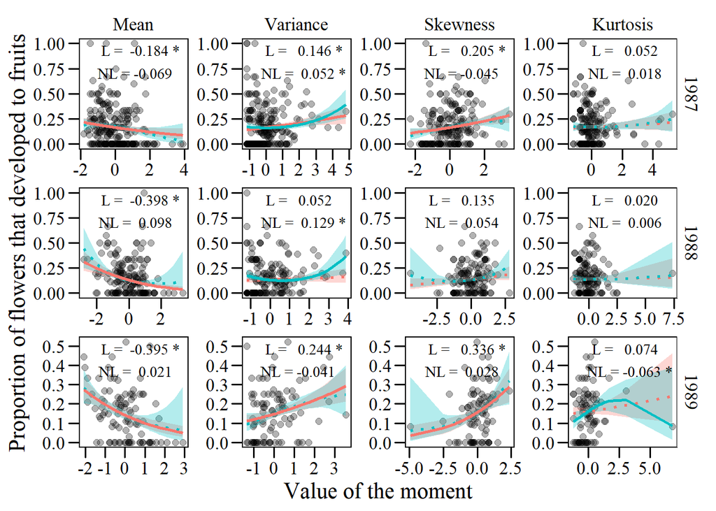

```r
predictor.labs<-c("Mean","Variance","Skewness","Kurtosis")
names(predictor.labs)<-c("avFD_std","var_std","skew_std","kurt_std")
fig2<-ggplot()+
  geom_point(data=data_ids%>%
               select(year,fr_init,avFD_std,var_std,skew_std,kurt_std)%>%
               pivot_longer(cols=avFD_std:kurt_std,
                            names_to="predictor",values_to="value_predictor")%>%
               mutate(predictor=factor(predictor,
                                       levels=c("avFD_std","var_std",
                                                "skew_std","kurt_std"))),
             aes(x=value_predictor,y=fr_init),
             size=2,alpha=0.3)+
  facet_grid2(c("year","predictor"),
              labeller=labeller(predictor=predictor.labs),
              scales = "free", independent = "all")+
  geom_ribbon(data=prediction_fr_init_univar,
              aes(x=x,y=predicted,ymin=conf.low,ymax=conf.high,fill=type),
              alpha=0.3)+
  geom_line(data=prediction_fr_init_univar,
            aes(x=x,y=predicted,linetype=signif,color=type),
            linewidth=1)+
  scale_linetype_manual(values=c("dotted", "solid"))+
  ylab("Proportion of flowers that developed to fruits")+
  xlab("Value of the moment")+
  my_theme()+
  geom_text(data=prediction_fr_init_univar%>%
              select(year,predictor,print,type)%>%
              distinct()%>%
              pivot_wider(names_from=type,values_from=print)%>%
              mutate(print=paste("L = ",linear,"\n","NL =", nonlinear)),
            aes(x=Inf,y=Inf,label=print),
             hjust=1.05, vjust=1.2,family="serif")
fig2
```

```r
ggsave(file="output/figures/fig2.tiff", plot=fig2, width=10, height=7)
```

## Figure 3 (new)

Figure based on predictions of yearly univariate models (selection differentials).

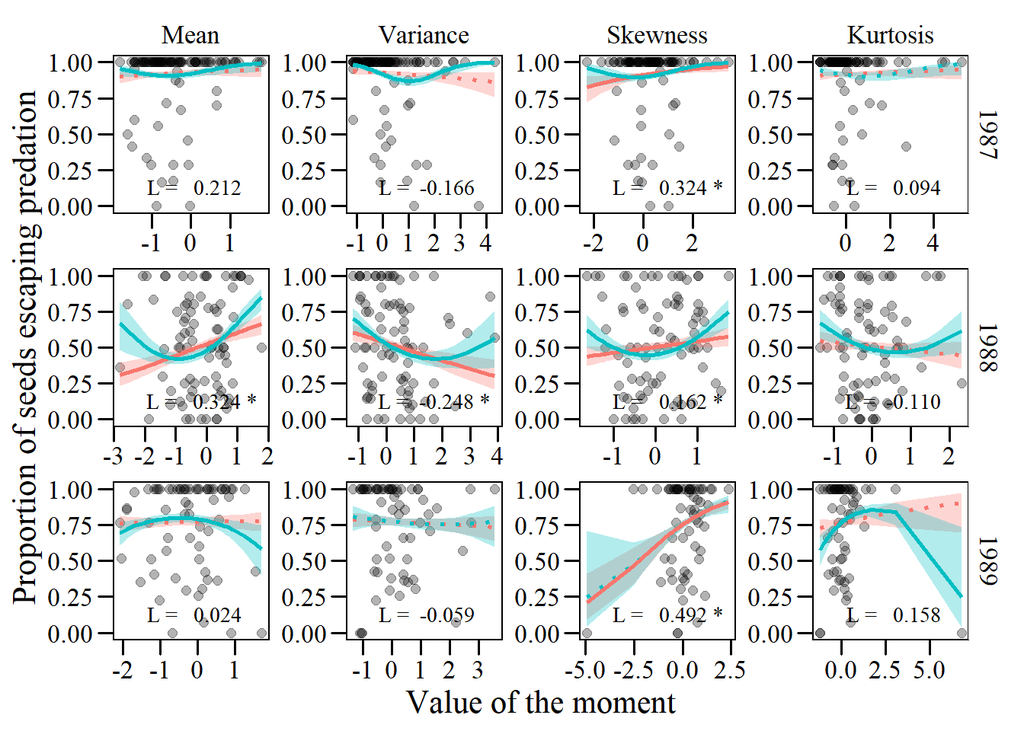

```r
fig3<-ggplot()+
  geom_point(data=data_ids%>%
               select(year,prop_seed_preyed,
                      avFD_std,var_std,skew_std,kurt_std)%>%
               pivot_longer(cols=avFD_std:kurt_std,
                            names_to="predictor",values_to="value_predictor")%>%
               mutate(predictor=factor(predictor,
                                       levels=c("avFD_std","var_std",
                                                "skew_std","kurt_std")))%>%
               filter(!is.na(prop_seed_preyed)),
             aes(x=value_predictor,y=1-prop_seed_preyed),
             size=2,alpha=0.3)+
  facet_grid2(c("year","predictor"),
              labeller=labeller(predictor=predictor.labs),
              scales = "free", independent = "all")+
  geom_ribbon(data=prediction_seeds_escpred_univar,
              aes(x=x,y=predicted,ymin=conf.low,ymax=conf.high,fill=type),
              alpha=0.3)+
  geom_line(data=prediction_seeds_escpred_univar,
            aes(x=x,y=predicted,linetype=signif,color=type),
            linewidth=1)+
  scale_linetype_manual(values=c("dotted", "solid"))+
  ylab("Proportion of seeds escaping predation")+
  xlab("Value of the moment")+
  my_theme()+
  geom_text(data=prediction_seeds_escpred_univar%>%
              select(year,predictor,print,type)%>%
              distinct()%>%
              pivot_wider(names_from=type,values_from=print)%>%
              mutate(print=paste("L = ",linear,"\n","NL =", nonlinear)),
            aes(x=Inf,y=0.25,label=print),
            hjust=1.05, vjust=1.2,family="serif")
fig3
```

```r
ggsave(file="output/figures/fig3.tiff", plot=fig3, width=10, height=7)
```

## Figure 4 (new)

Figure based on predictions of yearly univariate models (selection differentials).

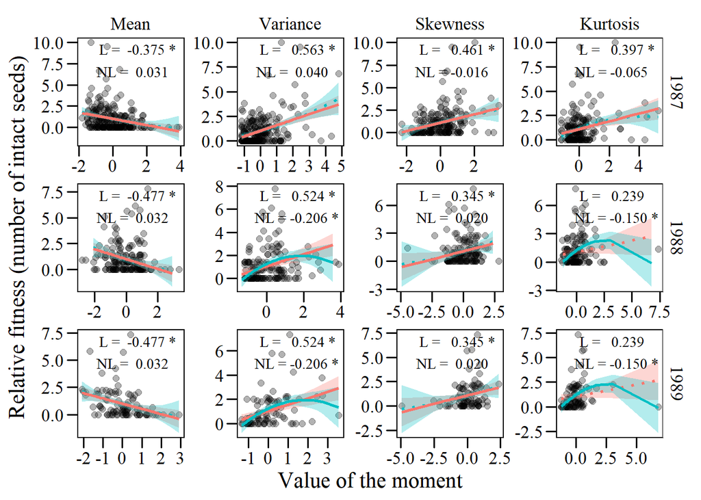

```r
fig4<-ggplot()+
  geom_point(data=data_ids%>%
               select(year,fitness_rel,avFD_std,var_std,skew_std,kurt_std)%>%
               pivot_longer(cols=avFD_std:kurt_std,
                            names_to="predictor",values_to="value_predictor")%>%
               mutate(predictor=factor(predictor,
                                       levels=c("avFD_std","var_std",
                                                "skew_std","kurt_std"))),
             aes(x=value_predictor,y=fitness_rel),
             size=2,alpha=0.3)+
  facet_grid2(c("year","predictor"),
              labeller=labeller(predictor=predictor.labs),
              scales = "free", independent = "all")+
  geom_ribbon(data=prediction_sel_univar,
              aes(x=x,y=predicted,ymin=conf.low,ymax=conf.high,fill=type),
              alpha=0.3)+
  geom_line(data=prediction_sel_univar,
            aes(x=x,y=predicted,linetype=signif,color=type),
            linewidth=1)+
  scale_linetype_manual(values=c("dotted", "solid"))+
  ylab("Relative fitness (number of intact seeds)")+
  xlab("Value of the moment")+
  my_theme()+
  geom_text(data=prediction_sel_univar%>%
              select(year,predictor,print,type)%>%
              distinct()%>%
              pivot_wider(names_from=type,values_from=print)%>%
              mutate(print=paste("L = ",linear,"\n","NL =", nonlinear)),
            aes(x=Inf,y=Inf,label=print),
             hjust=1.05, vjust=1.2,family="serif")
fig4
```

```r
ggsave(file="output/figures/fig4.tiff", plot=fig4, width=10, height=7)
```

## Figure 5

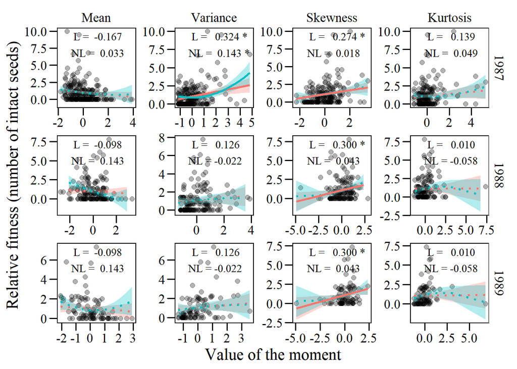

```r
fig5<-ggplot()+
  geom_point(data=data_ids%>%
               select(year,fitness_rel,avFD_std,var_std,skew_std,kurt_std)%>%
               pivot_longer(cols=avFD_std:kurt_std,
                            names_to="predictor",values_to="value_predictor")%>%
               mutate(predictor=factor(predictor,
                                       levels=c("avFD_std","var_std",
                                                "skew_std","kurt_std"))),
             aes(x=value_predictor,y=fitness_rel),
             size=2,alpha=0.3)+
  facet_grid2(c("year","predictor"),
              labeller=labeller(predictor=predictor.labs),
              scales = "free", independent = "all")+
  geom_ribbon(data=prediction_sel_nfl_univar,
              aes(x=x,y=predicted,ymin=conf.low,ymax=conf.high,fill=type),
              alpha=0.3)+
  geom_line(data=prediction_sel_nfl_univar,
            aes(x=x,y=predicted,linetype=signif,color=type),
            linewidth=1)+
  scale_linetype_manual(values=c("dotted", "solid"))+
  ylab("Relative fitness (number of intact seeds)")+
  xlab("Value of the moment")+
  my_theme()+
  geom_text(data=prediction_sel_nfl_univar%>%
              select(year,predictor,print,type)%>%
              distinct()%>%
              pivot_wider(names_from=type,values_from=print)%>%
              mutate(print=paste("L = ",linear,"\n","NL =", nonlinear)),
            aes(x=Inf,y=Inf,label=print),
             hjust=1.05, vjust=1.2,family="serif")
fig5
```

```r
ggsave(file="output/figures/fig5.tiff", plot=fig5, width=10, height=7)
```